# **MINIPROYECTO - DEEP LEARNING - TEAM 12**

## **INTRODUCCIÓN:**

El presente miniproyecto se basa en las características musicales de una canción y si estas influyen o son determinantes respecto del año de publicación o lanzamiento. En resumen, ¿Existe una relación entre las características musicales de una canción y el año en que fue publicada/lanzada? Una respuesta positiva a esta pregunta revelaría una profunda comprensión de la naturaleza de una composición musical y, lo que es más importante, esta comprensión se demostraría matemáticamente.

En este proyecto, se utilizan datos reales para predecir el año en que fue lanzada una canción a partir de sus características del timbre en la grabación. En total, son 90 atributos predictores: los 12 primeros corresponden al timbre promedio y los 78 siguientes a la covarianza. Originalmente, este tipo de datos fue recolectado en un proyecto llamado Million Song Dataset de la Universidad de Columbia (http://millionsongdataset.com/). Los datos a trabajar tienen los mismos predictores pero con canciones no consideradas en la base de datos original.

**INSTRUCCIONES**  
Para el proyecto fue solicitado realizar un **modelamiento predictivo mediante el uso de los modelos de redes neuronales** que se han visto en el curso.

En general, se deben reportar los resultados del modelamiento predictivo siguiendo los pasos que se muestran a continuación:

1. Exploración de los datos para su entendimiento dentro del contexto organizacional.
2. Preparación de los datos para poder utilizarlos como entrada para modelos predictivos.
3. Análisis preliminar de selección de modelos relevantes para responder a la pregunta.
4. Desarrollo y calibración de modelos.
5. Visualización de resultados.

**DATASETS PROPORCIONADOS**

1. sampleSubmission.csv
2. testReg.csv
3. trainReg.csv Disponibles en: https://www.kaggle.com/competitions/music-year-prediction/data

**LEADERBOARD Y OTROS DATOS**  
Enlace de la competencia: https://www.kaggle.com/competitions/music-year-prediction/

**INTEGRANTES DEL EQUIPO 12**

- Christian Beraún Chamorro
- D’sharlie Sánchez Rozo
- William Alexander Morales Valera

```python
from math import sqrt
from sklearn.metrics import mean_squared_error
from sklearn.model_selection import train_test_split
from sklearn.preprocessing import StandardScaler
from tensorflow.keras.callbacks import EarlyStopping
from tensorflow.keras.layers import Dense
from tensorflow.keras.layers import Dense, BatchNormalization
from tensorflow.keras.layers import Dense, BatchNormalization, Dropout
from tensorflow.keras.layers import LSTM, Dense
from tensorflow.keras.models import Sequential
from tensorflow.keras.optimizers import Adam
import matplotlib.pyplot as plt
import numpy as np
import pandas as pd
import seaborn as sns
```

## **PARTE 1: EXPLORACIÓN DE LOS DATOS Y CONTEXTO ORGANIZACIONAL**

```python
# Cargar los datos
train_data = pd.read_csv('trainReg.csv')
test_data = pd.read_csv('testReg.csv')
```

```python
train_data
```

|  | ID | Y | V1 | V2 | V3 | V4 | V5 | V6 | V7 | V8 | ... | V81 | V82 | V83 | V84 | V85 | V86 | V87 | V88 | V89 | V90 |
| --- | --- | --- | --- | --- | --- | --- | --- | --- | --- | --- | --- | --- | --- | --- | --- | --- | --- | --- | --- | --- | --- |
| 0 | 1 | 2013 | 44.81144 | 0.83826 | 0 | 7.91314 | 10.94148 | -0.04547 | -15.16332 | -10.47324 | ... | -8.44873 | -230.30484 | -40.94698 | 48.20025 | -0.28694 | 155.76251 | -56.23579 | 13.62599 | 123.92018 | 10.02845 |
| 1 | 2 | 1998 | 41.99180 | 7.99976 | 0 | 64.26707 | 16.54115 | -9.28737 | -40.73524 | 33.60440 | ... | 18.68972 | -44.06062 | 52.37792 | 81.36093 | -14.81111 | 151.66273 | -120.61213 | 10.57519 | -3.21078 | -1.07438 |
| 2 | 3 | 1998 | 42.19196 | 2.23111 | 0 | 65.07719 | 24.99746 | 1.76100 | 6.66573 | 3.45778 | ... | -3.69878 | -118.95712 | 54.15529 | -23.32168 | -9.65067 | -83.83055 | -141.17594 | 7.33084 | -275.69714 | 2.35522 |
| 3 | 4 | 1998 | 39.28634 | -1.85716 | 0 | 91.04190 | 9.08333 | 0.08502 | -5.59216 | 65.62463 | ... | 20.89044 | -18.53135 | 176.09769 | 351.33669 | 3.44682 | 121.69156 | -270.43989 | 12.51659 | -140.88884 | -0.23476 |
| 4 | 5 | 1998 | 40.36025 | 2.94918 | 0 | 53.83723 | 13.71369 | -8.21964 | -40.21636 | 21.22366 | ... | 19.91979 | 34.59026 | -69.83720 | 102.31946 | 8.08807 | 135.08089 | -153.02327 | 4.09207 | -68.33046 | -6.19159 |
| ... | ... | ... | ... | ... | ... | ... | ... | ... | ... | ... | ... | ... | ... | ... | ... | ... | ... | ... | ... | ... | ... |
| 77774 | 96428 | 2004 | 33.76706 | -3.80678 | 0 | -1.44169 | 23.78801 | 5.01781 | 1.58966 | -25.02281 | ... | -36.84706 | -637.31267 | -174.93600 | 127.32951 | -15.75226 | -144.64697 | 6.53731 | 5.54065 | 193.68594 | 32.75930 |
| 77775 | 96432 | 2004 | 25.77805 | 2.41861 | 0 | 5.96418 | -8.43658 | -1.36182 | 2.51784 | -18.57770 | ... | 27.76376 | -44.59643 | -116.15080 | -34.33917 | 4.86612 | 141.37999 | 282.57252 | 23.32459 | 125.07389 | -19.16268 |
| 77776 | 96433 | 2004 | 24.78656 | 1.36415 | 0 | 34.13329 | 34.32996 | -0.95170 | 75.33572 | -28.59028 | ... | 33.73262 | -206.05602 | 44.10029 | -635.01673 | -16.75481 | 114.74225 | -192.79351 | -4.44202 | 1457.72692 | -50.93615 |
| 77777 | 96434 | 2006 | 39.67698 | 3.65167 | 0 | 34.04925 | -0.68467 | -2.13911 | -5.70096 | -10.57862 | ... | -15.46611 | -117.84462 | 139.93465 | 67.70637 | -24.18488 | -39.54694 | 185.26251 | -1.37534 | 216.14774 | -12.75066 |
| 77778 | 96435 | 2006 | 44.44499 | 8.89481 | 0 | 48.99411 | 15.83343 | 5.00566 | -23.89831 | -21.12626 | ... | -9.07718 | -623.88638 | 186.93061 | -9.41335 | -11.51320 | 137.13883 | -80.15732 | 20.33014 | 106.69048 | 6.68635 |

77779 rows × 92 columns

```python
train_data.describe()
```

|  | ID | Y | V1 | V2 | V3 | V4 | V5 | V6 | V7 | V8 | ... | V81 | V82 | V83 | V84 | V85 | V86 | V87 | V88 | V89 | V90 |
| --- | --- | --- | --- | --- | --- | --- | --- | --- | --- | --- | --- | --- | --- | --- | --- | --- | --- | --- | --- | --- | --- |
| count | 77779.000000 | 77779.000000 | 77779.000000 | 77779.000000 | 77779.0 | 77779.000000 | 77779.000000 | 77779.000000 | 77779.000000 | 77779.000000 | ... | 77779.000000 | 77779.000000 | 77779.000000 | 77779.000000 | 77779.000000 | 77779.000000 | 77779.000000 | 77779.000000 | 77779.000000 | 77779.000000 |
| mean | 48244.238342 | 2002.308129 | 43.425185 | -0.136720 | 0.0 | 3.755313 | -2.339768 | -1.643095 | -6.814997 | -9.587264 | ... | 15.717215 | -71.733008 | 41.679287 | 37.816353 | 0.328213 | 17.575097 | -25.628857 | 4.463484 | 18.664885 | 1.240194 |
| std | 27846.283673 | 10.811038 | 6.128869 | 4.370466 | 0.0 | 17.609183 | 14.483975 | 7.898574 | 22.980515 | 12.911914 | ... | 32.211995 | 176.893351 | 123.523393 | 95.335357 | 16.272689 | 115.243644 | 173.310304 | 13.526414 | 186.690183 | 22.379654 |
| min | 1.000000 | 1926.000000 | 4.836880 | -69.680870 | 0.0 | -165.221610 | -121.475340 | -72.503850 | -152.407550 | -70.693420 | ... | -424.517570 | -4402.376440 | -1733.722110 | -1848.702260 | -238.386730 | -3168.924570 | -4319.992320 | -236.039260 | -7458.378150 | -281.150600 |
| 25% | 24079.500000 | 1998.000000 | 40.060315 | -2.612435 | 0.0 | -7.016240 | -10.685075 | -6.300690 | -21.265305 | -18.583065 | ... | -1.968265 | -136.511095 | -21.467975 | -4.604295 | -6.702370 | -31.569390 | -100.668480 | -2.569360 | -60.121980 | -8.900120 |
| 50% | 48357.000000 | 2006.000000 | 44.323850 | -0.063000 | 0.0 | 2.022100 | -2.054560 | -1.586240 | -6.307610 | -11.238330 | ... | 9.079980 | -51.322570 | 28.217560 | 33.417370 | 0.788980 | 15.237360 | -21.581640 | 3.136900 | 5.941490 | -0.095340 |
| 75% | 72340.500000 | 2010.000000 | 47.900080 | 2.465950 | 0.0 | 12.776450 | 6.423900 | 3.077055 | 7.617995 | -2.329330 | ... | 26.211700 | 13.999870 | 89.190475 | 77.216175 | 8.354270 | 67.361475 | 51.333150 | 10.002145 | 84.389125 | 9.520700 |
| max | 96435.000000 | 2014.000000 | 60.034010 | 23.815260 | 0.0 | 274.658580 | 160.815220 | 68.447960 | 262.068870 | 112.971410 | ... | 840.973380 | 2147.942140 | 3210.701700 | 1482.642140 | 199.121500 | 2144.103910 | 2833.608950 | 275.353660 | 5289.111380 | 600.766240 |

8 rows × 92 columns

Al respecto, procedemos a analizar las Variables Predictoras y la Variable de interés (Año de Lanzamiento : Y). Dado que V3 tiene valores "0", se descarta para los siguientes análisis. Asimismo, "ID" es el orden del registro, también se descarta.

```python
X = train_data.drop(columns=['ID','V3',"Y"])
Y = train_data[['Y']]
```

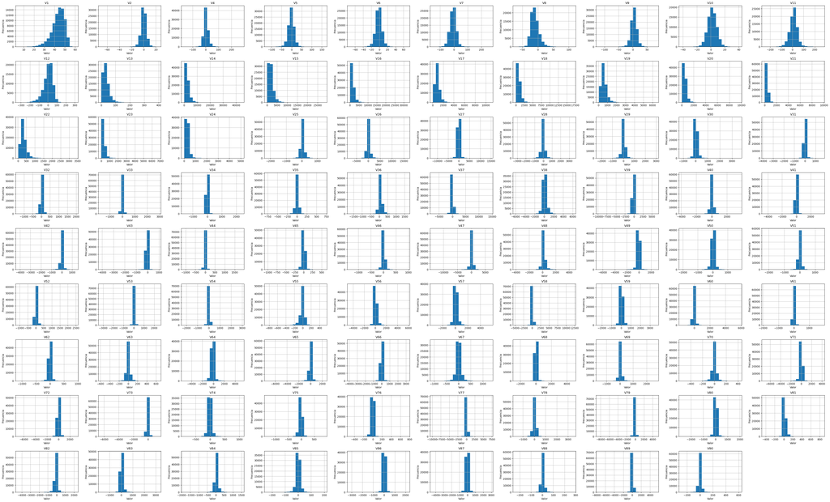

```python
num_columns = len(X.columns)
num_rows = (num_columns + 10) // 5
plt.figure(figsize=(15 * 3, num_rows * 3))
for i, column in enumerate(X.columns):
    ax = plt.subplot(num_rows, 10, i + 1)
    X[column].hist(bins=20, ax=ax)
    ax.set_title(column)
    ax.set_xlabel('Valor')
    ax.set_ylabel('Frecuencia')
plt.tight_layout()
plt.show()
```

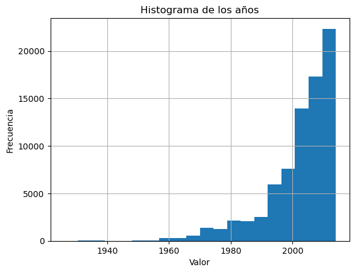

```python
plt.figure(figsize=(8, 6))
Y.hist(bins=20)
plt.title('Histograma de los años')
plt.xlabel('Valor')
plt.ylabel('Frecuencia')
plt.show()
```

Como podemos observar, existe una distribución mayor para los años más cercanos a la fecha; ello podría deberse a que los datos se encuentran disponibles en diversas plataformas streaming de música, tal como lo precisa en la página web de los datasets:

- SecondHandSongs dataset -> cover songs
- musiXmatch dataset -> lyrics
- Last.fm dataset -> song-level tags and similarity
- Taste Profile subset -> user data
- thisismyjam-to-MSD mapping -> more user data
- tagtraum genre annotations -> genre labels
- Top MAGD dataset -> more genre labels

Ahora bien, tengamos en cuenta este dato importante "los 12 primeros (V1 A V12) corresponden al timbre promedio y los 78 siguientes a la covarianza (V13 a V90)". Analizaremos la correlación que existe entre las variables predictoras con la variable de interés:

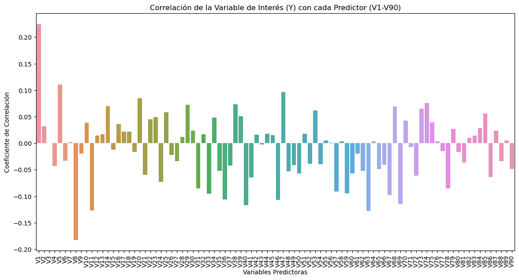

```python
predictors = [f'V{i}' for i in range(1, 91)]
data_subset = train_data[predictors + ['Y']]
correlation_matrix = data_subset.corr()
target_correlation = correlation_matrix['Y'].drop('Y')
plt.figure(figsize=(14, 7))
sns.barplot(x=target_correlation.index, y=target_correlation.values)
plt.xticks(rotation=90)
plt.title('Correlación de la Variable de Interés (Y) con cada Predictor (V1-V90)')
plt.xlabel('Variables Predictoras')
plt.ylabel('Coeficiente de Correlación')

plt.show()
```

## **PARTE 2: PREPARACIÓN DE LOS DATOS PARA MODELOS PREDICTIVOS**

Como pudimos observar, las variables predictoras van de V1 a V90, pero se debe eliminar V3 y ID, siendo que no agregan valor al modelo, por ser valores vacíos o el índice de los registros.

```python
X = train_data.drop(columns=['ID','V3',"Y"])
Y = train_data[['Y']]
```

```python
X
```

|  | V1 | V2 | V4 | V5 | V6 | V7 | V8 | V9 | V10 | V11 | ... | V81 | V82 | V83 | V84 | V85 | V86 | V87 | V88 | V89 | V90 |
| --- | --- | --- | --- | --- | --- | --- | --- | --- | --- | --- | --- | --- | --- | --- | --- | --- | --- | --- | --- | --- | --- |
| 0 | 44.81144 | 0.83826 | 7.91314 | 10.94148 | -0.04547 | -15.16332 | -10.47324 | 14.17212 | 10.57382 | -11.21128 | ... | -8.44873 | -230.30484 | -40.94698 | 48.20025 | -0.28694 | 155.76251 | -56.23579 | 13.62599 | 123.92018 | 10.02845 |
| 1 | 41.99180 | 7.99976 | 64.26707 | 16.54115 | -9.28737 | -40.73524 | 33.60440 | 9.18802 | -6.79144 | 44.21327 | ... | 18.68972 | -44.06062 | 52.37792 | 81.36093 | -14.81111 | 151.66273 | -120.61213 | 10.57519 | -3.21078 | -1.07438 |
| 2 | 42.19196 | 2.23111 | 65.07719 | 24.99746 | 1.76100 | 6.66573 | 3.45778 | -24.42779 | -18.45069 | 233.16766 | ... | -3.69878 | -118.95712 | 54.15529 | -23.32168 | -9.65067 | -83.83055 | -141.17594 | 7.33084 | -275.69714 | 2.35522 |
| 3 | 39.28634 | -1.85716 | 91.04190 | 9.08333 | 0.08502 | -5.59216 | 65.62463 | 8.33105 | 11.70269 | 79.90772 | ... | 20.89044 | -18.53135 | 176.09769 | 351.33669 | 3.44682 | 121.69156 | -270.43989 | 12.51659 | -140.88884 | -0.23476 |
| 4 | 40.36025 | 2.94918 | 53.83723 | 13.71369 | -8.21964 | -40.21636 | 21.22366 | 17.16742 | 0.14463 | 72.23955 | ... | 19.91979 | 34.59026 | -69.83720 | 102.31946 | 8.08807 | 135.08089 | -153.02327 | 4.09207 | -68.33046 | -6.19159 |
| ... | ... | ... | ... | ... | ... | ... | ... | ... | ... | ... | ... | ... | ... | ... | ... | ... | ... | ... | ... | ... | ... |
| 77774 | 33.76706 | -3.80678 | -1.44169 | 23.78801 | 5.01781 | 1.58966 | -25.02281 | 25.90399 | 19.87408 | -21.41492 | ... | -36.84706 | -637.31267 | -174.93600 | 127.32951 | -15.75226 | -144.64697 | 6.53731 | 5.54065 | 193.68594 | 32.75930 |
| 77775 | 25.77805 | 2.41861 | 5.96418 | -8.43658 | -1.36182 | 2.51784 | -18.57770 | -25.69885 | 9.97971 | -100.96885 | ... | 27.76376 | -44.59643 | -116.15080 | -34.33917 | 4.86612 | 141.37999 | 282.57252 | 23.32459 | 125.07389 | -19.16268 |
| 77776 | 24.78656 | 1.36415 | 34.13329 | 34.32996 | -0.95170 | 75.33572 | -28.59028 | -31.86076 | -4.06444 | -53.17960 | ... | 33.73262 | -206.05602 | 44.10029 | -635.01673 | -16.75481 | 114.74225 | -192.79351 | -4.44202 | 1457.72692 | -50.93615 |
| 77777 | 39.67698 | 3.65167 | 34.04925 | -0.68467 | -2.13911 | -5.70096 | -10.57862 | -1.30048 | 9.85726 | 7.33263 | ... | -15.46611 | -117.84462 | 139.93465 | 67.70637 | -24.18488 | -39.54694 | 185.26251 | -1.37534 | 216.14774 | -12.75066 |
| 77778 | 44.44499 | 8.89481 | 48.99411 | 15.83343 | 5.00566 | -23.89831 | -21.12626 | -12.13135 | 12.76931 | -44.42589 | ... | -9.07718 | -623.88638 | 186.93061 | -9.41335 | -11.51320 | 137.13883 | -80.15732 | 20.33014 | 106.69048 | 6.68635 |

77779 rows × 89 columns

```python
Y
```

|  | Y |
| --- | --- |
| 0 | 2013 |
| 1 | 1998 |
| 2 | 1998 |
| 3 | 1998 |
| 4 | 1998 |
| ... | ... |
| 77774 | 2004 |
| 77775 | 2004 |
| 77776 | 2004 |
| 77777 | 2006 |
| 77778 | 2006 |

77779 rows × 1 columns

```python
missing_values = X.isnull().sum()
print("Número de valores nulos por columna:")
print(missing_values)
```

```
Número de valores nulos por columna:
V1     0
V2     0
V4     0
V5     0
V6     0
      ..
V86    0
V87    0
V88    0
V89    0
V90    0
Length: 89, dtype: int64
```

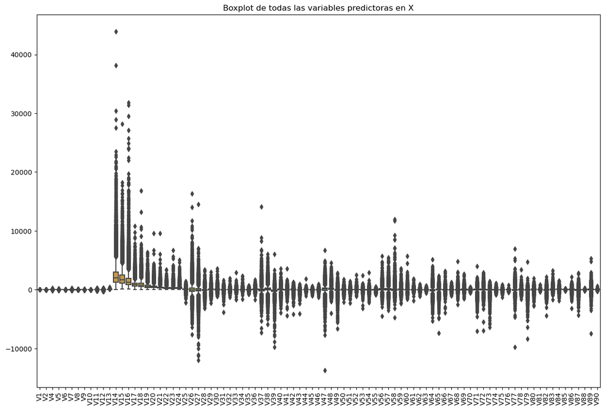

```python
plt.figure(figsize=(15, 10))
sns.boxplot(data=X)
plt.xticks(rotation=90)
plt.title('Boxplot de todas las variables predictoras en X')
plt.show()
```

Ahora bien, si observamos las variables V14 en adelante, podemos ver que hay mucha variabilidad. Mientras que de V1 a V12, no hay mucha.

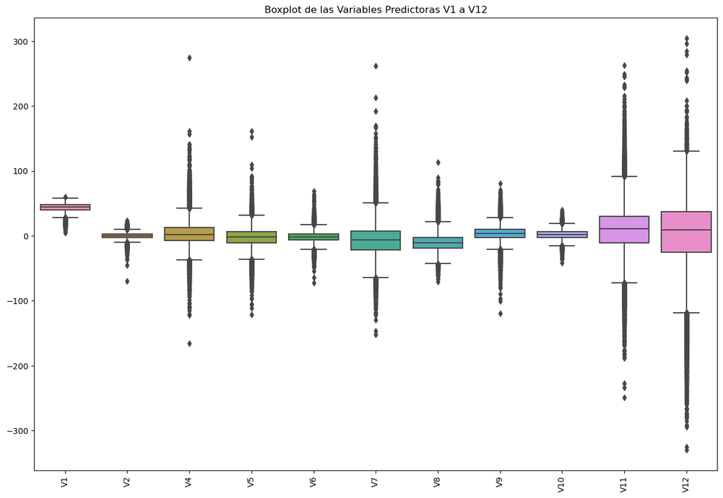

```python
X_subset = X[['V1', 'V2', 'V4', 'V5', 'V6', 'V7', 'V8', 'V9', 'V10', 'V11', 'V12']]

plt.figure(figsize=(15, 10))
sns.boxplot(data=X_subset)
plt.xticks(rotation=90)
plt.title('Boxplot de las Variables Predictoras V1 a V12')
plt.show()
```

Considerando todo lo anterior, se vió por conveniente crear variables que capturen los datos de V1 a V12 y de V13 a V90, usando métricas como suma, promedio, mediana, producto, entre otras. Conforme se detalla a continuación:

```python
train_data = train_data.drop(columns=['ID','V3'])
test_data = test_data.drop(columns=['ID'])

def create_features(data):
    timbre_cols = [f"V{i}" for i in range(1, 13) if i != 3]
    if all(col in data.columns for col in timbre_cols):
        data['mean_timbre'] = data[timbre_cols].mean(axis=1)
        data['median_timbre'] = data[timbre_cols].median(axis=1)
        data['std_timbre'] = data[timbre_cols].std(axis=1)
        data['sum_timbre'] = data[timbre_cols].sum(axis=1)
        data['max_timbre'] = data[timbre_cols].max(axis=1)
        data['min_timbre'] = data[timbre_cols].min(axis=1)
        data['prod_timbre'] = data[timbre_cols].prod(axis=1)
    else:
        print("Algunas columnas necesarias (V1, V2, V4 a V12) no existen en el DataFrame")
    if all(f"V{i}" in data.columns for i in range(13, 91)):
        covariance_cols = [f"V{i}" for i in range(13, 91)]
        data['mean_covariance'] = data[covariance_cols].mean(axis=1)
        data['median_covariance'] = data[covariance_cols].median(axis=1)
        data['std_covariance'] = data[covariance_cols].std(axis=1)
        data['sum_covariance'] = data[covariance_cols].sum(axis=1)
        data['max_covariance'] = data[covariance_cols].max(axis=1)
        data['min_covariance'] = data[covariance_cols].min(axis=1)
        data['prod_covariance'] = np.exp(data[covariance_cols].apply(np.log).sum(axis=1))
    else:
        print("Algunas columnas de V13 a V90 no existen en el DataFrame")

    return data
train_data = create_features(train_data)
test_data = create_features(test_data)
```

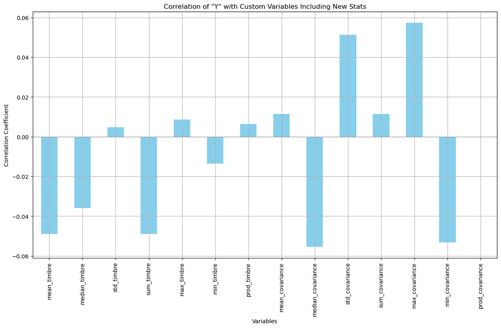

```python
import matplotlib.pyplot as plt
def plot_corr(data):
    correlation_matrix = data.corr()
    custom_vars = [
        'mean_timbre', 'median_timbre', 'std_timbre', 'sum_timbre', 'max_timbre', 'min_timbre', 'prod_timbre',
        'mean_covariance', 'median_covariance', 'std_covariance', 'sum_covariance', 'max_covariance', 'min_covariance', 'prod_covariance'
    ]
    correlation_with_y_custom = correlation_matrix['Y'][custom_vars]
    plt.figure(figsize=(15, 8))
    correlation_with_y_custom.plot(kind='bar', color='skyblue')
    plt.title('Correlation of "Y" with Custom Variables Including New Stats')
    plt.xlabel('Variables')
    plt.ylabel('Correlation Coefficient')
    plt.grid(True)
    plt.axhline(0, color='gray', linewidth=0.5)
    plt.show()
plot_corr(train_data)
```

Si bien se han creado estas características, luego de haber analizado los datos se optó por considerar todas las variables V1 a V90 + variables creadas y sobre estas determinar aquellas en un umbral de correlación con "Y" y evitar la multiconilealidad.

#### Variables V1 a V90 + variables creadas y sobre estas determinar aquellas en un umbral de correlación con "Y"

```python
correlation_matrix = train_data.corr()
target_correlation = correlation_matrix['Y'].sort_values(ascending=False)
correlation_matrix = train_data.corr()
target_correlation = correlation_matrix['Y'].sort_values(ascending=False)
important_features = target_correlation[abs(target_correlation) > 0.015]
high_corr_matrix = correlation_matrix.where(np.triu(np.ones(correlation_matrix.shape), k=1).astype(bool))
to_drop = [column for column in high_corr_matrix.columns if any(high_corr_matrix[column] > 0.8)]
selected_features = important_features.index.difference(to_drop)
selected_features
selected_features2 = selected_features.difference(['Y'])
selected_features2
train_data = train_data[selected_features]
test_data = test_data[selected_features2]
train_data.drop(columns=['ID'], inplace=True, errors='ignore')
test_data.drop(columns=['ID'], inplace=True, errors='ignore')
```

```python
X_train, X_val, y_train, y_val = train_test_split(train_data.drop(columns=['Y']), train_data['Y'], test_size=0.20, random_state=42)
```

```python
scaler = StandardScaler()
X_train_scaled = scaler.fit_transform(X_train)
X_val_scaled = scaler.transform(X_val)
```

## **PARTE 3: ANÁLISIS PRELIMINAR DE SELECCIÓN DE MODELOS RELEVANTES**

### **Modelo 1: Una sola neurona **

```python
model1 = Sequential([
    Dense(1, input_dim=X_train_scaled.shape[1], activation='linear')
])
optimizer = Adam(learning_rate=0.2)
model1.compile(optimizer=optimizer, loss='mean_squared_error')
early_stopping = EarlyStopping(monitor='val_loss', patience=5, verbose=1, restore_best_weights=True)
model1.fit(X_train_scaled, y_train, epochs=10, batch_size=32, validation_data=(X_val_scaled, y_val), callbacks=[early_stopping])
y_pred = model1.predict(X_val_scaled)
if np.isnan(y_pred).any():
    raise ValueError("Las predicciones contienen NaN")
rmse = sqrt(mean_squared_error(y_val, y_pred))
print(f'RMSE: {rmse}')
```

```
1945/1945 ━━━━━━━━━━━━━━━━━━━━ 2s 640us/step - loss: 3646274.7500 - val_loss: 2653277.7500
1945/1945 ━━━━━━━━━━━━━━━━━━━━ 1s 602us/step - loss: 2378656.0000 - val_loss: 1631743.1250
1945/1945 ━━━━━━━━━━━━━━━━━━━━ 1s 597us/step - loss: 1429066.5000 - val_loss: 888608.5000
1945/1945 ━━━━━━━━━━━━━━━━━━━━ 1s 621us/step - loss: 748726.3125 - val_loss: 392420.5625
1945/1945 ━━━━━━━━━━━━━━━━━━━━ 1s 616us/step - loss: 309997.9375 - val_loss: 116953.0547
1945/1945 ━━━━━━━━━━━━━━━━━━━━ 1s 602us/step - loss: 81577.9453 - val_loss: 14191.3877
1945/1945 ━━━━━━━━━━━━━━━━━━━━ 1s 611us/step - loss: 7712.5869 - val_loss: 218.8185
1945/1945 ━━━━━━━━━━━━━━━━━━━━ 1s 613us/step - loss: 135.9781 - val_loss: 102.4660
1945/1945 ━━━━━━━━━━━━━━━━━━━━ 1s 599us/step - loss: 95.4779 - val_loss: 97.0490
1945/1945 ━━━━━━━━━━━━━━━━━━━━ 1s 605us/step - loss: 102.8793 - val_loss: 108.8134
Restoring model weights from the end of the best epoch: 9.
487/487 ━━━━━━━━━━━━━━━━━━━━ 0s 491us/step
RMSE: 9.851345353532812
```

### **Modelo 2: Múltiples Capas **

```python
model2 = Sequential([
    Dense(200, input_dim=X_train_scaled.shape[1], activation='relu'),
    Dense(50, activation='relu'),
    Dense(1, activation='linear')
])

optimizer = Adam(learning_rate=0.001)
model2.compile(optimizer=optimizer, loss='mean_squared_error')

early_stopping = EarlyStopping(monitor='val_loss', patience=5, verbose=1, restore_best_weights=True)

model2.fit(X_train_scaled, y_train, epochs=10, batch_size=32, validation_data=(X_val_scaled, y_val), callbacks=[early_stopping])

y_pred = model2.predict(X_val_scaled)
if np.isnan(y_pred).any():
    raise ValueError("Las predicciones contienen NaN")

rmse = sqrt(mean_squared_error(y_val, y_pred))
print(f'RMSE: {rmse}')
```

```
2066/2066 ━━━━━━━━━━━━━━━━━━━━ 2s 754us/step - loss: 1203407.5000 - val_loss: 51299.4648
2066/2066 ━━━━━━━━━━━━━━━━━━━━ 1s 716us/step - loss: 37058.0742 - val_loss: 11845.1768
2066/2066 ━━━━━━━━━━━━━━━━━━━━ 2s 719us/step - loss: 7206.3481 - val_loss: 1883.6832
2066/2066 ━━━━━━━━━━━━━━━━━━━━ 2s 722us/step - loss: 1215.3699 - val_loss: 666.9042
2066/2066 ━━━━━━━━━━━━━━━━━━━━ 2s 737us/step - loss: 395.8275 - val_loss: 492.5071
2066/2066 ━━━━━━━━━━━━━━━━━━━━ 2s 725us/step - loss: 283.0558 - val_loss: 659.5401
2066/2066 ━━━━━━━━━━━━━━━━━━━━ 1s 713us/step - loss: 341.4096 - val_loss: 618.0717
2066/2066 ━━━━━━━━━━━━━━━━━━━━ 2s 727us/step - loss: 418.1860 - val_loss: 289.3042
2066/2066 ━━━━━━━━━━━━━━━━━━━━ 2s 722us/step - loss: 258.7532 - val_loss: 192.1150
2066/2066 ━━━━━━━━━━━━━━━━━━━━ 2s 721us/step - loss: 308.6641 - val_loss: 233.8360
Restoring model weights from the end of the best epoch: 9.
365/365 ━━━━━━━━━━━━━━━━━━━━ 0s 606us/step
RMSE: 13.86055419151385
```

## **PARTE 4: DESARROLLO Y CALIBRACIÓN DE MODELOS**

### **Calibración del MODELO 1**

```
Entrenando modelo con learning rate: 0.05
365/365 ━━━━━━━━━━━━━━━━━━━━ 0s 491us/step
Entrenando modelo con learning rate: 0.1
```

```
365/365 ━━━━━━━━━━━━━━━━━━━━ 0s 528us/step
Entrenando modelo con learning rate: 0.2
```

```
365/365 ━━━━━━━━━━━━━━━━━━━━ 0s 485us/step
Entrenando modelo con learning rate: 0.3
```

```
365/365 ━━━━━━━━━━━━━━━━━━━━ 0s 502us/step
Entrenando modelo con learning rate: 0.4
```

```
365/365 ━━━━━━━━━━━━━━━━━━━━ 0s 489us/step
```

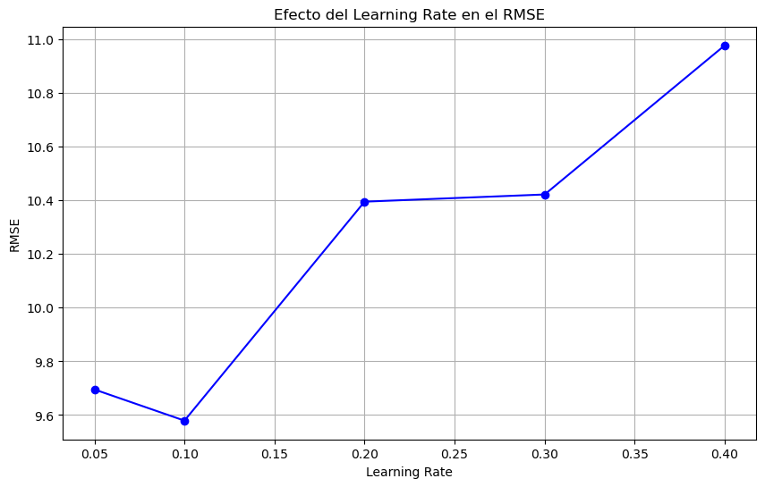

```python
learning_rates = [0.05, 0.1, 0.2, 0.3, 0.4]
rmse_results = []
for lr in learning_rates:
    print(f"Entrenando modelo con learning rate: {lr}")
    model1 = Sequential([
        Dense(1, input_dim=X_train_scaled.shape[1], activation='linear')
    ])
    model1.compile(optimizer=Adam(learning_rate=lr), loss='mean_squared_error')
    model1.fit(X_train_scaled, y_train, epochs=50, batch_size=32, validation_data=(X_val_scaled, y_val), verbose=0)
    y_pred = model1.predict(X_val_scaled)
    rmse = sqrt(mean_squared_error(y_val, y_pred))
    rmse_results.append(rmse)
plt.figure(figsize=(10, 6))
plt.plot(learning_rates, rmse_results, marker='o', linestyle='-', color='b')
plt.title('Efecto del Learning Rate en el RMSE')
plt.xlabel('Learning Rate')
plt.ylabel('RMSE')
plt.grid(True)
plt.show()
```

```python
# Modelo 1: Simplificado con una sola neurona
model1 = Sequential([
    Dense(1, input_dim=X_train_scaled.shape[1], activation='linear')  # Una sola salida para regresión
])

optimizer = Adam(learning_rate=0.1)
model1.compile(optimizer=optimizer, loss='mean_squared_error')

early_stopping = EarlyStopping(monitor='val_loss', patience=5, verbose=0, restore_best_weights=True)

model1.fit(X_train_scaled, y_train, epochs=30, batch_size=32, validation_data=(X_val_scaled, y_val), callbacks=[early_stopping])

y_pred = model.predict(X_val_scaled)
if np.isnan(y_pred).any():
    raise ValueError("Las predicciones contienen NaN")

rmse = sqrt(mean_squared_error(y_val, y_pred))
print(f'RMSE: {rmse}')
```

```
2066/2066 ━━━━━━━━━━━━━━━━━━━━ 1s 594us/step - loss: 3810542.0000 - val_loss: 3240118.2500
2066/2066 ━━━━━━━━━━━━━━━━━━━━ 1s 550us/step - loss: 3066334.0000 - val_loss: 2568705.5000
2066/2066 ━━━━━━━━━━━━━━━━━━━━ 1s 549us/step - loss: 2417538.2500 - val_loss: 1984019.5000
2066/2066 ━━━━━━━━━━━━━━━━━━━━ 1s 551us/step - loss: 1851843.3750 - val_loss: 1477541.6250
2066/2066 ━━━━━━━━━━━━━━━━━━━━ 1s 559us/step - loss: 1366375.1250 - val_loss: 1051049.1250
2066/2066 ━━━━━━━━━━━━━━━━━━━━ 1s 550us/step - loss: 959021.3750 - val_loss: 702185.1250
2066/2066 ━━━━━━━━━━━━━━━━━━━━ 1s 560us/step - loss: 628711.5000 - val_loss: 428356.0000
2066/2066 ━━━━━━━━━━━━━━━━━━━━ 1s 552us/step - loss: 373333.7812 - val_loss: 227648.3594
2066/2066 ━━━━━━━━━━━━━━━━━━━━ 1s 555us/step - loss: 190133.9844 - val_loss: 95701.8125
2066/2066 ━━━━━━━━━━━━━━━━━━━━ 1s 547us/step - loss: 74374.0547 - val_loss: 25593.1875
2066/2066 ━━━━━━━━━━━━━━━━━━━━ 1s 560us/step - loss: 17180.5293 - val_loss: 2298.6736
2066/2066 ━━━━━━━━━━━━━━━━━━━━ 1s 550us/step - loss: 1184.9623 - val_loss: 99.2974
2066/2066 ━━━━━━━━━━━━━━━━━━━━ 1s 554us/step - loss: 93.9492 - val_loss: 93.1131
2066/2066 ━━━━━━━━━━━━━━━━━━━━ 1s 549us/step - loss: 96.4193 - val_loss: 91.8708
2066/2066 ━━━━━━━━━━━━━━━━━━━━ 1s 581us/step - loss: 97.6740 - val_loss: 94.8795
2066/2066 ━━━━━━━━━━━━━━━━━━━━ 1s 553us/step - loss: 99.1070 - val_loss: 93.1414
2066/2066 ━━━━━━━━━━━━━━━━━━━━ 1s 560us/step - loss: 101.6134 - val_loss: 92.9645
2066/2066 ━━━━━━━━━━━━━━━━━━━━ 1s 551us/step - loss: 98.5155 - val_loss: 101.7577
2066/2066 ━━━━━━━━━━━━━━━━━━━━ 1s 557us/step - loss: 100.3103 - val_loss: 93.5323
365/365 ━━━━━━━━━━━━━━━━━━━━ 0s 486us/step
RMSE: 9.589057977166199
```

### **Calibración del MODELO 2**

```
Entrenando modelo con learning rate: 0.0005
```

```
Restoring model weights from the end of the best epoch: 10.
365/365 ━━━━━━━━━━━━━━━━━━━━ 0s 591us/step
RMSE para learning rate 0.0005: 14.380555208303235
Entrenando modelo con learning rate: 0.0007
```

```
Restoring model weights from the end of the best epoch: 9.
365/365 ━━━━━━━━━━━━━━━━━━━━ 0s 575us/step
RMSE para learning rate 0.0007: 13.210664354058999
Entrenando modelo con learning rate: 0.001
```

```
Restoring model weights from the end of the best epoch: 9.
365/365 ━━━━━━━━━━━━━━━━━━━━ 0s 578us/step
RMSE para learning rate 0.001: 13.091129184884839
Entrenando modelo con learning rate: 0.0015
```

```
Restoring model weights from the end of the best epoch: 10.
365/365 ━━━━━━━━━━━━━━━━━━━━ 0s 580us/step
RMSE para learning rate 0.0015: 14.461828010935946
Entrenando modelo con learning rate: 0.002
```

```
Restoring model weights from the end of the best epoch: 9.
365/365 ━━━━━━━━━━━━━━━━━━━━ 0s 568us/step
RMSE para learning rate 0.002: 14.258870009321425
```

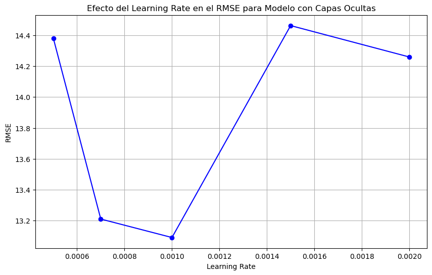

```python
learning_rates = [0.0005, 0.0007, 0.001,0.0015,0.0020]
rmse_results = []

for lr in learning_rates:
    print(f"Entrenando modelo con learning rate: {lr}")
    # Definir el modelo
    model2 = Sequential([
        Dense(200, input_dim=X_train_scaled.shape[1], activation='relu'),  # Capa oculta con 200 neuronas
        Dense(50, activation='relu'),  # Segunda capa oculta con 50 neuronas
        Dense(1, activation='linear')  # Capa de salida para regresión
    ])

    optimizer = Adam(learning_rate=lr)
    model2.compile(optimizer=optimizer, loss='mean_squared_error')

    early_stopping = EarlyStopping(monitor='val_loss', patience=5, verbose=1, restore_best_weights=True)

    model2.fit(X_train_scaled, y_train, epochs=10, batch_size=32, validation_data=(X_val_scaled, y_val), callbacks=[early_stopping], verbose=0)

    y_pred = model2.predict(X_val_scaled)
    rmse = sqrt(mean_squared_error(y_val, y_pred))
    rmse_results.append(rmse)
    print(f"RMSE para learning rate {lr}: {rmse}")

plt.figure(figsize=(10, 6))
plt.plot(learning_rates, rmse_results, marker='o', linestyle='-', color='b')
plt.title('Efecto del Learning Rate en el RMSE para Modelo con Capas Ocultas')
plt.xlabel('Learning Rate')
plt.ylabel('RMSE')
plt.grid(True)
plt.show()
```

Aquí podemos apreciar que el mejor learning rate es el de 0.0010. Ahora se buscó los parámetros óptimos.

```python
num_layers_options = [4,5,6,7]  # Número de capas ocultas a probar
neurons_options = [80]  # Número de neuronas por capa a probar
learning_rate = 0.001  # Puedes ajustar esto según lo que descubras sobre el learning rate
results = []

# Bucle de prueba
for num_layers in num_layers_options:
    for neurons in neurons_options:
        print(f"Probando modelo con {num_layers} capas y {neurons} neuronas por capa")
        model = Sequential()
        model.add(Dense(neurons, input_dim=X_train_scaled.shape[1], activation='relu'))
        for _ in range(1, num_layers):
            model.add(Dense(neurons, activation='relu'))
        model.add(Dense(1, activation='linear'))

        optimizer = Adam(learning_rate=learning_rate)
        model.compile(optimizer=optimizer, loss='mean_squared_error')
        early_stopping = EarlyStopping(monitor='val_loss', patience=5, verbose=1, restore_best_weights=True)
        model.fit(X_train_scaled, y_train, epochs=50, batch_size=32, validation_data=(X_val_scaled, y_val), callbacks=[early_stopping], verbose=1)

        y_pred = model.predict(X_val_scaled)
        rmse = sqrt(mean_squared_error(y_val, y_pred))
        results.append((num_layers, neurons, rmse))
        print(f"RMSE: {rmse}")
best_result = min(results, key=lambda x: x[2])  # Encuentra el resultado con el menor RMSE
print(f"Mejor configuración: {best_result[0]} capas, {best_result[1]} neuronas por capa, RMSE: {best_result[2]}")
```

```
Probando modelo con 4 capas y 80 neuronas por capa
```

```
2066/2066 ━━━━━━━━━━━━━━━━━━━━ 3s 841us/step - loss: 623335.7500 - val_loss: 16345.0645
2066/2066 ━━━━━━━━━━━━━━━━━━━━ 2s 808us/step - loss: 9658.0645 - val_loss: 1906.3290
2066/2066 ━━━━━━━━━━━━━━━━━━━━ 2s 801us/step - loss: 1263.1199 - val_loss: 1613.7130
2066/2066 ━━━━━━━━━━━━━━━━━━━━ 2s 811us/step - loss: 566.8799 - val_loss: 622.2256
2066/2066 ━━━━━━━━━━━━━━━━━━━━ 2s 814us/step - loss: 493.1807 - val_loss: 234.8601
2066/2066 ━━━━━━━━━━━━━━━━━━━━ 3s 802us/step - loss: 360.9139 - val_loss: 548.6903
2066/2066 ━━━━━━━━━━━━━━━━━━━━ 2s 799us/step - loss: 244.8782 - val_loss: 295.9596
2066/2066 ━━━━━━━━━━━━━━━━━━━━ 2s 806us/step - loss: 294.7706 - val_loss: 561.5548
2066/2066 ━━━━━━━━━━━━━━━━━━━━ 2s 801us/step - loss: 268.4504 - val_loss: 391.1486
2066/2066 ━━━━━━━━━━━━━━━━━━━━ 2s 802us/step - loss: 218.4442 - val_loss: 804.0892
Epoch 10: early stopping
Restoring model weights from the end of the best epoch: 5.
365/365 ━━━━━━━━━━━━━━━━━━━━ 0s 650us/step
RMSE: 15.32514447838807
Probando modelo con 5 capas y 80 neuronas por capa
```

```
2066/2066 ━━━━━━━━━━━━━━━━━━━━ 3s 890us/step - loss: 548574.0625 - val_loss: 8063.6172
2066/2066 ━━━━━━━━━━━━━━━━━━━━ 2s 846us/step - loss: 4214.5610 - val_loss: 477.4515
2066/2066 ━━━━━━━━━━━━━━━━━━━━ 2s 849us/step - loss: 365.3521 - val_loss: 162.4477
2066/2066 ━━━━━━━━━━━━━━━━━━━━ 2s 843us/step - loss: 201.1934 - val_loss: 295.0901
2066/2066 ━━━━━━━━━━━━━━━━━━━━ 2s 850us/step - loss: 206.1693 - val_loss: 380.6755
2066/2066 ━━━━━━━━━━━━━━━━━━━━ 2s 847us/step - loss: 177.4323 - val_loss: 291.1519
2066/2066 ━━━━━━━━━━━━━━━━━━━━ 2s 845us/step - loss: 167.7549 - val_loss: 114.1400
2066/2066 ━━━━━━━━━━━━━━━━━━━━ 2s 859us/step - loss: 162.6177 - val_loss: 94.5485
2066/2066 ━━━━━━━━━━━━━━━━━━━━ 2s 865us/step - loss: 195.3099 - val_loss: 113.2370
2066/2066 ━━━━━━━━━━━━━━━━━━━━ 2s 857us/step - loss: 150.2335 - val_loss: 97.4512
2066/2066 ━━━━━━━━━━━━━━━━━━━━ 2s 849us/step - loss: 138.2472 - val_loss: 115.7100
2066/2066 ━━━━━━━━━━━━━━━━━━━━ 2s 850us/step - loss: 112.1759 - val_loss: 224.8128
2066/2066 ━━━━━━━━━━━━━━━━━━━━ 2s 864us/step - loss: 145.4521 - val_loss: 91.6097
2066/2066 ━━━━━━━━━━━━━━━━━━━━ 2s 850us/step - loss: 116.3655 - val_loss: 165.1469
2066/2066 ━━━━━━━━━━━━━━━━━━━━ 2s 847us/step - loss: 117.1802 - val_loss: 101.7160
2066/2066 ━━━━━━━━━━━━━━━━━━━━ 2s 851us/step - loss: 121.4237 - val_loss: 82.3649
2066/2066 ━━━━━━━━━━━━━━━━━━━━ 2s 855us/step - loss: 106.5866 - val_loss: 129.2364
2066/2066 ━━━━━━━━━━━━━━━━━━━━ 2s 857us/step - loss: 127.8582 - val_loss: 83.3988
2066/2066 ━━━━━━━━━━━━━━━━━━━━ 2s 857us/step - loss: 120.5978 - val_loss: 113.1791
2066/2066 ━━━━━━━━━━━━━━━━━━━━ 2s 850us/step - loss: 112.8074 - val_loss: 115.4511
2066/2066 ━━━━━━━━━━━━━━━━━━━━ 2s 844us/step - loss: 107.9721 - val_loss: 109.4122
Epoch 21: early stopping
Restoring model weights from the end of the best epoch: 16.
365/365 ━━━━━━━━━━━━━━━━━━━━ 0s 678us/step
RMSE: 9.07551055191856
Probando modelo con 6 capas y 80 neuronas por capa
```

```
2066/2066 ━━━━━━━━━━━━━━━━━━━━ 3s 963us/step - loss: 485874.4375 - val_loss: 1908.9171
2066/2066 ━━━━━━━━━━━━━━━━━━━━ 2s 910us/step - loss: 711.6522 - val_loss: 267.3050
2066/2066 ━━━━━━━━━━━━━━━━━━━━ 2s 908us/step - loss: 254.8693 - val_loss: 292.3640
2066/2066 ━━━━━━━━━━━━━━━━━━━━ 2s 913us/step - loss: 249.8018 - val_loss: 182.6383
2066/2066 ━━━━━━━━━━━━━━━━━━━━ 2s 915us/step - loss: 249.0771 - val_loss: 123.2557
2066/2066 ━━━━━━━━━━━━━━━━━━━━ 2s 922us/step - loss: 278.9521 - val_loss: 385.2135
2066/2066 ━━━━━━━━━━━━━━━━━━━━ 2s 926us/step - loss: 223.2645 - val_loss: 110.5283
2066/2066 ━━━━━━━━━━━━━━━━━━━━ 2s 930us/step - loss: 187.3097 - val_loss: 114.2166
2066/2066 ━━━━━━━━━━━━━━━━━━━━ 2s 1ms/step - loss: 168.4311 - val_loss: 103.1124
2066/2066 ━━━━━━━━━━━━━━━━━━━━ 2s 1ms/step - loss: 161.8787 - val_loss: 395.8438
2066/2066 ━━━━━━━━━━━━━━━━━━━━ 2s 1ms/step - loss: 185.0350 - val_loss: 125.7475
2066/2066 ━━━━━━━━━━━━━━━━━━━━ 2s 1ms/step - loss: 161.9142 - val_loss: 107.0645
2066/2066 ━━━━━━━━━━━━━━━━━━━━ 2s 963us/step - loss: 176.8997 - val_loss: 104.5434
2066/2066 ━━━━━━━━━━━━━━━━━━━━ 2s 914us/step - loss: 125.9462 - val_loss: 118.7652
Epoch 14: early stopping
Restoring model weights from the end of the best epoch: 9.
365/365 ━━━━━━━━━━━━━━━━━━━━ 0s 690us/step
RMSE: 10.154427585285706
Probando modelo con 7 capas y 80 neuronas por capa
```

```
2066/2066 ━━━━━━━━━━━━━━━━━━━━ 3s 1ms/step - loss: 503434.6250 - val_loss: 13270.3594
2066/2066 ━━━━━━━━━━━━━━━━━━━━ 2s 952us/step - loss: 2075.5789 - val_loss: 645.2061
2066/2066 ━━━━━━━━━━━━━━━━━━━━ 2s 977us/step - loss: 345.2095 - val_loss: 1037.0529
2066/2066 ━━━━━━━━━━━━━━━━━━━━ 2s 980us/step - loss: 380.1412 - val_loss: 188.7197
2066/2066 ━━━━━━━━━━━━━━━━━━━━ 2s 963us/step - loss: 247.5056 - val_loss: 2354.7800
2066/2066 ━━━━━━━━━━━━━━━━━━━━ 2s 1ms/step - loss: 492.2464 - val_loss: 214.5802
2066/2066 ━━━━━━━━━━━━━━━━━━━━ 2s 1ms/step - loss: 215.0701 - val_loss: 111.4007
2066/2066 ━━━━━━━━━━━━━━━━━━━━ 2s 964us/step - loss: 460.9893 - val_loss: 205.4947
2066/2066 ━━━━━━━━━━━━━━━━━━━━ 2s 971us/step - loss: 178.9350 - val_loss: 99.0198
2066/2066 ━━━━━━━━━━━━━━━━━━━━ 2s 958us/step - loss: 154.0790 - val_loss: 1569.2368
2066/2066 ━━━━━━━━━━━━━━━━━━━━ 2s 976us/step - loss: 327.0615 - val_loss: 233.4411
2066/2066 ━━━━━━━━━━━━━━━━━━━━ 2s 957us/step - loss: 206.4955 - val_loss: 264.3995
2066/2066 ━━━━━━━━━━━━━━━━━━━━ 2s 965us/step - loss: 215.2122 - val_loss: 245.1780
2066/2066 ━━━━━━━━━━━━━━━━━━━━ 2s 963us/step - loss: 313.2138 - val_loss: 180.3629
Epoch 14: early stopping
Restoring model weights from the end of the best epoch: 9.
365/365 ━━━━━━━━━━━━━━━━━━━━ 0s 702us/step
RMSE: 9.950871984332531
Mejor configuración: 5 capas, 80 neuronas por capa, RMSE: 9.07551055191856
```

Como podemos obsersar, la mejor configuración fue de 5 capas, procedemos ahora a determinar el número idóneo de neuronas de las 5 capas.

```python
# Configuraciones de neuronas para cada modelo
configurations = {
    'Config 1': [160, 80, 45, 25, 20],  # Configuración original
    'Config 2': [165, 80, 45, 25, 20],  # Ligeramente más grande
    'Config 3': [170, 80, 45, 25, 20],   # Ligeramente más pequeño
    'Config 4': [175, 80, 45, 25, 20],  # Configuración original
    'Config 5': [180, 80, 45, 25, 20],  # Ligeramente más grande
    'Config 6': [160, 85, 45, 25, 20],   # Ligeramente más pequeño
    'Config 7': [160, 75, 45, 25, 20],  # Configuración original
    'Config 8': [160, 70, 45, 25, 20],  # Ligeramente más grande
    'Config 9': [160, 80, 45, 20, 20],   # Ligeramente más pequeño
    'Config 10': [160, 80, 45, 20, 15],  # Configuración original
    'Config 11': [160, 80, 45, 25, 10],  # Ligeramente más grande
    'Config 12': [160, 90, 45, 25, 20]   # Ligeramente más pequeño
}

learning_rate = 0.001
results = []

# Pruebas de cada configuración
for config_name, layers in configurations.items():
    print(f"Probando modelo {config_name} con configuración de capas: {layers}")
    model = Sequential()
    model.add(Dense(layers[0], input_dim=X_train_scaled.shape[1], activation='elu'))
    model.add(BatchNormalization())

    for neurons in layers[1:-1]:
        model.add(Dense(neurons, activation='elu'))
        model.add(BatchNormalization())

    # Última capa antes de la salida
    model.add(Dense(layers[-1], activation='relu'))
    model.add(BatchNormalization())

    model.add(Dense(1, activation='linear'))  # Salida para regresión

    optimizer = Adam(learning_rate=learning_rate)
    model.compile(optimizer=optimizer, loss='mean_squared_error')
    early_stopping = EarlyStopping(monitor='val_loss', patience=10, verbose=1, restore_best_weights=True)
    model.fit(X_train_scaled, y_train, epochs=50, batch_size=32, validation_data=(X_val_scaled, y_val), callbacks=[early_stopping], verbose=1)

    y_pred = model.predict(X_val_scaled)
    if np.isnan(y_pred).any():
        raise ValueError("Las predicciones contienen NaN")

    rmse = sqrt(mean_squared_error(y_val, y_pred))
    results.append((config_name, layers, rmse))
    print(f"RMSE para {config_name}: {rmse}")

# Encontrar la mejor configuración
best_result = min(results, key=lambda x: x[2])
print(f"Mejor configuración: {best_result[0]} con capas {best_result[1]}, RMSE: {best_result[2]}")
```

```
Probando modelo Config 1 con configuración de capas: [160, 80, 45, 25, 20]
```

```
2066/2066 ━━━━━━━━━━━━━━━━━━━━ 5s 1ms/step - loss: 3912462.5000 - val_loss: 3265402.2500
2066/2066 ━━━━━━━━━━━━━━━━━━━━ 3s 1ms/step - loss: 2932283.2500 - val_loss: 1880811.2500
2066/2066 ━━━━━━━━━━━━━━━━━━━━ 3s 1ms/step - loss: 1548161.1250 - val_loss: 674911.6250
2066/2066 ━━━━━━━━━━━━━━━━━━━━ 3s 1ms/step - loss: 477863.4062 - val_loss: 83012.0312
2066/2066 ━━━━━━━━━━━━━━━━━━━━ 3s 1ms/step - loss: 42974.5469 - val_loss: 442.5907
2066/2066 ━━━━━━━━━━━━━━━━━━━━ 3s 1ms/step - loss: 177.2345 - val_loss: 75.8602
2066/2066 ━━━━━━━━━━━━━━━━━━━━ 3s 1ms/step - loss: 77.6525 - val_loss: 74.2561
2066/2066 ━━━━━━━━━━━━━━━━━━━━ 3s 1ms/step - loss: 76.0015 - val_loss: 74.3253
2066/2066 ━━━━━━━━━━━━━━━━━━━━ 3s 1ms/step - loss: 76.6802 - val_loss: 75.2915
2066/2066 ━━━━━━━━━━━━━━━━━━━━ 3s 1ms/step - loss: 73.1237 - val_loss: 72.8357
2066/2066 ━━━━━━━━━━━━━━━━━━━━ 3s 1ms/step - loss: 72.5313 - val_loss: 74.0737
2066/2066 ━━━━━━━━━━━━━━━━━━━━ 3s 1ms/step - loss: 72.8529 - val_loss: 74.2973
2066/2066 ━━━━━━━━━━━━━━━━━━━━ 3s 1ms/step - loss: 71.1815 - val_loss: 73.9061
2066/2066 ━━━━━━━━━━━━━━━━━━━━ 3s 1ms/step - loss: 69.6229 - val_loss: 75.8808
2066/2066 ━━━━━━━━━━━━━━━━━━━━ 3s 1ms/step - loss: 69.6712 - val_loss: 73.4834
2066/2066 ━━━━━━━━━━━━━━━━━━━━ 3s 1ms/step - loss: 69.5305 - val_loss: 73.0788
2066/2066 ━━━━━━━━━━━━━━━━━━━━ 3s 1ms/step - loss: 67.2901 - val_loss: 73.3654
2066/2066 ━━━━━━━━━━━━━━━━━━━━ 3s 1ms/step - loss: 66.8669 - val_loss: 74.7339
2066/2066 ━━━━━━━━━━━━━━━━━━━━ 3s 1ms/step - loss: 65.6251 - val_loss: 73.7371
2066/2066 ━━━━━━━━━━━━━━━━━━━━ 3s 1ms/step - loss: 65.8981 - val_loss: 72.7115
2066/2066 ━━━━━━━━━━━━━━━━━━━━ 3s 1ms/step - loss: 64.7835 - val_loss: 72.5369
2066/2066 ━━━━━━━━━━━━━━━━━━━━ 3s 1ms/step - loss: 64.4590 - val_loss: 73.6394
2066/2066 ━━━━━━━━━━━━━━━━━━━━ 3s 1ms/step - loss: 63.3380 - val_loss: 76.8895
2066/2066 ━━━━━━━━━━━━━━━━━━━━ 3s 1ms/step - loss: 62.9357 - val_loss: 73.6325
2066/2066 ━━━━━━━━━━━━━━━━━━━━ 3s 1ms/step - loss: 61.9183 - val_loss: 75.1720
2066/2066 ━━━━━━━━━━━━━━━━━━━━ 3s 1ms/step - loss: 61.3385 - val_loss: 74.0100
2066/2066 ━━━━━━━━━━━━━━━━━━━━ 3s 1ms/step - loss: 60.9308 - val_loss: 75.6050
2066/2066 ━━━━━━━━━━━━━━━━━━━━ 3s 1ms/step - loss: 60.8823 - val_loss: 73.6801
2066/2066 ━━━━━━━━━━━━━━━━━━━━ 3s 1ms/step - loss: 58.2887 - val_loss: 73.6685
2066/2066 ━━━━━━━━━━━━━━━━━━━━ 3s 1ms/step - loss: 58.3534 - val_loss: 74.9295
2066/2066 ━━━━━━━━━━━━━━━━━━━━ 3s 1ms/step - loss: 58.3668 - val_loss: 74.5769
Epoch 31: early stopping
Restoring model weights from the end of the best epoch: 21.
365/365 ━━━━━━━━━━━━━━━━━━━━ 0s 929us/step
RMSE para Config 1: 8.516855893306532
Probando modelo Config 2 con configuración de capas: [165, 80, 45, 25, 20]
```

```
2066/2066 ━━━━━━━━━━━━━━━━━━━━ 5s 1ms/step - loss: 3912279.0000 - val_loss: 3264433.7500
2066/2066 ━━━━━━━━━━━━━━━━━━━━ 3s 1ms/step - loss: 2931270.2500 - val_loss: 1878855.7500
2066/2066 ━━━━━━━━━━━━━━━━━━━━ 3s 1ms/step - loss: 1547374.5000 - val_loss: 672785.7500
2066/2066 ━━━━━━━━━━━━━━━━━━━━ 3s 1ms/step - loss: 477342.9062 - val_loss: 83262.2656
2066/2066 ━━━━━━━━━━━━━━━━━━━━ 3s 1ms/step - loss: 42846.0312 - val_loss: 412.7495
2066/2066 ━━━━━━━━━━━━━━━━━━━━ 3s 1ms/step - loss: 176.5738 - val_loss: 75.5873
2066/2066 ━━━━━━━━━━━━━━━━━━━━ 3s 1ms/step - loss: 76.2525 - val_loss: 75.0805
2066/2066 ━━━━━━━━━━━━━━━━━━━━ 3s 1ms/step - loss: 75.2326 - val_loss: 75.0863
2066/2066 ━━━━━━━━━━━━━━━━━━━━ 3s 1ms/step - loss: 75.0185 - val_loss: 73.0316
2066/2066 ━━━━━━━━━━━━━━━━━━━━ 3s 1ms/step - loss: 74.7400 - val_loss: 74.1770
2066/2066 ━━━━━━━━━━━━━━━━━━━━ 3s 1ms/step - loss: 72.9089 - val_loss: 74.2000
2066/2066 ━━━━━━━━━━━━━━━━━━━━ 3s 1ms/step - loss: 72.8055 - val_loss: 73.2220
2066/2066 ━━━━━━━━━━━━━━━━━━━━ 3s 1ms/step - loss: 70.2940 - val_loss: 74.3566
2066/2066 ━━━━━━━━━━━━━━━━━━━━ 3s 1ms/step - loss: 69.7363 - val_loss: 74.9680
2066/2066 ━━━━━━━━━━━━━━━━━━━━ 3s 1ms/step - loss: 70.3610 - val_loss: 73.7776
2066/2066 ━━━━━━━━━━━━━━━━━━━━ 3s 1ms/step - loss: 67.4027 - val_loss: 74.0478
2066/2066 ━━━━━━━━━━━━━━━━━━━━ 3s 1ms/step - loss: 69.0589 - val_loss: 73.9795
2066/2066 ━━━━━━━━━━━━━━━━━━━━ 3s 1ms/step - loss: 66.2340 - val_loss: 73.7302
2066/2066 ━━━━━━━━━━━━━━━━━━━━ 3s 1ms/step - loss: 65.0343 - val_loss: 75.8822
Epoch 19: early stopping
Restoring model weights from the end of the best epoch: 9.
365/365 ━━━━━━━━━━━━━━━━━━━━ 0s 951us/step
RMSE para Config 2: 8.54585350732633
Probando modelo Config 3 con configuración de capas: [170, 80, 45, 25, 20]
```

```
2066/2066 ━━━━━━━━━━━━━━━━━━━━ 5s 1ms/step - loss: 3912407.5000 - val_loss: 3267195.5000
2066/2066 ━━━━━━━━━━━━━━━━━━━━ 3s 1ms/step - loss: 2932019.0000 - val_loss: 1881951.8750
2066/2066 ━━━━━━━━━━━━━━━━━━━━ 3s 1ms/step - loss: 1548229.7500 - val_loss: 674979.4375
2066/2066 ━━━━━━━━━━━━━━━━━━━━ 3s 1ms/step - loss: 478004.1562 - val_loss: 82678.3281
2066/2066 ━━━━━━━━━━━━━━━━━━━━ 3s 1ms/step - loss: 42955.6328 - val_loss: 437.6429
2066/2066 ━━━━━━━━━━━━━━━━━━━━ 3s 1ms/step - loss: 178.1984 - val_loss: 77.7799
2066/2066 ━━━━━━━━━━━━━━━━━━━━ 3s 1ms/step - loss: 77.4643 - val_loss: 75.3918
2066/2066 ━━━━━━━━━━━━━━━━━━━━ 3s 1ms/step - loss: 75.7758 - val_loss: 74.9862
2066/2066 ━━━━━━━━━━━━━━━━━━━━ 3s 1ms/step - loss: 74.8498 - val_loss: 74.7897
2066/2066 ━━━━━━━━━━━━━━━━━━━━ 3s 1ms/step - loss: 75.5195 - val_loss: 75.2973
2066/2066 ━━━━━━━━━━━━━━━━━━━━ 3s 1ms/step - loss: 73.8083 - val_loss: 73.9576
2066/2066 ━━━━━━━━━━━━━━━━━━━━ 3s 1ms/step - loss: 72.0969 - val_loss: 74.6260
2066/2066 ━━━━━━━━━━━━━━━━━━━━ 3s 1ms/step - loss: 72.1836 - val_loss: 73.0253
2066/2066 ━━━━━━━━━━━━━━━━━━━━ 3s 1ms/step - loss: 69.9559 - val_loss: 73.8888
2066/2066 ━━━━━━━━━━━━━━━━━━━━ 3s 1ms/step - loss: 69.8783 - val_loss: 73.2547
2066/2066 ━━━━━━━━━━━━━━━━━━━━ 3s 1ms/step - loss: 67.7881 - val_loss: 74.5248
2066/2066 ━━━━━━━━━━━━━━━━━━━━ 3s 1ms/step - loss: 67.6401 - val_loss: 75.1440
2066/2066 ━━━━━━━━━━━━━━━━━━━━ 3s 1ms/step - loss: 65.8581 - val_loss: 73.2696
2066/2066 ━━━━━━━━━━━━━━━━━━━━ 3s 1ms/step - loss: 65.4392 - val_loss: 73.0174
2066/2066 ━━━━━━━━━━━━━━━━━━━━ 3s 1ms/step - loss: 64.0018 - val_loss: 77.4581
2066/2066 ━━━━━━━━━━━━━━━━━━━━ 3s 1ms/step - loss: 63.6340 - val_loss: 74.7812
2066/2066 ━━━━━━━━━━━━━━━━━━━━ 3s 1ms/step - loss: 63.7201 - val_loss: 76.0194
2066/2066 ━━━━━━━━━━━━━━━━━━━━ 3s 1ms/step - loss: 61.6785 - val_loss: 73.8293
2066/2066 ━━━━━━━━━━━━━━━━━━━━ 3s 1ms/step - loss: 62.3068 - val_loss: 73.5903
2066/2066 ━━━━━━━━━━━━━━━━━━━━ 3s 1ms/step - loss: 60.5992 - val_loss: 74.9215
2066/2066 ━━━━━━━━━━━━━━━━━━━━ 3s 1ms/step - loss: 61.0232 - val_loss: 73.2308
2066/2066 ━━━━━━━━━━━━━━━━━━━━ 3s 1ms/step - loss: 60.7335 - val_loss: 73.6380
2066/2066 ━━━━━━━━━━━━━━━━━━━━ 3s 1ms/step - loss: 60.1832 - val_loss: 74.1068
2066/2066 ━━━━━━━━━━━━━━━━━━━━ 3s 1ms/step - loss: 58.2896 - val_loss: 74.3309
Epoch 29: early stopping
Restoring model weights from the end of the best epoch: 19.
365/365 ━━━━━━━━━━━━━━━━━━━━ 0s 894us/step
RMSE para Config 3: 8.54502386255084
Probando modelo Config 4 con configuración de capas: [175, 80, 45, 25, 20]
```

```
2066/2066 ━━━━━━━━━━━━━━━━━━━━ 5s 1ms/step - loss: 3911886.5000 - val_loss: 3265891.7500
2066/2066 ━━━━━━━━━━━━━━━━━━━━ 3s 1ms/step - loss: 2930909.7500 - val_loss: 1878738.8750
2066/2066 ━━━━━━━━━━━━━━━━━━━━ 3s 1ms/step - loss: 1546681.7500 - val_loss: 672259.2500
2066/2066 ━━━━━━━━━━━━━━━━━━━━ 3s 1ms/step - loss: 477112.5312 - val_loss: 82421.4609
2066/2066 ━━━━━━━━━━━━━━━━━━━━ 3s 1ms/step - loss: 42790.9883 - val_loss: 415.6550
2066/2066 ━━━━━━━━━━━━━━━━━━━━ 3s 1ms/step - loss: 178.3197 - val_loss: 77.2563
2066/2066 ━━━━━━━━━━━━━━━━━━━━ 3s 1ms/step - loss: 76.3509 - val_loss: 75.4396
2066/2066 ━━━━━━━━━━━━━━━━━━━━ 3s 1ms/step - loss: 75.3064 - val_loss: 74.1882
2066/2066 ━━━━━━━━━━━━━━━━━━━━ 3s 1ms/step - loss: 75.1350 - val_loss: 75.8422
2066/2066 ━━━━━━━━━━━━━━━━━━━━ 3s 1ms/step - loss: 74.2847 - val_loss: 75.4904
2066/2066 ━━━━━━━━━━━━━━━━━━━━ 3s 1ms/step - loss: 73.3907 - val_loss: 79.0668
2066/2066 ━━━━━━━━━━━━━━━━━━━━ 3s 1ms/step - loss: 71.4368 - val_loss: 72.9657
2066/2066 ━━━━━━━━━━━━━━━━━━━━ 3s 1ms/step - loss: 71.3856 - val_loss: 76.8550
2066/2066 ━━━━━━━━━━━━━━━━━━━━ 3s 1ms/step - loss: 70.8404 - val_loss: 74.6537
2066/2066 ━━━━━━━━━━━━━━━━━━━━ 3s 1ms/step - loss: 71.3746 - val_loss: 73.2165
2066/2066 ━━━━━━━━━━━━━━━━━━━━ 3s 1ms/step - loss: 68.7372 - val_loss: 73.8526
2066/2066 ━━━━━━━━━━━━━━━━━━━━ 3s 1ms/step - loss: 68.1704 - val_loss: 75.2500
2066/2066 ━━━━━━━━━━━━━━━━━━━━ 3s 1ms/step - loss: 66.8872 - val_loss: 73.6002
2066/2066 ━━━━━━━━━━━━━━━━━━━━ 3s 1ms/step - loss: 65.7526 - val_loss: 73.3591
2066/2066 ━━━━━━━━━━━━━━━━━━━━ 3s 1ms/step - loss: 65.3221 - val_loss: 73.2501
2066/2066 ━━━━━━━━━━━━━━━━━━━━ 3s 1ms/step - loss: 65.0057 - val_loss: 76.8829
2066/2066 ━━━━━━━━━━━━━━━━━━━━ 3s 1ms/step - loss: 64.6350 - val_loss: 75.1001
Epoch 22: early stopping
Restoring model weights from the end of the best epoch: 12.
365/365 ━━━━━━━━━━━━━━━━━━━━ 0s 939us/step
RMSE para Config 4: 8.541996471367225
Probando modelo Config 5 con configuración de capas: [180, 80, 45, 25, 20]
```

```
2066/2066 ━━━━━━━━━━━━━━━━━━━━ 5s 1ms/step - loss: 3912378.0000 - val_loss: 3266827.0000
2066/2066 ━━━━━━━━━━━━━━━━━━━━ 3s 1ms/step - loss: 2931485.5000 - val_loss: 1880041.1250
2066/2066 ━━━━━━━━━━━━━━━━━━━━ 3s 1ms/step - loss: 1547145.5000 - val_loss: 673702.1250
2066/2066 ━━━━━━━━━━━━━━━━━━━━ 3s 1ms/step - loss: 477327.4375 - val_loss: 82890.0078
2066/2066 ━━━━━━━━━━━━━━━━━━━━ 3s 1ms/step - loss: 42834.1758 - val_loss: 424.4898
2066/2066 ━━━━━━━━━━━━━━━━━━━━ 3s 1ms/step - loss: 177.9794 - val_loss: 75.4147
2066/2066 ━━━━━━━━━━━━━━━━━━━━ 3s 1ms/step - loss: 76.9908 - val_loss: 75.0328
2066/2066 ━━━━━━━━━━━━━━━━━━━━ 3s 1ms/step - loss: 76.1505 - val_loss: 74.8809
2066/2066 ━━━━━━━━━━━━━━━━━━━━ 3s 1ms/step - loss: 75.3257 - val_loss: 76.1492
2066/2066 ━━━━━━━━━━━━━━━━━━━━ 3s 1ms/step - loss: 75.1500 - val_loss: 74.3463
2066/2066 ━━━━━━━━━━━━━━━━━━━━ 3s 1ms/step - loss: 73.0597 - val_loss: 75.4808
2066/2066 ━━━━━━━━━━━━━━━━━━━━ 3s 1ms/step - loss: 72.6313 - val_loss: 73.7355
2066/2066 ━━━━━━━━━━━━━━━━━━━━ 3s 1ms/step - loss: 70.2507 - val_loss: 75.7393
2066/2066 ━━━━━━━━━━━━━━━━━━━━ 3s 1ms/step - loss: 69.9704 - val_loss: 73.7601
2066/2066 ━━━━━━━━━━━━━━━━━━━━ 3s 1ms/step - loss: 70.2636 - val_loss: 74.2464
2066/2066 ━━━━━━━━━━━━━━━━━━━━ 3s 1ms/step - loss: 66.9767 - val_loss: 73.9853
2066/2066 ━━━━━━━━━━━━━━━━━━━━ 3s 1ms/step - loss: 67.0468 - val_loss: 72.5239
2066/2066 ━━━━━━━━━━━━━━━━━━━━ 3s 1ms/step - loss: 66.0353 - val_loss: 75.9387
2066/2066 ━━━━━━━━━━━━━━━━━━━━ 3s 1ms/step - loss: 65.1434 - val_loss: 72.7709
2066/2066 ━━━━━━━━━━━━━━━━━━━━ 3s 1ms/step - loss: 63.4264 - val_loss: 73.5327
2066/2066 ━━━━━━━━━━━━━━━━━━━━ 3s 1ms/step - loss: 64.3901 - val_loss: 74.3900
2066/2066 ━━━━━━━━━━━━━━━━━━━━ 3s 1ms/step - loss: 63.0723 - val_loss: 74.3315
2066/2066 ━━━━━━━━━━━━━━━━━━━━ 3s 1ms/step - loss: 62.4357 - val_loss: 73.4501
2066/2066 ━━━━━━━━━━━━━━━━━━━━ 3s 1ms/step - loss: 60.4958 - val_loss: 74.5285
2066/2066 ━━━━━━━━━━━━━━━━━━━━ 3s 1ms/step - loss: 60.9133 - val_loss: 77.8784
2066/2066 ━━━━━━━━━━━━━━━━━━━━ 3s 1ms/step - loss: 60.9142 - val_loss: 74.0239
2066/2066 ━━━━━━━━━━━━━━━━━━━━ 3s 1ms/step - loss: 59.4453 - val_loss: 74.8158
Epoch 27: early stopping
Restoring model weights from the end of the best epoch: 17.
365/365 ━━━━━━━━━━━━━━━━━━━━ 0s 896us/step
RMSE para Config 5: 8.516095560763915
Probando modelo Config 6 con configuración de capas: [160, 85, 45, 25, 20]
```

```
2066/2066 ━━━━━━━━━━━━━━━━━━━━ 6s 1ms/step - loss: 3912759.2500 - val_loss: 3265671.2500
2066/2066 ━━━━━━━━━━━━━━━━━━━━ 3s 1ms/step - loss: 2932194.0000 - val_loss: 1882434.5000
2066/2066 ━━━━━━━━━━━━━━━━━━━━ 3s 1ms/step - loss: 1548331.5000 - val_loss: 675214.8750
2066/2066 ━━━━━━━━━━━━━━━━━━━━ 3s 1ms/step - loss: 478009.2812 - val_loss: 82959.9062
2066/2066 ━━━━━━━━━━━━━━━━━━━━ 3s 1ms/step - loss: 43020.4727 - val_loss: 390.0714
2066/2066 ━━━━━━━━━━━━━━━━━━━━ 3s 1ms/step - loss: 178.6683 - val_loss: 79.1867
2066/2066 ━━━━━━━━━━━━━━━━━━━━ 3s 1ms/step - loss: 76.9707 - val_loss: 75.2506
2066/2066 ━━━━━━━━━━━━━━━━━━━━ 3s 1ms/step - loss: 74.9515 - val_loss: 76.5256
2066/2066 ━━━━━━━━━━━━━━━━━━━━ 3s 1ms/step - loss: 74.7665 - val_loss: 73.5221
2066/2066 ━━━━━━━━━━━━━━━━━━━━ 3s 1ms/step - loss: 74.5444 - val_loss: 73.9929
2066/2066 ━━━━━━━━━━━━━━━━━━━━ 3s 1ms/step - loss: 75.0883 - val_loss: 74.5859
2066/2066 ━━━━━━━━━━━━━━━━━━━━ 3s 1ms/step - loss: 73.4854 - val_loss: 73.3212
2066/2066 ━━━━━━━━━━━━━━━━━━━━ 3s 1ms/step - loss: 72.9077 - val_loss: 73.0048
2066/2066 ━━━━━━━━━━━━━━━━━━━━ 3s 1ms/step - loss: 71.5918 - val_loss: 78.1814
2066/2066 ━━━━━━━━━━━━━━━━━━━━ 3s 1ms/step - loss: 71.7455 - val_loss: 73.6866
2066/2066 ━━━━━━━━━━━━━━━━━━━━ 3s 1ms/step - loss: 70.0292 - val_loss: 74.2161
2066/2066 ━━━━━━━━━━━━━━━━━━━━ 3s 1ms/step - loss: 67.3113 - val_loss: 74.1244
2066/2066 ━━━━━━━━━━━━━━━━━━━━ 3s 1ms/step - loss: 67.1223 - val_loss: 73.7387
2066/2066 ━━━━━━━━━━━━━━━━━━━━ 3s 1ms/step - loss: 65.7151 - val_loss: 74.0817
2066/2066 ━━━━━━━━━━━━━━━━━━━━ 3s 1ms/step - loss: 66.5925 - val_loss: 75.7243
2066/2066 ━━━━━━━━━━━━━━━━━━━━ 3s 1ms/step - loss: 66.1880 - val_loss: 74.4956
2066/2066 ━━━━━━━━━━━━━━━━━━━━ 3s 1ms/step - loss: 63.8773 - val_loss: 76.3160
2066/2066 ━━━━━━━━━━━━━━━━━━━━ 3s 1ms/step - loss: 64.1395 - val_loss: 74.8549
Epoch 23: early stopping
Restoring model weights from the end of the best epoch: 13.
365/365 ━━━━━━━━━━━━━━━━━━━━ 0s 1ms/step
RMSE para Config 6: 8.544282449705538
Probando modelo Config 7 con configuración de capas: [160, 75, 45, 25, 20]
```

```
2066/2066 ━━━━━━━━━━━━━━━━━━━━ 5s 1ms/step - loss: 3913373.2500 - val_loss: 3267274.5000
2066/2066 ━━━━━━━━━━━━━━━━━━━━ 3s 1ms/step - loss: 2934172.5000 - val_loss: 1883674.8750
2066/2066 ━━━━━━━━━━━━━━━━━━━━ 3s 1ms/step - loss: 1550229.8750 - val_loss: 676009.3125
2066/2066 ━━━━━━━━━━━━━━━━━━━━ 3s 1ms/step - loss: 479232.2500 - val_loss: 83260.6562
2066/2066 ━━━━━━━━━━━━━━━━━━━━ 3s 1ms/step - loss: 43272.9062 - val_loss: 451.1838
2066/2066 ━━━━━━━━━━━━━━━━━━━━ 3s 1ms/step - loss: 181.5897 - val_loss: 75.9589
2066/2066 ━━━━━━━━━━━━━━━━━━━━ 3s 2ms/step - loss: 77.2374 - val_loss: 75.3956
2066/2066 ━━━━━━━━━━━━━━━━━━━━ 3s 1ms/step - loss: 75.6566 - val_loss: 74.5258
2066/2066 ━━━━━━━━━━━━━━━━━━━━ 3s 1ms/step - loss: 74.9523 - val_loss: 74.6482
2066/2066 ━━━━━━━━━━━━━━━━━━━━ 3s 1ms/step - loss: 74.9397 - val_loss: 78.6770
2066/2066 ━━━━━━━━━━━━━━━━━━━━ 3s 1ms/step - loss: 72.9113 - val_loss: 75.4865
2066/2066 ━━━━━━━━━━━━━━━━━━━━ 3s 1ms/step - loss: 73.0569 - val_loss: 73.1732
2066/2066 ━━━━━━━━━━━━━━━━━━━━ 3s 1ms/step - loss: 72.2386 - val_loss: 75.6566
2066/2066 ━━━━━━━━━━━━━━━━━━━━ 3s 1ms/step - loss: 71.6736 - val_loss: 75.7664
2066/2066 ━━━━━━━━━━━━━━━━━━━━ 3s 1ms/step - loss: 71.2320 - val_loss: 72.5282
2066/2066 ━━━━━━━━━━━━━━━━━━━━ 3s 1ms/step - loss: 70.3130 - val_loss: 74.0835
2066/2066 ━━━━━━━━━━━━━━━━━━━━ 3s 1ms/step - loss: 68.8079 - val_loss: 71.8057
2066/2066 ━━━━━━━━━━━━━━━━━━━━ 3s 1ms/step - loss: 67.6062 - val_loss: 75.6583
2066/2066 ━━━━━━━━━━━━━━━━━━━━ 3s 1ms/step - loss: 67.5614 - val_loss: 73.2173
2066/2066 ━━━━━━━━━━━━━━━━━━━━ 3s 1ms/step - loss: 66.4415 - val_loss: 74.2279
2066/2066 ━━━━━━━━━━━━━━━━━━━━ 3s 1ms/step - loss: 65.1380 - val_loss: 73.0255
2066/2066 ━━━━━━━━━━━━━━━━━━━━ 3s 1ms/step - loss: 65.3599 - val_loss: 76.4577
2066/2066 ━━━━━━━━━━━━━━━━━━━━ 3s 1ms/step - loss: 64.5773 - val_loss: 75.0095
2066/2066 ━━━━━━━━━━━━━━━━━━━━ 3s 1ms/step - loss: 63.6688 - val_loss: 73.5049
2066/2066 ━━━━━━━━━━━━━━━━━━━━ 3s 1ms/step - loss: 62.0384 - val_loss: 74.0491
2066/2066 ━━━━━━━━━━━━━━━━━━━━ 3s 1ms/step - loss: 63.1328 - val_loss: 75.3468
2066/2066 ━━━━━━━━━━━━━━━━━━━━ 3s 1ms/step - loss: 61.2537 - val_loss: 74.1742
Epoch 27: early stopping
Restoring model weights from the end of the best epoch: 17.
365/365 ━━━━━━━━━━━━━━━━━━━━ 0s 922us/step
RMSE para Config 7: 8.473821602472512
Probando modelo Config 8 con configuración de capas: [160, 70, 45, 25, 20]
```

```
2066/2066 ━━━━━━━━━━━━━━━━━━━━ 5s 1ms/step - loss: 3912217.0000 - val_loss: 3264677.2500
2066/2066 ━━━━━━━━━━━━━━━━━━━━ 3s 1ms/step - loss: 2931675.5000 - val_loss: 1879912.8750
2066/2066 ━━━━━━━━━━━━━━━━━━━━ 3s 1ms/step - loss: 1547772.7500 - val_loss: 672911.5000
2066/2066 ━━━━━━━━━━━━━━━━━━━━ 3s 1ms/step - loss: 477716.8438 - val_loss: 82617.3438
2066/2066 ━━━━━━━━━━━━━━━━━━━━ 3s 1ms/step - loss: 42919.7539 - val_loss: 409.3922
2066/2066 ━━━━━━━━━━━━━━━━━━━━ 3s 1ms/step - loss: 179.8839 - val_loss: 76.7306
2066/2066 ━━━━━━━━━━━━━━━━━━━━ 3s 1ms/step - loss: 77.2561 - val_loss: 75.6486
2066/2066 ━━━━━━━━━━━━━━━━━━━━ 3s 1ms/step - loss: 76.0854 - val_loss: 75.3376
2066/2066 ━━━━━━━━━━━━━━━━━━━━ 3s 1ms/step - loss: 76.5225 - val_loss: 76.1459
2066/2066 ━━━━━━━━━━━━━━━━━━━━ 3s 1ms/step - loss: 74.0186 - val_loss: 73.9786
2066/2066 ━━━━━━━━━━━━━━━━━━━━ 3s 1ms/step - loss: 73.5038 - val_loss: 74.0868
2066/2066 ━━━━━━━━━━━━━━━━━━━━ 3s 1ms/step - loss: 73.3288 - val_loss: 76.1679
2066/2066 ━━━━━━━━━━━━━━━━━━━━ 3s 1ms/step - loss: 70.6889 - val_loss: 73.6416
2066/2066 ━━━━━━━━━━━━━━━━━━━━ 3s 1ms/step - loss: 70.4804 - val_loss: 72.9376
2066/2066 ━━━━━━━━━━━━━━━━━━━━ 3s 1ms/step - loss: 69.6436 - val_loss: 73.2459
2066/2066 ━━━━━━━━━━━━━━━━━━━━ 3s 1ms/step - loss: 68.8953 - val_loss: 73.1058
2066/2066 ━━━━━━━━━━━━━━━━━━━━ 3s 1ms/step - loss: 68.1524 - val_loss: 72.7944
2066/2066 ━━━━━━━━━━━━━━━━━━━━ 3s 1ms/step - loss: 67.0916 - val_loss: 72.2184
2066/2066 ━━━━━━━━━━━━━━━━━━━━ 3s 1ms/step - loss: 65.7883 - val_loss: 75.0251
2066/2066 ━━━━━━━━━━━━━━━━━━━━ 3s 1ms/step - loss: 64.8943 - val_loss: 72.3658
2066/2066 ━━━━━━━━━━━━━━━━━━━━ 3s 1ms/step - loss: 64.0008 - val_loss: 72.7802
2066/2066 ━━━━━━━━━━━━━━━━━━━━ 3s 1ms/step - loss: 64.0985 - val_loss: 73.5558
2066/2066 ━━━━━━━━━━━━━━━━━━━━ 3s 1ms/step - loss: 63.1797 - val_loss: 72.2784
2066/2066 ━━━━━━━━━━━━━━━━━━━━ 3s 1ms/step - loss: 62.6391 - val_loss: 74.1511
2066/2066 ━━━━━━━━━━━━━━━━━━━━ 3s 1ms/step - loss: 61.5226 - val_loss: 74.3579
2066/2066 ━━━━━━━━━━━━━━━━━━━━ 3s 1ms/step - loss: 62.2117 - val_loss: 76.1451
2066/2066 ━━━━━━━━━━━━━━━━━━━━ 3s 1ms/step - loss: 60.7902 - val_loss: 74.8024
2066/2066 ━━━━━━━━━━━━━━━━━━━━ 3s 1ms/step - loss: 60.5204 - val_loss: 75.1732
Epoch 28: early stopping
Restoring model weights from the end of the best epoch: 18.
365/365 ━━━━━━━━━━━━━━━━━━━━ 0s 956us/step
RMSE para Config 8: 8.498139940614786
Probando modelo Config 9 con configuración de capas: [160, 80, 45, 20, 20]
```

```
2066/2066 ━━━━━━━━━━━━━━━━━━━━ 5s 1ms/step - loss: 3912383.0000 - val_loss: 3263975.2500
2066/2066 ━━━━━━━━━━━━━━━━━━━━ 3s 1ms/step - loss: 2931334.5000 - val_loss: 1881092.0000
2066/2066 ━━━━━━━━━━━━━━━━━━━━ 3s 1ms/step - loss: 1547236.2500 - val_loss: 673397.1875
2066/2066 ━━━━━━━━━━━━━━━━━━━━ 3s 1ms/step - loss: 477368.7188 - val_loss: 82589.7656
2066/2066 ━━━━━━━━━━━━━━━━━━━━ 3s 1ms/step - loss: 42847.6992 - val_loss: 430.2831
2066/2066 ━━━━━━━━━━━━━━━━━━━━ 3s 1ms/step - loss: 178.0779 - val_loss: 74.4100
2066/2066 ━━━━━━━━━━━━━━━━━━━━ 3s 1ms/step - loss: 76.7674 - val_loss: 76.2123
2066/2066 ━━━━━━━━━━━━━━━━━━━━ 3s 1ms/step - loss: 76.1731 - val_loss: 76.5797
2066/2066 ━━━━━━━━━━━━━━━━━━━━ 3s 1ms/step - loss: 74.7144 - val_loss: 75.4294
2066/2066 ━━━━━━━━━━━━━━━━━━━━ 3s 1ms/step - loss: 74.5630 - val_loss: 77.2682
2066/2066 ━━━━━━━━━━━━━━━━━━━━ 3s 1ms/step - loss: 72.5317 - val_loss: 73.7157
2066/2066 ━━━━━━━━━━━━━━━━━━━━ 3s 1ms/step - loss: 72.4878 - val_loss: 74.6023
2066/2066 ━━━━━━━━━━━━━━━━━━━━ 3s 1ms/step - loss: 71.3441 - val_loss: 73.4519
2066/2066 ━━━━━━━━━━━━━━━━━━━━ 3s 1ms/step - loss: 69.1454 - val_loss: 76.9389
2066/2066 ━━━━━━━━━━━━━━━━━━━━ 3s 1ms/step - loss: 68.6630 - val_loss: 72.8074
2066/2066 ━━━━━━━━━━━━━━━━━━━━ 3s 1ms/step - loss: 68.5876 - val_loss: 76.0906
2066/2066 ━━━━━━━━━━━━━━━━━━━━ 3s 1ms/step - loss: 67.2198 - val_loss: 72.9127
2066/2066 ━━━━━━━━━━━━━━━━━━━━ 3s 1ms/step - loss: 67.2741 - val_loss: 73.3860
2066/2066 ━━━━━━━━━━━━━━━━━━━━ 3s 1ms/step - loss: 65.9774 - val_loss: 72.9550
2066/2066 ━━━━━━━━━━━━━━━━━━━━ 3s 1ms/step - loss: 65.1131 - val_loss: 74.3050
2066/2066 ━━━━━━━━━━━━━━━━━━━━ 3s 1ms/step - loss: 64.6457 - val_loss: 73.9436
2066/2066 ━━━━━━━━━━━━━━━━━━━━ 3s 1ms/step - loss: 63.1227 - val_loss: 76.5837
2066/2066 ━━━━━━━━━━━━━━━━━━━━ 3s 1ms/step - loss: 63.5989 - val_loss: 75.4086
2066/2066 ━━━━━━━━━━━━━━━━━━━━ 3s 1ms/step - loss: 62.7905 - val_loss: 74.0295
2066/2066 ━━━━━━━━━━━━━━━━━━━━ 3s 1ms/step - loss: 63.1538 - val_loss: 74.5190
Epoch 25: early stopping
Restoring model weights from the end of the best epoch: 15.
365/365 ━━━━━━━━━━━━━━━━━━━━ 0s 919us/step
RMSE para Config 9: 8.53272713553063
Probando modelo Config 10 con configuración de capas: [160, 80, 45, 20, 15]
```

```
2066/2066 ━━━━━━━━━━━━━━━━━━━━ 5s 1ms/step - loss: 3934138.2500 - val_loss: 3433775.7500
2066/2066 ━━━━━━━━━━━━━━━━━━━━ 3s 1ms/step - loss: 3169076.5000 - val_loss: 2300994.5000
2066/2066 ━━━━━━━━━━━━━━━━━━━━ 3s 1ms/step - loss: 2000855.6250 - val_loss: 1148914.8750
2066/2066 ━━━━━━━━━━━━━━━━━━━━ 3s 1ms/step - loss: 914268.8750 - val_loss: 336810.6250
2066/2066 ━━━━━━━━━━━━━━━━━━━━ 3s 1ms/step - loss: 225398.5938 - val_loss: 25648.9395
2066/2066 ━━━━━━━━━━━━━━━━━━━━ 3s 1ms/step - loss: 11954.9570 - val_loss: 99.8961
2066/2066 ━━━━━━━━━━━━━━━━━━━━ 3s 1ms/step - loss: 83.8340 - val_loss: 75.1659
2066/2066 ━━━━━━━━━━━━━━━━━━━━ 3s 1ms/step - loss: 76.2158 - val_loss: 74.4442
2066/2066 ━━━━━━━━━━━━━━━━━━━━ 3s 1ms/step - loss: 74.1963 - val_loss: 75.4847
2066/2066 ━━━━━━━━━━━━━━━━━━━━ 3s 1ms/step - loss: 74.1665 - val_loss: 75.5732
2066/2066 ━━━━━━━━━━━━━━━━━━━━ 3s 1ms/step - loss: 73.1215 - val_loss: 74.5449
2066/2066 ━━━━━━━━━━━━━━━━━━━━ 3s 1ms/step - loss: 72.8753 - val_loss: 74.4948
2066/2066 ━━━━━━━━━━━━━━━━━━━━ 3s 1ms/step - loss: 72.6043 - val_loss: 74.1234
2066/2066 ━━━━━━━━━━━━━━━━━━━━ 3s 1ms/step - loss: 70.5792 - val_loss: 75.0708
2066/2066 ━━━━━━━━━━━━━━━━━━━━ 3s 1ms/step - loss: 69.8431 - val_loss: 74.9004
2066/2066 ━━━━━━━━━━━━━━━━━━━━ 3s 1ms/step - loss: 68.0611 - val_loss: 73.6554
2066/2066 ━━━━━━━━━━━━━━━━━━━━ 3s 1ms/step - loss: 69.1173 - val_loss: 75.7323
2066/2066 ━━━━━━━━━━━━━━━━━━━━ 3s 1ms/step - loss: 66.5889 - val_loss: 73.7789
2066/2066 ━━━━━━━━━━━━━━━━━━━━ 3s 1ms/step - loss: 65.8865 - val_loss: 74.8869
2066/2066 ━━━━━━━━━━━━━━━━━━━━ 3s 1ms/step - loss: 64.9875 - val_loss: 72.8987
2066/2066 ━━━━━━━━━━━━━━━━━━━━ 3s 1ms/step - loss: 66.2310 - val_loss: 76.1772
2066/2066 ━━━━━━━━━━━━━━━━━━━━ 3s 1ms/step - loss: 64.5280 - val_loss: 74.7321
2066/2066 ━━━━━━━━━━━━━━━━━━━━ 3s 1ms/step - loss: 64.5871 - val_loss: 77.9269
2066/2066 ━━━━━━━━━━━━━━━━━━━━ 3s 1ms/step - loss: 62.8484 - val_loss: 75.6035
2066/2066 ━━━━━━━━━━━━━━━━━━━━ 3s 1ms/step - loss: 61.7779 - val_loss: 74.6737
2066/2066 ━━━━━━━━━━━━━━━━━━━━ 3s 1ms/step - loss: 62.3029 - val_loss: 75.9874
2066/2066 ━━━━━━━━━━━━━━━━━━━━ 3s 1ms/step - loss: 61.5486 - val_loss: 76.9326
2066/2066 ━━━━━━━━━━━━━━━━━━━━ 3s 1ms/step - loss: 60.7409 - val_loss: 75.6198
2066/2066 ━━━━━━━━━━━━━━━━━━━━ 3s 1ms/step - loss: 60.2815 - val_loss: 74.7895
2066/2066 ━━━━━━━━━━━━━━━━━━━━ 3s 1ms/step - loss: 59.7106 - val_loss: 77.0153
Epoch 30: early stopping
Restoring model weights from the end of the best epoch: 20.
365/365 ━━━━━━━━━━━━━━━━━━━━ 0s 930us/step
RMSE para Config 10: 8.53807135381303
Probando modelo Config 11 con configuración de capas: [160, 80, 45, 25, 10]
```

```
2066/2066 ━━━━━━━━━━━━━━━━━━━━ 5s 1ms/step - loss: 3957114.7500 - val_loss: 3613797.2500
2066/2066 ━━━━━━━━━━━━━━━━━━━━ 3s 1ms/step - loss: 3425652.7500 - val_loss: 2788049.7500
2066/2066 ━━━━━━━━━━━━━━━━━━━━ 3s 1ms/step - loss: 2551924.7500 - val_loss: 1833951.1250
2066/2066 ━━━━━━━━━━━━━━━━━━━━ 3s 1ms/step - loss: 1603427.5000 - val_loss: 955176.0625
2066/2066 ━━━━━━━━━━━━━━━━━━━━ 3s 1ms/step - loss: 776441.3125 - val_loss: 325739.7812
2066/2066 ━━━━━━━━━━━━━━━━━━━━ 3s 1ms/step - loss: 230688.2344 - val_loss: 41211.6758
2066/2066 ━━━━━━━━━━━━━━━━━━━━ 3s 1ms/step - loss: 21774.5781 - val_loss: 309.2372
2066/2066 ━━━━━━━━━━━━━━━━━━━━ 3s 1ms/step - loss: 148.9528 - val_loss: 75.7607
2066/2066 ━━━━━━━━━━━━━━━━━━━━ 3s 1ms/step - loss: 74.2084 - val_loss: 73.4192
2066/2066 ━━━━━━━━━━━━━━━━━━━━ 3s 1ms/step - loss: 72.2481 - val_loss: 76.8130
2066/2066 ━━━━━━━━━━━━━━━━━━━━ 3s 1ms/step - loss: 73.0521 - val_loss: 75.7492
2066/2066 ━━━━━━━━━━━━━━━━━━━━ 3s 1ms/step - loss: 72.8418 - val_loss: 72.6963
2066/2066 ━━━━━━━━━━━━━━━━━━━━ 3s 1ms/step - loss: 71.8242 - val_loss: 73.9325
2066/2066 ━━━━━━━━━━━━━━━━━━━━ 3s 1ms/step - loss: 70.3253 - val_loss: 74.4906
2066/2066 ━━━━━━━━━━━━━━━━━━━━ 3s 1ms/step - loss: 71.2531 - val_loss: 72.3488
2066/2066 ━━━━━━━━━━━━━━━━━━━━ 3s 1ms/step - loss: 66.5820 - val_loss: 73.5352
2066/2066 ━━━━━━━━━━━━━━━━━━━━ 3s 1ms/step - loss: 69.2361 - val_loss: 74.9147
2066/2066 ━━━━━━━━━━━━━━━━━━━━ 3s 1ms/step - loss: 67.3152 - val_loss: 73.4355
2066/2066 ━━━━━━━━━━━━━━━━━━━━ 3s 1ms/step - loss: 65.6332 - val_loss: 72.4415
2066/2066 ━━━━━━━━━━━━━━━━━━━━ 3s 1ms/step - loss: 65.1792 - val_loss: 72.9348
2066/2066 ━━━━━━━━━━━━━━━━━━━━ 3s 1ms/step - loss: 65.1297 - val_loss: 74.5032
2066/2066 ━━━━━━━━━━━━━━━━━━━━ 3s 1ms/step - loss: 63.1920 - val_loss: 73.8175
2066/2066 ━━━━━━━━━━━━━━━━━━━━ 3s 1ms/step - loss: 64.0651 - val_loss: 74.1153
2066/2066 ━━━━━━━━━━━━━━━━━━━━ 3s 1ms/step - loss: 62.7289 - val_loss: 73.3411
2066/2066 ━━━━━━━━━━━━━━━━━━━━ 3s 1ms/step - loss: 61.4648 - val_loss: 72.8157
Epoch 25: early stopping
Restoring model weights from the end of the best epoch: 15.
365/365 ━━━━━━━━━━━━━━━━━━━━ 0s 919us/step
RMSE para Config 11: 8.505808792825686
Probando modelo Config 12 con configuración de capas: [160, 90, 45, 25, 20]
```

```
2066/2066 ━━━━━━━━━━━━━━━━━━━━ 5s 1ms/step - loss: 3912180.0000 - val_loss: 3263889.2500
2066/2066 ━━━━━━━━━━━━━━━━━━━━ 3s 1ms/step - loss: 2930331.2500 - val_loss: 1878009.0000
2066/2066 ━━━━━━━━━━━━━━━━━━━━ 3s 1ms/step - loss: 1546289.3750 - val_loss: 671782.6875
2066/2066 ━━━━━━━━━━━━━━━━━━━━ 3s 1ms/step - loss: 476710.9375 - val_loss: 82616.1094
2066/2066 ━━━━━━━━━━━━━━━━━━━━ 3s 1ms/step - loss: 42734.1367 - val_loss: 433.1719
2066/2066 ━━━━━━━━━━━━━━━━━━━━ 3s 1ms/step - loss: 176.4547 - val_loss: 78.1944
2066/2066 ━━━━━━━━━━━━━━━━━━━━ 3s 1ms/step - loss: 77.4505 - val_loss: 75.7742
2066/2066 ━━━━━━━━━━━━━━━━━━━━ 3s 1ms/step - loss: 76.6448 - val_loss: 74.6988
2066/2066 ━━━━━━━━━━━━━━━━━━━━ 3s 1ms/step - loss: 75.8441 - val_loss: 73.8094
2066/2066 ━━━━━━━━━━━━━━━━━━━━ 3s 1ms/step - loss: 73.6373 - val_loss: 75.6495
2066/2066 ━━━━━━━━━━━━━━━━━━━━ 3s 2ms/step - loss: 74.6219 - val_loss: 75.2878
2066/2066 ━━━━━━━━━━━━━━━━━━━━ 3s 1ms/step - loss: 72.8505 - val_loss: 74.1987
2066/2066 ━━━━━━━━━━━━━━━━━━━━ 3s 1ms/step - loss: 72.1229 - val_loss: 73.9049
2066/2066 ━━━━━━━━━━━━━━━━━━━━ 3s 1ms/step - loss: 70.1901 - val_loss: 74.1097
2066/2066 ━━━━━━━━━━━━━━━━━━━━ 3s 1ms/step - loss: 69.4065 - val_loss: 72.2268
2066/2066 ━━━━━━━━━━━━━━━━━━━━ 3s 1ms/step - loss: 67.9669 - val_loss: 74.6089
2066/2066 ━━━━━━━━━━━━━━━━━━━━ 3s 1ms/step - loss: 67.0776 - val_loss: 73.8701
2066/2066 ━━━━━━━━━━━━━━━━━━━━ 3s 1ms/step - loss: 67.6264 - val_loss: 73.4947
2066/2066 ━━━━━━━━━━━━━━━━━━━━ 3s 1ms/step - loss: 67.2753 - val_loss: 73.3513
2066/2066 ━━━━━━━━━━━━━━━━━━━━ 3s 1ms/step - loss: 66.0365 - val_loss: 74.2755
2066/2066 ━━━━━━━━━━━━━━━━━━━━ 3s 1ms/step - loss: 63.7714 - val_loss: 75.2864
2066/2066 ━━━━━━━━━━━━━━━━━━━━ 3s 1ms/step - loss: 63.5483 - val_loss: 74.9991
2066/2066 ━━━━━━━━━━━━━━━━━━━━ 3s 1ms/step - loss: 62.5198 - val_loss: 73.7375
2066/2066 ━━━━━━━━━━━━━━━━━━━━ 3s 1ms/step - loss: 61.9676 - val_loss: 71.8537
2066/2066 ━━━━━━━━━━━━━━━━━━━━ 3s 1ms/step - loss: 61.7215 - val_loss: 72.6453
2066/2066 ━━━━━━━━━━━━━━━━━━━━ 3s 1ms/step - loss: 60.6285 - val_loss: 74.7284
2066/2066 ━━━━━━━━━━━━━━━━━━━━ 3s 1ms/step - loss: 60.8427 - val_loss: 74.4018
2066/2066 ━━━━━━━━━━━━━━━━━━━━ 3s 1ms/step - loss: 59.2192 - val_loss: 75.3521
2066/2066 ━━━━━━━━━━━━━━━━━━━━ 3s 1ms/step - loss: 58.7840 - val_loss: 73.9467
2066/2066 ━━━━━━━━━━━━━━━━━━━━ 3s 1ms/step - loss: 57.7423 - val_loss: 76.7560
2066/2066 ━━━━━━━━━━━━━━━━━━━━ 3s 1ms/step - loss: 58.1379 - val_loss: 74.6600
2066/2066 ━━━━━━━━━━━━━━━━━━━━ 3s 1ms/step - loss: 57.4075 - val_loss: 74.2610
2066/2066 ━━━━━━━━━━━━━━━━━━━━ 3s 1ms/step - loss: 57.5195 - val_loss: 75.3465
2066/2066 ━━━━━━━━━━━━━━━━━━━━ 3s 1ms/step - loss: 56.1948 - val_loss: 74.3220
Epoch 34: early stopping
Restoring model weights from the end of the best epoch: 24.
365/365 ━━━━━━━━━━━━━━━━━━━━ 0s 965us/step
RMSE para Config 12: 8.476655137750177
Mejor configuración: Config 7 con capas [160, 75, 45, 25, 20], RMSE: 8.473821602472512
```

```python
# Configuraciones de neuronas para cada modelo
configurations = {
    'Config 1': [360, 180, 60, 25, 20],  # Configuración original
    'Config 2': [365, 180, 60, 25, 20],  # Ligeramente más grande
    'Config 3': [370, 180, 60, 25, 20],   # Ligeramente más pequeño
    'Config 4': [360, 180, 60, 25, 25],  # Configuración original
    'Config 5': [365, 180, 60, 30, 20],  # Ligeramente más grande
    'Config 6': [370, 180, 60, 30, 15],   # Ligeramente más pequeño
    'Config 7': [360, 180, 60, 30, 15],  # Configuración original
    'Config 8': [365, 185, 60, 25, 20],  # Ligeramente más grande
    'Config 9': [370, 185, 90, 25, 20],   # Ligeramente más pequeño
    'Config 10': [380, 180, 60, 30, 20],  # Configuración original
    'Config 11': [400, 250, 125, 25, 20],  # Ligeramente más grande
    'Config 12': [400, 200, 100, 50, 25],   # Ligeramente más pequeño
}

learning_rate = 0.001
results = []

# Pruebas de cada configuración
for config_name, layers in configurations.items():
    print(f"Probando modelo {config_name} con configuración de capas: {layers}")
    model = Sequential()
    model.add(Dense(layers[0], input_dim=X_train_scaled.shape[1], activation='elu'))
    model.add(BatchNormalization())

    for neurons in layers[1:-1]:
        model.add(Dense(neurons, activation='elu'))
        model.add(BatchNormalization())

    # Última capa antes de la salida
    model.add(Dense(layers[-1], activation='relu'))
    model.add(BatchNormalization())

    model.add(Dense(1, activation='linear'))  # Salida para regresión

    optimizer = Adam(learning_rate=learning_rate)
    model.compile(optimizer=optimizer, loss='mean_squared_error')
    early_stopping = EarlyStopping(monitor='val_loss', patience=20, verbose=1, restore_best_weights=True)
    model.fit(X_train_scaled, y_train, epochs=100, batch_size=34, validation_data=(X_val_scaled, y_val), callbacks=[early_stopping], verbose=1)

    y_pred = model.predict(X_val_scaled)
    if np.isnan(y_pred).any():
        raise ValueError("Las predicciones contienen NaN")

    rmse = sqrt(mean_squared_error(y_val, y_pred))
    results.append((config_name, layers, rmse))
    print(f"RMSE para {config_name}: {rmse}")

# Encontrar la mejor configuración actualcorriendo
best_result = min(results, key=lambda x: x[2])
print(f"Mejor configuración: {best_result[0]} con capas {best_result[1]}, RMSE: {best_result[2]}")
```

```
Probando modelo Config 1 con configuración de capas: [360, 180, 60, 25, 20]
```

```
1831/1831 ━━━━━━━━━━━━━━━━━━━━ 6s 2ms/step - loss: 3930145.0000 - val_loss: 3397954.5000
1831/1831 ━━━━━━━━━━━━━━━━━━━━ 3s 2ms/step - loss: 3117301.5000 - val_loss: 2198668.7500
1831/1831 ━━━━━━━━━━━━━━━━━━━━ 3s 2ms/step - loss: 1889643.3750 - val_loss: 1027628.0625
1831/1831 ━━━━━━━━━━━━━━━━━━━━ 3s 2ms/step - loss: 800523.6250 - val_loss: 263721.9688
1831/1831 ━━━━━━━━━━━━━━━━━━━━ 3s 2ms/step - loss: 170574.8750 - val_loss: 15359.7061
1831/1831 ━━━━━━━━━━━━━━━━━━━━ 3s 2ms/step - loss: 6828.4902 - val_loss: 91.2023
1831/1831 ━━━━━━━━━━━━━━━━━━━━ 3s 2ms/step - loss: 80.3553 - val_loss: 76.9316
1831/1831 ━━━━━━━━━━━━━━━━━━━━ 3s 2ms/step - loss: 76.4306 - val_loss: 77.2292
1831/1831 ━━━━━━━━━━━━━━━━━━━━ 3s 2ms/step - loss: 78.4619 - val_loss: 75.6307
1831/1831 ━━━━━━━━━━━━━━━━━━━━ 3s 2ms/step - loss: 73.3476 - val_loss: 78.7024
1831/1831 ━━━━━━━━━━━━━━━━━━━━ 3s 2ms/step - loss: 73.3986 - val_loss: 75.0244
1831/1831 ━━━━━━━━━━━━━━━━━━━━ 3s 2ms/step - loss: 70.0781 - val_loss: 74.7402
1831/1831 ━━━━━━━━━━━━━━━━━━━━ 3s 2ms/step - loss: 71.5625 - val_loss: 74.6893
1831/1831 ━━━━━━━━━━━━━━━━━━━━ 3s 2ms/step - loss: 69.7153 - val_loss: 74.3575
1831/1831 ━━━━━━━━━━━━━━━━━━━━ 3s 2ms/step - loss: 69.5880 - val_loss: 75.7316
1831/1831 ━━━━━━━━━━━━━━━━━━━━ 3s 2ms/step - loss: 68.1175 - val_loss: 77.3827
1831/1831 ━━━━━━━━━━━━━━━━━━━━ 3s 2ms/step - loss: 66.9342 - val_loss: 73.4093
1831/1831 ━━━━━━━━━━━━━━━━━━━━ 3s 2ms/step - loss: 65.4288 - val_loss: 74.4689
1831/1831 ━━━━━━━━━━━━━━━━━━━━ 3s 2ms/step - loss: 66.1622 - val_loss: 73.0917
1831/1831 ━━━━━━━━━━━━━━━━━━━━ 3s 2ms/step - loss: 61.4033 - val_loss: 75.0355
1831/1831 ━━━━━━━━━━━━━━━━━━━━ 3s 2ms/step - loss: 62.7174 - val_loss: 73.1343
1831/1831 ━━━━━━━━━━━━━━━━━━━━ 3s 2ms/step - loss: 60.9346 - val_loss: 74.1041
1831/1831 ━━━━━━━━━━━━━━━━━━━━ 3s 2ms/step - loss: 60.9412 - val_loss: 76.8833
1831/1831 ━━━━━━━━━━━━━━━━━━━━ 3s 2ms/step - loss: 61.2523 - val_loss: 74.5698
1831/1831 ━━━━━━━━━━━━━━━━━━━━ 3s 2ms/step - loss: 59.2858 - val_loss: 76.1511
1831/1831 ━━━━━━━━━━━━━━━━━━━━ 3s 2ms/step - loss: 59.2019 - val_loss: 74.7565
1831/1831 ━━━━━━━━━━━━━━━━━━━━ 3s 2ms/step - loss: 57.6385 - val_loss: 73.7465
1831/1831 ━━━━━━━━━━━━━━━━━━━━ 3s 2ms/step - loss: 57.0461 - val_loss: 75.2501
1831/1831 ━━━━━━━━━━━━━━━━━━━━ 3s 2ms/step - loss: 55.8430 - val_loss: 75.0455
1831/1831 ━━━━━━━━━━━━━━━━━━━━ 3s 2ms/step - loss: 54.4198 - val_loss: 74.6938
1831/1831 ━━━━━━━━━━━━━━━━━━━━ 3s 2ms/step - loss: 55.0473 - val_loss: 75.3782
1831/1831 ━━━━━━━━━━━━━━━━━━━━ 3s 2ms/step - loss: 53.5162 - val_loss: 74.5185
1831/1831 ━━━━━━━━━━━━━━━━━━━━ 3s 2ms/step - loss: 52.9607 - val_loss: 76.0955
1831/1831 ━━━━━━━━━━━━━━━━━━━━ 3s 2ms/step - loss: 52.5738 - val_loss: 78.9701
1831/1831 ━━━━━━━━━━━━━━━━━━━━ 3s 2ms/step - loss: 50.7490 - val_loss: 75.4527
1831/1831 ━━━━━━━━━━━━━━━━━━━━ 3s 2ms/step - loss: 50.1251 - val_loss: 73.5110
1831/1831 ━━━━━━━━━━━━━━━━━━━━ 3s 2ms/step - loss: 50.7246 - val_loss: 79.7994
1831/1831 ━━━━━━━━━━━━━━━━━━━━ 3s 2ms/step - loss: 49.3288 - val_loss: 76.9333
1831/1831 ━━━━━━━━━━━━━━━━━━━━ 3s 2ms/step - loss: 48.9007 - val_loss: 76.0333
Epoch 39: early stopping
Restoring model weights from the end of the best epoch: 19.
487/487 ━━━━━━━━━━━━━━━━━━━━ 1s 965us/step
RMSE para Config 1: 8.54937088420271
Probando modelo Config 2 con configuración de capas: [365, 180, 60, 25, 20]
```

```
1831/1831 ━━━━━━━━━━━━━━━━━━━━ 5s 2ms/step - loss: 3929671.0000 - val_loss: 3396719.5000
1831/1831 ━━━━━━━━━━━━━━━━━━━━ 3s 2ms/step - loss: 3114829.7500 - val_loss: 2195164.7500
1831/1831 ━━━━━━━━━━━━━━━━━━━━ 3s 2ms/step - loss: 1887232.0000 - val_loss: 1025829.5625
1831/1831 ━━━━━━━━━━━━━━━━━━━━ 3s 2ms/step - loss: 798454.5625 - val_loss: 263626.5625
1831/1831 ━━━━━━━━━━━━━━━━━━━━ 3s 2ms/step - loss: 169769.7656 - val_loss: 15212.5273
1831/1831 ━━━━━━━━━━━━━━━━━━━━ 3s 2ms/step - loss: 6773.5981 - val_loss: 92.9771
1831/1831 ━━━━━━━━━━━━━━━━━━━━ 3s 2ms/step - loss: 80.0089 - val_loss: 77.4103
1831/1831 ━━━━━━━━━━━━━━━━━━━━ 3s 2ms/step - loss: 75.3711 - val_loss: 75.5953
1831/1831 ━━━━━━━━━━━━━━━━━━━━ 3s 2ms/step - loss: 75.8688 - val_loss: 75.8362
1831/1831 ━━━━━━━━━━━━━━━━━━━━ 3s 2ms/step - loss: 74.8552 - val_loss: 73.8806
1831/1831 ━━━━━━━━━━━━━━━━━━━━ 3s 2ms/step - loss: 72.7058 - val_loss: 74.5326
1831/1831 ━━━━━━━━━━━━━━━━━━━━ 3s 2ms/step - loss: 72.6102 - val_loss: 73.1053
1831/1831 ━━━━━━━━━━━━━━━━━━━━ 3s 2ms/step - loss: 70.4463 - val_loss: 74.7150
1831/1831 ━━━━━━━━━━━━━━━━━━━━ 3s 2ms/step - loss: 69.7988 - val_loss: 74.7620
1831/1831 ━━━━━━━━━━━━━━━━━━━━ 3s 2ms/step - loss: 67.8707 - val_loss: 75.7852
1831/1831 ━━━━━━━━━━━━━━━━━━━━ 3s 2ms/step - loss: 67.4632 - val_loss: 75.1702
1831/1831 ━━━━━━━━━━━━━━━━━━━━ 3s 2ms/step - loss: 66.2132 - val_loss: 76.1383
1831/1831 ━━━━━━━━━━━━━━━━━━━━ 3s 2ms/step - loss: 64.4166 - val_loss: 76.2198
1831/1831 ━━━━━━━━━━━━━━━━━━━━ 3s 2ms/step - loss: 62.5564 - val_loss: 74.4609
1831/1831 ━━━━━━━━━━━━━━━━━━━━ 3s 2ms/step - loss: 62.5185 - val_loss: 73.7202
1831/1831 ━━━━━━━━━━━━━━━━━━━━ 3s 2ms/step - loss: 60.5802 - val_loss: 75.8816
1831/1831 ━━━━━━━━━━━━━━━━━━━━ 3s 2ms/step - loss: 59.1118 - val_loss: 75.5785
1831/1831 ━━━━━━━━━━━━━━━━━━━━ 3s 2ms/step - loss: 57.3169 - val_loss: 76.0426
1831/1831 ━━━━━━━━━━━━━━━━━━━━ 3s 2ms/step - loss: 57.3769 - val_loss: 76.1376
1831/1831 ━━━━━━━━━━━━━━━━━━━━ 3s 2ms/step - loss: 56.3652 - val_loss: 76.3597
1831/1831 ━━━━━━━━━━━━━━━━━━━━ 3s 2ms/step - loss: 55.0129 - val_loss: 75.7757
1831/1831 ━━━━━━━━━━━━━━━━━━━━ 3s 2ms/step - loss: 54.4221 - val_loss: 75.4950
1831/1831 ━━━━━━━━━━━━━━━━━━━━ 3s 2ms/step - loss: 52.6662 - val_loss: 75.7182
1831/1831 ━━━━━━━━━━━━━━━━━━━━ 3s 2ms/step - loss: 53.2587 - val_loss: 75.6653
1831/1831 ━━━━━━━━━━━━━━━━━━━━ 3s 2ms/step - loss: 51.4859 - val_loss: 77.1736
1831/1831 ━━━━━━━━━━━━━━━━━━━━ 3s 2ms/step - loss: 50.2987 - val_loss: 75.8990
1831/1831 ━━━━━━━━━━━━━━━━━━━━ 3s 2ms/step - loss: 51.3602 - val_loss: 76.7923
Epoch 32: early stopping
Restoring model weights from the end of the best epoch: 12.
487/487 ━━━━━━━━━━━━━━━━━━━━ 1s 968us/step
RMSE para Config 2: 8.550162035463382
Probando modelo Config 3 con configuración de capas: [370, 180, 60, 25, 20]
```

```
1831/1831 ━━━━━━━━━━━━━━━━━━━━ 5s 2ms/step - loss: 3930817.0000 - val_loss: 3401471.5000
1831/1831 ━━━━━━━━━━━━━━━━━━━━ 3s 2ms/step - loss: 3117697.7500 - val_loss: 2199168.2500
1831/1831 ━━━━━━━━━━━━━━━━━━━━ 3s 2ms/step - loss: 1890110.8750 - val_loss: 1028069.5625
1831/1831 ━━━━━━━━━━━━━━━━━━━━ 3s 2ms/step - loss: 800867.0625 - val_loss: 265058.6562
1831/1831 ━━━━━━━━━━━━━━━━━━━━ 3s 2ms/step - loss: 170786.6719 - val_loss: 15239.3730
1831/1831 ━━━━━━━━━━━━━━━━━━━━ 3s 2ms/step - loss: 6873.3472 - val_loss: 89.1753
1831/1831 ━━━━━━━━━━━━━━━━━━━━ 3s 2ms/step - loss: 80.9247 - val_loss: 78.2257
1831/1831 ━━━━━━━━━━━━━━━━━━━━ 3s 2ms/step - loss: 78.7136 - val_loss: 76.0915
1831/1831 ━━━━━━━━━━━━━━━━━━━━ 3s 2ms/step - loss: 75.9485 - val_loss: 77.3592
1831/1831 ━━━━━━━━━━━━━━━━━━━━ 3s 2ms/step - loss: 74.9293 - val_loss: 76.5857
1831/1831 ━━━━━━━━━━━━━━━━━━━━ 3s 2ms/step - loss: 75.1307 - val_loss: 77.0717
1831/1831 ━━━━━━━━━━━━━━━━━━━━ 3s 2ms/step - loss: 71.2721 - val_loss: 74.6179
1831/1831 ━━━━━━━━━━━━━━━━━━━━ 3s 2ms/step - loss: 71.2305 - val_loss: 74.9552
1831/1831 ━━━━━━━━━━━━━━━━━━━━ 3s 2ms/step - loss: 68.6491 - val_loss: 76.1900
1831/1831 ━━━━━━━━━━━━━━━━━━━━ 3s 2ms/step - loss: 68.9732 - val_loss: 75.7880
1831/1831 ━━━━━━━━━━━━━━━━━━━━ 3s 2ms/step - loss: 68.4167 - val_loss: 76.3010
1831/1831 ━━━━━━━━━━━━━━━━━━━━ 3s 2ms/step - loss: 67.2785 - val_loss: 75.1259
1831/1831 ━━━━━━━━━━━━━━━━━━━━ 3s 2ms/step - loss: 64.5716 - val_loss: 75.2138
1831/1831 ━━━━━━━━━━━━━━━━━━━━ 3s 2ms/step - loss: 64.8234 - val_loss: 75.7201
1831/1831 ━━━━━━━━━━━━━━━━━━━━ 3s 2ms/step - loss: 62.9281 - val_loss: 74.8710
1831/1831 ━━━━━━━━━━━━━━━━━━━━ 3s 2ms/step - loss: 61.9051 - val_loss: 75.6275
1831/1831 ━━━━━━━━━━━━━━━━━━━━ 3s 2ms/step - loss: 60.7086 - val_loss: 75.9304
1831/1831 ━━━━━━━━━━━━━━━━━━━━ 3s 2ms/step - loss: 60.0219 - val_loss: 74.5402
1831/1831 ━━━━━━━━━━━━━━━━━━━━ 3s 2ms/step - loss: 58.6422 - val_loss: 78.4088
1831/1831 ━━━━━━━━━━━━━━━━━━━━ 3s 2ms/step - loss: 58.0246 - val_loss: 76.0812
1831/1831 ━━━━━━━━━━━━━━━━━━━━ 3s 2ms/step - loss: 56.2245 - val_loss: 75.9431
1831/1831 ━━━━━━━━━━━━━━━━━━━━ 3s 2ms/step - loss: 55.5155 - val_loss: 76.8848
1831/1831 ━━━━━━━━━━━━━━━━━━━━ 3s 2ms/step - loss: 55.8525 - val_loss: 78.7086
1831/1831 ━━━━━━━━━━━━━━━━━━━━ 3s 2ms/step - loss: 53.7242 - val_loss: 76.0378
1831/1831 ━━━━━━━━━━━━━━━━━━━━ 3s 2ms/step - loss: 53.7254 - val_loss: 76.3565
1831/1831 ━━━━━━━━━━━━━━━━━━━━ 3s 2ms/step - loss: 52.6917 - val_loss: 78.0945
1831/1831 ━━━━━━━━━━━━━━━━━━━━ 3s 2ms/step - loss: 52.4255 - val_loss: 76.3776
1831/1831 ━━━━━━━━━━━━━━━━━━━━ 3s 2ms/step - loss: 51.3268 - val_loss: 75.5498
1831/1831 ━━━━━━━━━━━━━━━━━━━━ 3s 2ms/step - loss: 50.3887 - val_loss: 77.4164
1831/1831 ━━━━━━━━━━━━━━━━━━━━ 3s 2ms/step - loss: 50.2286 - val_loss: 76.6722
1831/1831 ━━━━━━━━━━━━━━━━━━━━ 3s 2ms/step - loss: 49.2618 - val_loss: 75.6176
1831/1831 ━━━━━━━━━━━━━━━━━━━━ 3s 2ms/step - loss: 47.5641 - val_loss: 75.9476
1831/1831 ━━━━━━━━━━━━━━━━━━━━ 3s 2ms/step - loss: 47.1323 - val_loss: 75.0194
1831/1831 ━━━━━━━━━━━━━━━━━━━━ 3s 2ms/step - loss: 47.2766 - val_loss: 78.7575
1831/1831 ━━━━━━━━━━━━━━━━━━━━ 3s 2ms/step - loss: 46.0346 - val_loss: 76.4416
1831/1831 ━━━━━━━━━━━━━━━━━━━━ 3s 2ms/step - loss: 44.7711 - val_loss: 79.3615
1831/1831 ━━━━━━━━━━━━━━━━━━━━ 3s 2ms/step - loss: 43.6002 - val_loss: 79.7306
1831/1831 ━━━━━━━━━━━━━━━━━━━━ 3s 2ms/step - loss: 44.7451 - val_loss: 76.8007
Epoch 43: early stopping
Restoring model weights from the end of the best epoch: 23.
487/487 ━━━━━━━━━━━━━━━━━━━━ 1s 918us/step
RMSE para Config 3: 8.633666384414841
Probando modelo Config 4 con configuración de capas: [360, 180, 60, 25, 25]
```

```
1831/1831 ━━━━━━━━━━━━━━━━━━━━ 5s 2ms/step - loss: 3912775.5000 - val_loss: 3263996.2500
1831/1831 ━━━━━━━━━━━━━━━━━━━━ 3s 2ms/step - loss: 2927510.2500 - val_loss: 1866743.1250
1831/1831 ━━━━━━━━━━━━━━━━━━━━ 3s 2ms/step - loss: 1534297.3750 - val_loss: 665955.3750
1831/1831 ━━━━━━━━━━━━━━━━━━━━ 3s 2ms/step - loss: 473575.9375 - val_loss: 86352.2266
1831/1831 ━━━━━━━━━━━━━━━━━━━━ 3s 2ms/step - loss: 45930.8945 - val_loss: 673.6136
1831/1831 ━━━━━━━━━━━━━━━━━━━━ 3s 2ms/step - loss: 280.7649 - val_loss: 76.8504
1831/1831 ━━━━━━━━━━━━━━━━━━━━ 3s 2ms/step - loss: 78.0307 - val_loss: 77.2019
1831/1831 ━━━━━━━━━━━━━━━━━━━━ 3s 2ms/step - loss: 77.8965 - val_loss: 76.4053
1831/1831 ━━━━━━━━━━━━━━━━━━━━ 3s 2ms/step - loss: 76.1387 - val_loss: 76.0152
1831/1831 ━━━━━━━━━━━━━━━━━━━━ 3s 2ms/step - loss: 74.9351 - val_loss: 75.6620
1831/1831 ━━━━━━━━━━━━━━━━━━━━ 3s 2ms/step - loss: 73.3105 - val_loss: 76.0145
1831/1831 ━━━━━━━━━━━━━━━━━━━━ 3s 2ms/step - loss: 72.4901 - val_loss: 77.0276
1831/1831 ━━━━━━━━━━━━━━━━━━━━ 3s 2ms/step - loss: 71.2449 - val_loss: 74.6212
1831/1831 ━━━━━━━━━━━━━━━━━━━━ 3s 2ms/step - loss: 68.9671 - val_loss: 75.1176
1831/1831 ━━━━━━━━━━━━━━━━━━━━ 3s 2ms/step - loss: 69.1976 - val_loss: 74.9064
1831/1831 ━━━━━━━━━━━━━━━━━━━━ 3s 2ms/step - loss: 66.9553 - val_loss: 76.2144
1831/1831 ━━━━━━━━━━━━━━━━━━━━ 3s 2ms/step - loss: 67.0994 - val_loss: 77.4956
1831/1831 ━━━━━━━━━━━━━━━━━━━━ 3s 2ms/step - loss: 65.4770 - val_loss: 74.8786
1831/1831 ━━━━━━━━━━━━━━━━━━━━ 3s 2ms/step - loss: 64.5783 - val_loss: 75.1809
1831/1831 ━━━━━━━━━━━━━━━━━━━━ 3s 2ms/step - loss: 63.8176 - val_loss: 74.6768
1831/1831 ━━━━━━━━━━━━━━━━━━━━ 3s 2ms/step - loss: 62.3851 - val_loss: 75.2656
1831/1831 ━━━━━━━━━━━━━━━━━━━━ 3s 2ms/step - loss: 60.6441 - val_loss: 75.4439
1831/1831 ━━━━━━━━━━━━━━━━━━━━ 3s 2ms/step - loss: 61.0158 - val_loss: 73.8968
1831/1831 ━━━━━━━━━━━━━━━━━━━━ 3s 2ms/step - loss: 59.2806 - val_loss: 75.5171
1831/1831 ━━━━━━━━━━━━━━━━━━━━ 3s 2ms/step - loss: 58.2631 - val_loss: 75.1759
1831/1831 ━━━━━━━━━━━━━━━━━━━━ 3s 2ms/step - loss: 57.4222 - val_loss: 74.3251
1831/1831 ━━━━━━━━━━━━━━━━━━━━ 3s 2ms/step - loss: 56.3155 - val_loss: 74.6279
1831/1831 ━━━━━━━━━━━━━━━━━━━━ 3s 2ms/step - loss: 55.4698 - val_loss: 74.5772
1831/1831 ━━━━━━━━━━━━━━━━━━━━ 3s 2ms/step - loss: 55.1814 - val_loss: 76.6922
1831/1831 ━━━━━━━━━━━━━━━━━━━━ 3s 2ms/step - loss: 54.0853 - val_loss: 74.2518
1831/1831 ━━━━━━━━━━━━━━━━━━━━ 3s 2ms/step - loss: 52.1728 - val_loss: 75.8586
1831/1831 ━━━━━━━━━━━━━━━━━━━━ 3s 2ms/step - loss: 52.3458 - val_loss: 75.4639
1831/1831 ━━━━━━━━━━━━━━━━━━━━ 3s 2ms/step - loss: 52.1380 - val_loss: 75.8385
1831/1831 ━━━━━━━━━━━━━━━━━━━━ 3s 2ms/step - loss: 49.1857 - val_loss: 76.2441
1831/1831 ━━━━━━━━━━━━━━━━━━━━ 3s 2ms/step - loss: 49.7636 - val_loss: 77.1145
1831/1831 ━━━━━━━━━━━━━━━━━━━━ 3s 2ms/step - loss: 49.2848 - val_loss: 74.5535
1831/1831 ━━━━━━━━━━━━━━━━━━━━ 3s 2ms/step - loss: 47.8905 - val_loss: 76.6339
1831/1831 ━━━━━━━━━━━━━━━━━━━━ 3s 2ms/step - loss: 46.5100 - val_loss: 79.0129
1831/1831 ━━━━━━━━━━━━━━━━━━━━ 3s 2ms/step - loss: 45.9000 - val_loss: 74.9168
1831/1831 ━━━━━━━━━━━━━━━━━━━━ 3s 2ms/step - loss: 46.6963 - val_loss: 73.9267
1831/1831 ━━━━━━━━━━━━━━━━━━━━ 3s 2ms/step - loss: 45.7289 - val_loss: 75.5976
1831/1831 ━━━━━━━━━━━━━━━━━━━━ 3s 2ms/step - loss: 45.7441 - val_loss: 77.4400
1831/1831 ━━━━━━━━━━━━━━━━━━━━ 3s 2ms/step - loss: 45.8396 - val_loss: 76.6985
Epoch 43: early stopping
Restoring model weights from the end of the best epoch: 23.
487/487 ━━━━━━━━━━━━━━━━━━━━ 1s 918us/step
RMSE para Config 4: 8.5963240521728
Probando modelo Config 5 con configuración de capas: [365, 180, 60, 30, 20]
```

```
1831/1831 ━━━━━━━━━━━━━━━━━━━━ 5s 2ms/step - loss: 3930396.5000 - val_loss: 3402735.7500
1831/1831 ━━━━━━━━━━━━━━━━━━━━ 3s 2ms/step - loss: 3118905.7500 - val_loss: 2202060.0000
1831/1831 ━━━━━━━━━━━━━━━━━━━━ 3s 2ms/step - loss: 1891341.7500 - val_loss: 1028392.8125
1831/1831 ━━━━━━━━━━━━━━━━━━━━ 3s 2ms/step - loss: 801833.6875 - val_loss: 265163.4062
1831/1831 ━━━━━━━━━━━━━━━━━━━━ 3s 2ms/step - loss: 171138.1719 - val_loss: 15330.3291
1831/1831 ━━━━━━━━━━━━━━━━━━━━ 3s 2ms/step - loss: 6904.2734 - val_loss: 85.2433
1831/1831 ━━━━━━━━━━━━━━━━━━━━ 3s 2ms/step - loss: 78.4618 - val_loss: 75.6469
1831/1831 ━━━━━━━━━━━━━━━━━━━━ 3s 2ms/step - loss: 74.7354 - val_loss: 76.8719
1831/1831 ━━━━━━━━━━━━━━━━━━━━ 3s 2ms/step - loss: 74.3756 - val_loss: 75.9175
1831/1831 ━━━━━━━━━━━━━━━━━━━━ 3s 2ms/step - loss: 72.6827 - val_loss: 75.9413
1831/1831 ━━━━━━━━━━━━━━━━━━━━ 3s 2ms/step - loss: 72.1875 - val_loss: 74.4940
1831/1831 ━━━━━━━━━━━━━━━━━━━━ 5s 2ms/step - loss: 70.3617 - val_loss: 77.0523
1831/1831 ━━━━━━━━━━━━━━━━━━━━ 3s 2ms/step - loss: 69.5343 - val_loss: 75.3287
1831/1831 ━━━━━━━━━━━━━━━━━━━━ 3s 2ms/step - loss: 68.1055 - val_loss: 75.3927
1831/1831 ━━━━━━━━━━━━━━━━━━━━ 3s 2ms/step - loss: 66.2123 - val_loss: 74.3424
1831/1831 ━━━━━━━━━━━━━━━━━━━━ 3s 2ms/step - loss: 66.8840 - val_loss: 73.4809
1831/1831 ━━━━━━━━━━━━━━━━━━━━ 3s 2ms/step - loss: 65.8271 - val_loss: 76.8139
1831/1831 ━━━━━━━━━━━━━━━━━━━━ 3s 2ms/step - loss: 64.6668 - val_loss: 75.8838
1831/1831 ━━━━━━━━━━━━━━━━━━━━ 3s 2ms/step - loss: 62.7261 - val_loss: 76.8173
1831/1831 ━━━━━━━━━━━━━━━━━━━━ 3s 2ms/step - loss: 62.5989 - val_loss: 75.5056
1831/1831 ━━━━━━━━━━━━━━━━━━━━ 3s 2ms/step - loss: 59.3135 - val_loss: 76.2933
1831/1831 ━━━━━━━━━━━━━━━━━━━━ 3s 2ms/step - loss: 59.2875 - val_loss: 75.4694
1831/1831 ━━━━━━━━━━━━━━━━━━━━ 3s 2ms/step - loss: 58.4407 - val_loss: 75.6899
1831/1831 ━━━━━━━━━━━━━━━━━━━━ 3s 2ms/step - loss: 57.2722 - val_loss: 76.3186
1831/1831 ━━━━━━━━━━━━━━━━━━━━ 3s 2ms/step - loss: 57.1916 - val_loss: 75.6252
1831/1831 ━━━━━━━━━━━━━━━━━━━━ 3s 2ms/step - loss: 56.4961 - val_loss: 75.2621
1831/1831 ━━━━━━━━━━━━━━━━━━━━ 3s 2ms/step - loss: 54.5802 - val_loss: 78.2786
1831/1831 ━━━━━━━━━━━━━━━━━━━━ 3s 2ms/step - loss: 54.4726 - val_loss: 79.4597
1831/1831 ━━━━━━━━━━━━━━━━━━━━ 3s 2ms/step - loss: 52.9938 - val_loss: 77.6872
1831/1831 ━━━━━━━━━━━━━━━━━━━━ 3s 2ms/step - loss: 53.6148 - val_loss: 76.1787
1831/1831 ━━━━━━━━━━━━━━━━━━━━ 3s 2ms/step - loss: 51.7369 - val_loss: 78.1641
1831/1831 ━━━━━━━━━━━━━━━━━━━━ 4s 2ms/step - loss: 51.3576 - val_loss: 79.3020
1831/1831 ━━━━━━━━━━━━━━━━━━━━ 4s 2ms/step - loss: 49.7882 - val_loss: 79.9237
1831/1831 ━━━━━━━━━━━━━━━━━━━━ 3s 2ms/step - loss: 50.6130 - val_loss: 78.2695
1831/1831 ━━━━━━━━━━━━━━━━━━━━ 3s 2ms/step - loss: 50.1283 - val_loss: 76.1444
1831/1831 ━━━━━━━━━━━━━━━━━━━━ 3s 2ms/step - loss: 48.1433 - val_loss: 76.2055
Epoch 36: early stopping
Restoring model weights from the end of the best epoch: 16.
487/487 ━━━━━━━━━━━━━━━━━━━━ 1s 1ms/step
RMSE para Config 5: 8.572098779558399
Probando modelo Config 6 con configuración de capas: [370, 180, 60, 30, 15]
```

```
1831/1831 ━━━━━━━━━━━━━━━━━━━━ 6s 2ms/step - loss: 3949396.0000 - val_loss: 3540622.5000
1831/1831 ━━━━━━━━━━━━━━━━━━━━ 4s 2ms/step - loss: 3321865.0000 - val_loss: 2577874.2500
1831/1831 ━━━━━━━━━━━━━━━━━━━━ 3s 2ms/step - loss: 2310938.5000 - val_loss: 1521823.6250
1831/1831 ━━━━━━━━━━━━━━━━━━━━ 3s 2ms/step - loss: 1284747.1250 - val_loss: 650404.2500
1831/1831 ━━━━━━━━━━━━━━━━━━━━ 3s 2ms/step - loss: 494859.6562 - val_loss: 144798.7344
1831/1831 ━━━━━━━━━━━━━━━━━━━━ 3s 2ms/step - loss: 90182.2344 - val_loss: 6026.7710
1831/1831 ━━━━━━━━━━━━━━━━━━━━ 3s 2ms/step - loss: 2583.4346 - val_loss: 80.4639
1831/1831 ━━━━━━━━━━━━━━━━━━━━ 3s 2ms/step - loss: 76.6812 - val_loss: 79.0881
1831/1831 ━━━━━━━━━━━━━━━━━━━━ 3s 2ms/step - loss: 75.2464 - val_loss: 76.6202
1831/1831 ━━━━━━━━━━━━━━━━━━━━ 3s 2ms/step - loss: 74.5328 - val_loss: 75.1919
1831/1831 ━━━━━━━━━━━━━━━━━━━━ 3s 2ms/step - loss: 74.0694 - val_loss: 75.4727
1831/1831 ━━━━━━━━━━━━━━━━━━━━ 3s 2ms/step - loss: 72.4874 - val_loss: 74.2866
1831/1831 ━━━━━━━━━━━━━━━━━━━━ 3s 2ms/step - loss: 71.7612 - val_loss: 74.7867
1831/1831 ━━━━━━━━━━━━━━━━━━━━ 3s 2ms/step - loss: 69.9035 - val_loss: 75.7098
1831/1831 ━━━━━━━━━━━━━━━━━━━━ 3s 2ms/step - loss: 68.5036 - val_loss: 73.3976
1831/1831 ━━━━━━━━━━━━━━━━━━━━ 3s 2ms/step - loss: 68.1357 - val_loss: 73.7654
1831/1831 ━━━━━━━━━━━━━━━━━━━━ 3s 2ms/step - loss: 67.5951 - val_loss: 73.7236
1831/1831 ━━━━━━━━━━━━━━━━━━━━ 3s 2ms/step - loss: 64.2353 - val_loss: 75.9443
1831/1831 ━━━━━━━━━━━━━━━━━━━━ 3s 2ms/step - loss: 65.4628 - val_loss: 75.2736
1831/1831 ━━━━━━━━━━━━━━━━━━━━ 3s 2ms/step - loss: 62.2235 - val_loss: 74.7929
1831/1831 ━━━━━━━━━━━━━━━━━━━━ 3s 2ms/step - loss: 64.1104 - val_loss: 74.5205
1831/1831 ━━━━━━━━━━━━━━━━━━━━ 3s 2ms/step - loss: 61.9860 - val_loss: 76.2608
1831/1831 ━━━━━━━━━━━━━━━━━━━━ 3s 2ms/step - loss: 60.2243 - val_loss: 73.8876
1831/1831 ━━━━━━━━━━━━━━━━━━━━ 3s 2ms/step - loss: 59.5368 - val_loss: 75.2576
1831/1831 ━━━━━━━━━━━━━━━━━━━━ 3s 2ms/step - loss: 57.7421 - val_loss: 74.9103
1831/1831 ━━━━━━━━━━━━━━━━━━━━ 3s 2ms/step - loss: 57.6073 - val_loss: 74.8556
1831/1831 ━━━━━━━━━━━━━━━━━━━━ 3s 2ms/step - loss: 56.5595 - val_loss: 76.2887
1831/1831 ━━━━━━━━━━━━━━━━━━━━ 3s 2ms/step - loss: 55.6822 - val_loss: 77.0423
1831/1831 ━━━━━━━━━━━━━━━━━━━━ 3s 2ms/step - loss: 54.7077 - val_loss: 75.3736
1831/1831 ━━━━━━━━━━━━━━━━━━━━ 3s 2ms/step - loss: 54.0631 - val_loss: 75.8777
1831/1831 ━━━━━━━━━━━━━━━━━━━━ 3s 2ms/step - loss: 52.3990 - val_loss: 76.3939
1831/1831 ━━━━━━━━━━━━━━━━━━━━ 4s 2ms/step - loss: 52.3111 - val_loss: 77.0177
1831/1831 ━━━━━━━━━━━━━━━━━━━━ 3s 2ms/step - loss: 50.9501 - val_loss: 77.8265
1831/1831 ━━━━━━━━━━━━━━━━━━━━ 3s 2ms/step - loss: 49.9403 - val_loss: 75.3744
1831/1831 ━━━━━━━━━━━━━━━━━━━━ 3s 2ms/step - loss: 49.4910 - val_loss: 75.6447
Epoch 35: early stopping
Restoring model weights from the end of the best epoch: 15.
487/487 ━━━━━━━━━━━━━━━━━━━━ 1s 942us/step
RMSE para Config 6: 8.567237783934289
Probando modelo Config 7 con configuración de capas: [360, 180, 60, 30, 15]
```

```
1831/1831 ━━━━━━━━━━━━━━━━━━━━ 5s 2ms/step - loss: 3948357.7500 - val_loss: 3540931.7500
1831/1831 ━━━━━━━━━━━━━━━━━━━━ 3s 2ms/step - loss: 3318431.2500 - val_loss: 2572931.5000
1831/1831 ━━━━━━━━━━━━━━━━━━━━ 3s 2ms/step - loss: 2306920.0000 - val_loss: 1518471.7500
1831/1831 ━━━━━━━━━━━━━━━━━━━━ 3s 2ms/step - loss: 1280691.6250 - val_loss: 647196.8750
1831/1831 ━━━━━━━━━━━━━━━━━━━━ 3s 2ms/step - loss: 492434.9688 - val_loss: 143201.7812
1831/1831 ━━━━━━━━━━━━━━━━━━━━ 3s 2ms/step - loss: 89196.6719 - val_loss: 5888.4629
1831/1831 ━━━━━━━━━━━━━━━━━━━━ 3s 2ms/step - loss: 2509.5322 - val_loss: 81.9399
1831/1831 ━━━━━━━━━━━━━━━━━━━━ 4s 2ms/step - loss: 77.2131 - val_loss: 76.8024
1831/1831 ━━━━━━━━━━━━━━━━━━━━ 3s 2ms/step - loss: 75.0145 - val_loss: 76.5412
1831/1831 ━━━━━━━━━━━━━━━━━━━━ 3s 2ms/step - loss: 74.0088 - val_loss: 76.0781
1831/1831 ━━━━━━━━━━━━━━━━━━━━ 3s 2ms/step - loss: 72.7031 - val_loss: 76.1808
1831/1831 ━━━━━━━━━━━━━━━━━━━━ 3s 2ms/step - loss: 70.8489 - val_loss: 75.3166
1831/1831 ━━━━━━━━━━━━━━━━━━━━ 3s 2ms/step - loss: 69.8739 - val_loss: 76.5185
1831/1831 ━━━━━━━━━━━━━━━━━━━━ 3s 2ms/step - loss: 67.6722 - val_loss: 75.7317
1831/1831 ━━━━━━━━━━━━━━━━━━━━ 3s 2ms/step - loss: 66.1585 - val_loss: 75.7274
1831/1831 ━━━━━━━━━━━━━━━━━━━━ 3s 2ms/step - loss: 66.1045 - val_loss: 76.4563
1831/1831 ━━━━━━━━━━━━━━━━━━━━ 3s 2ms/step - loss: 64.1638 - val_loss: 75.3891
1831/1831 ━━━━━━━━━━━━━━━━━━━━ 3s 2ms/step - loss: 62.9436 - val_loss: 73.7033
1831/1831 ━━━━━━━━━━━━━━━━━━━━ 3s 2ms/step - loss: 62.1755 - val_loss: 74.7301
1831/1831 ━━━━━━━━━━━━━━━━━━━━ 3s 2ms/step - loss: 60.9341 - val_loss: 74.7879
1831/1831 ━━━━━━━━━━━━━━━━━━━━ 3s 2ms/step - loss: 60.5697 - val_loss: 75.1027
1831/1831 ━━━━━━━━━━━━━━━━━━━━ 3s 2ms/step - loss: 57.8629 - val_loss: 76.3568
1831/1831 ━━━━━━━━━━━━━━━━━━━━ 3s 2ms/step - loss: 58.4917 - val_loss: 76.6981
1831/1831 ━━━━━━━━━━━━━━━━━━━━ 3s 2ms/step - loss: 56.1943 - val_loss: 74.6656
1831/1831 ━━━━━━━━━━━━━━━━━━━━ 3s 2ms/step - loss: 55.4213 - val_loss: 75.4876
1831/1831 ━━━━━━━━━━━━━━━━━━━━ 3s 2ms/step - loss: 54.1585 - val_loss: 77.8780
1831/1831 ━━━━━━━━━━━━━━━━━━━━ 3s 2ms/step - loss: 54.4190 - val_loss: 76.4806
1831/1831 ━━━━━━━━━━━━━━━━━━━━ 3s 2ms/step - loss: 53.6699 - val_loss: 77.2868
1831/1831 ━━━━━━━━━━━━━━━━━━━━ 3s 2ms/step - loss: 51.5748 - val_loss: 75.8397
1831/1831 ━━━━━━━━━━━━━━━━━━━━ 3s 2ms/step - loss: 51.1949 - val_loss: 77.2087
1831/1831 ━━━━━━━━━━━━━━━━━━━━ 3s 2ms/step - loss: 50.3905 - val_loss: 76.8294
1831/1831 ━━━━━━━━━━━━━━━━━━━━ 3s 2ms/step - loss: 48.9828 - val_loss: 75.3643
1831/1831 ━━━━━━━━━━━━━━━━━━━━ 3s 2ms/step - loss: 49.1670 - val_loss: 78.0003
1831/1831 ━━━━━━━━━━━━━━━━━━━━ 3s 2ms/step - loss: 48.0619 - val_loss: 78.0286
1831/1831 ━━━━━━━━━━━━━━━━━━━━ 3s 2ms/step - loss: 47.3222 - val_loss: 77.8019
1831/1831 ━━━━━━━━━━━━━━━━━━━━ 5s 2ms/step - loss: 46.3120 - val_loss: 80.9899
1831/1831 ━━━━━━━━━━━━━━━━━━━━ 3s 2ms/step - loss: 47.3620 - val_loss: 79.6973
1831/1831 ━━━━━━━━━━━━━━━━━━━━ 3s 2ms/step - loss: 46.3362 - val_loss: 77.3784
Epoch 38: early stopping
Restoring model weights from the end of the best epoch: 18.
487/487 ━━━━━━━━━━━━━━━━━━━━ 1s 935us/step
RMSE para Config 7: 8.58506236775606
Probando modelo Config 8 con configuración de capas: [365, 185, 60, 25, 20]
```

```
1831/1831 ━━━━━━━━━━━━━━━━━━━━ 5s 2ms/step - loss: 3931086.7500 - val_loss: 3399828.5000
1831/1831 ━━━━━━━━━━━━━━━━━━━━ 3s 2ms/step - loss: 3117510.7500 - val_loss: 2198505.5000
1831/1831 ━━━━━━━━━━━━━━━━━━━━ 3s 2ms/step - loss: 1889906.5000 - val_loss: 1028580.6875
1831/1831 ━━━━━━━━━━━━━━━━━━━━ 3s 2ms/step - loss: 800674.7500 - val_loss: 264436.5000
1831/1831 ━━━━━━━━━━━━━━━━━━━━ 3s 2ms/step - loss: 170694.9844 - val_loss: 15369.3672
1831/1831 ━━━━━━━━━━━━━━━━━━━━ 3s 2ms/step - loss: 6848.7544 - val_loss: 86.3976
1831/1831 ━━━━━━━━━━━━━━━━━━━━ 3s 2ms/step - loss: 79.7790 - val_loss: 76.7406
1831/1831 ━━━━━━━━━━━━━━━━━━━━ 3s 2ms/step - loss: 75.3181 - val_loss: 76.8144
1831/1831 ━━━━━━━━━━━━━━━━━━━━ 3s 2ms/step - loss: 74.6550 - val_loss: 81.8808
1831/1831 ━━━━━━━━━━━━━━━━━━━━ 3s 2ms/step - loss: 74.2779 - val_loss: 76.9990
1831/1831 ━━━━━━━━━━━━━━━━━━━━ 3s 2ms/step - loss: 73.3284 - val_loss: 75.7782
1831/1831 ━━━━━━━━━━━━━━━━━━━━ 3s 2ms/step - loss: 69.8254 - val_loss: 76.8890
1831/1831 ━━━━━━━━━━━━━━━━━━━━ 3s 2ms/step - loss: 70.9681 - val_loss: 75.5511
1831/1831 ━━━━━━━━━━━━━━━━━━━━ 3s 2ms/step - loss: 69.2188 - val_loss: 74.4969
1831/1831 ━━━━━━━━━━━━━━━━━━━━ 3s 2ms/step - loss: 67.1619 - val_loss: 74.3604
1831/1831 ━━━━━━━━━━━━━━━━━━━━ 3s 2ms/step - loss: 66.6575 - val_loss: 73.5317
1831/1831 ━━━━━━━━━━━━━━━━━━━━ 3s 2ms/step - loss: 65.6929 - val_loss: 74.0831
1831/1831 ━━━━━━━━━━━━━━━━━━━━ 3s 2ms/step - loss: 66.0321 - val_loss: 73.7684
1831/1831 ━━━━━━━━━━━━━━━━━━━━ 3s 2ms/step - loss: 64.0416 - val_loss: 73.6235
1831/1831 ━━━━━━━━━━━━━━━━━━━━ 3s 2ms/step - loss: 63.1261 - val_loss: 77.1458
1831/1831 ━━━━━━━━━━━━━━━━━━━━ 3s 2ms/step - loss: 61.8570 - val_loss: 74.8945
1831/1831 ━━━━━━━━━━━━━━━━━━━━ 3s 2ms/step - loss: 58.8252 - val_loss: 75.0137
1831/1831 ━━━━━━━━━━━━━━━━━━━━ 3s 2ms/step - loss: 59.5644 - val_loss: 75.9652
1831/1831 ━━━━━━━━━━━━━━━━━━━━ 3s 2ms/step - loss: 59.1113 - val_loss: 75.8210
1831/1831 ━━━━━━━━━━━━━━━━━━━━ 3s 2ms/step - loss: 56.9942 - val_loss: 76.4257
1831/1831 ━━━━━━━━━━━━━━━━━━━━ 3s 2ms/step - loss: 56.5710 - val_loss: 74.9477
1831/1831 ━━━━━━━━━━━━━━━━━━━━ 3s 2ms/step - loss: 54.9291 - val_loss: 75.3652
1831/1831 ━━━━━━━━━━━━━━━━━━━━ 3s 2ms/step - loss: 55.6676 - val_loss: 74.9338
1831/1831 ━━━━━━━━━━━━━━━━━━━━ 3s 2ms/step - loss: 54.2133 - val_loss: 75.7061
1831/1831 ━━━━━━━━━━━━━━━━━━━━ 3s 2ms/step - loss: 54.6610 - val_loss: 76.5413
1831/1831 ━━━━━━━━━━━━━━━━━━━━ 3s 2ms/step - loss: 52.4611 - val_loss: 78.1994
1831/1831 ━━━━━━━━━━━━━━━━━━━━ 3s 2ms/step - loss: 51.2052 - val_loss: 76.2107
1831/1831 ━━━━━━━━━━━━━━━━━━━━ 3s 2ms/step - loss: 51.7385 - val_loss: 76.6991
1831/1831 ━━━━━━━━━━━━━━━━━━━━ 3s 2ms/step - loss: 52.3265 - val_loss: 75.6201
1831/1831 ━━━━━━━━━━━━━━━━━━━━ 3s 2ms/step - loss: 50.2187 - val_loss: 76.4035
1831/1831 ━━━━━━━━━━━━━━━━━━━━ 3s 2ms/step - loss: 49.1201 - val_loss: 75.3214
Epoch 36: early stopping
Restoring model weights from the end of the best epoch: 16.
487/487 ━━━━━━━━━━━━━━━━━━━━ 1s 955us/step
RMSE para Config 8: 8.575063167740002
Probando modelo Config 9 con configuración de capas: [370, 185, 90, 25, 20]
```

```
1831/1831 ━━━━━━━━━━━━━━━━━━━━ 5s 2ms/step - loss: 3930681.2500 - val_loss: 3400259.0000
1831/1831 ━━━━━━━━━━━━━━━━━━━━ 3s 2ms/step - loss: 3118476.0000 - val_loss: 2201380.5000
1831/1831 ━━━━━━━━━━━━━━━━━━━━ 3s 2ms/step - loss: 1891234.0000 - val_loss: 1027757.5625
1831/1831 ━━━━━━━━━━━━━━━━━━━━ 3s 2ms/step - loss: 801693.5625 - val_loss: 265242.5938
1831/1831 ━━━━━━━━━━━━━━━━━━━━ 3s 2ms/step - loss: 171109.2031 - val_loss: 15307.5566
1831/1831 ━━━━━━━━━━━━━━━━━━━━ 3s 2ms/step - loss: 6886.2725 - val_loss: 88.0894
1831/1831 ━━━━━━━━━━━━━━━━━━━━ 3s 2ms/step - loss: 79.9351 - val_loss: 76.4399
1831/1831 ━━━━━━━━━━━━━━━━━━━━ 3s 2ms/step - loss: 76.8393 - val_loss: 75.1949
1831/1831 ━━━━━━━━━━━━━━━━━━━━ 3s 2ms/step - loss: 74.9081 - val_loss: 75.6041
1831/1831 ━━━━━━━━━━━━━━━━━━━━ 3s 2ms/step - loss: 74.3948 - val_loss: 74.7191
1831/1831 ━━━━━━━━━━━━━━━━━━━━ 3s 2ms/step - loss: 71.9644 - val_loss: 75.0701
1831/1831 ━━━━━━━━━━━━━━━━━━━━ 3s 2ms/step - loss: 70.9439 - val_loss: 74.5222
1831/1831 ━━━━━━━━━━━━━━━━━━━━ 3s 2ms/step - loss: 69.7062 - val_loss: 73.9699
1831/1831 ━━━━━━━━━━━━━━━━━━━━ 3s 2ms/step - loss: 67.6465 - val_loss: 74.8266
1831/1831 ━━━━━━━━━━━━━━━━━━━━ 3s 2ms/step - loss: 68.3361 - val_loss: 75.1283
1831/1831 ━━━━━━━━━━━━━━━━━━━━ 3s 2ms/step - loss: 66.7575 - val_loss: 75.6979
1831/1831 ━━━━━━━━━━━━━━━━━━━━ 3s 2ms/step - loss: 65.0667 - val_loss: 75.7616
1831/1831 ━━━━━━━━━━━━━━━━━━━━ 3s 2ms/step - loss: 64.4567 - val_loss: 74.4822
1831/1831 ━━━━━━━━━━━━━━━━━━━━ 3s 2ms/step - loss: 62.7274 - val_loss: 74.5091
1831/1831 ━━━━━━━━━━━━━━━━━━━━ 3s 2ms/step - loss: 61.7856 - val_loss: 73.5231
1831/1831 ━━━━━━━━━━━━━━━━━━━━ 3s 2ms/step - loss: 60.9465 - val_loss: 79.7220
1831/1831 ━━━━━━━━━━━━━━━━━━━━ 3s 2ms/step - loss: 61.2250 - val_loss: 73.1638
1831/1831 ━━━━━━━━━━━━━━━━━━━━ 3s 2ms/step - loss: 57.5239 - val_loss: 75.1324
1831/1831 ━━━━━━━━━━━━━━━━━━━━ 3s 2ms/step - loss: 57.2017 - val_loss: 73.8788
1831/1831 ━━━━━━━━━━━━━━━━━━━━ 3s 2ms/step - loss: 56.2903 - val_loss: 73.7551
1831/1831 ━━━━━━━━━━━━━━━━━━━━ 3s 2ms/step - loss: 57.7248 - val_loss: 75.9851
1831/1831 ━━━━━━━━━━━━━━━━━━━━ 3s 2ms/step - loss: 55.2134 - val_loss: 74.8174
1831/1831 ━━━━━━━━━━━━━━━━━━━━ 3s 2ms/step - loss: 53.6307 - val_loss: 76.1807
1831/1831 ━━━━━━━━━━━━━━━━━━━━ 3s 2ms/step - loss: 53.4854 - val_loss: 75.6485
1831/1831 ━━━━━━━━━━━━━━━━━━━━ 3s 2ms/step - loss: 52.4257 - val_loss: 73.5543
1831/1831 ━━━━━━━━━━━━━━━━━━━━ 3s 2ms/step - loss: 51.0281 - val_loss: 75.0532
1831/1831 ━━━━━━━━━━━━━━━━━━━━ 3s 2ms/step - loss: 51.0273 - val_loss: 76.1866
1831/1831 ━━━━━━━━━━━━━━━━━━━━ 3s 2ms/step - loss: 49.6753 - val_loss: 77.3741
1831/1831 ━━━━━━━━━━━━━━━━━━━━ 3s 2ms/step - loss: 48.2371 - val_loss: 74.8431
1831/1831 ━━━━━━━━━━━━━━━━━━━━ 3s 2ms/step - loss: 49.7843 - val_loss: 74.9825
1831/1831 ━━━━━━━━━━━━━━━━━━━━ 3s 2ms/step - loss: 48.1324 - val_loss: 77.7890
1831/1831 ━━━━━━━━━━━━━━━━━━━━ 3s 2ms/step - loss: 46.4015 - val_loss: 76.4503
1831/1831 ━━━━━━━━━━━━━━━━━━━━ 3s 2ms/step - loss: 48.1831 - val_loss: 76.4176
1831/1831 ━━━━━━━━━━━━━━━━━━━━ 3s 2ms/step - loss: 44.8093 - val_loss: 76.8417
1831/1831 ━━━━━━━━━━━━━━━━━━━━ 3s 2ms/step - loss: 44.6916 - val_loss: 76.5341
1831/1831 ━━━━━━━━━━━━━━━━━━━━ 3s 2ms/step - loss: 44.8256 - val_loss: 78.2831
1831/1831 ━━━━━━━━━━━━━━━━━━━━ 3s 2ms/step - loss: 44.3858 - val_loss: 77.4501
Epoch 42: early stopping
Restoring model weights from the end of the best epoch: 22.
487/487 ━━━━━━━━━━━━━━━━━━━━ 1s 926us/step
RMSE para Config 9: 8.55358569813951
Probando modelo Config 10 con configuración de capas: [380, 180, 60, 30, 20]
```

```
1831/1831 ━━━━━━━━━━━━━━━━━━━━ 5s 2ms/step - loss: 3930743.2500 - val_loss: 3400553.2500
1831/1831 ━━━━━━━━━━━━━━━━━━━━ 3s 2ms/step - loss: 3117253.5000 - val_loss: 2197695.0000
1831/1831 ━━━━━━━━━━━━━━━━━━━━ 3s 2ms/step - loss: 1889644.2500 - val_loss: 1027253.4375
1831/1831 ━━━━━━━━━━━━━━━━━━━━ 3s 2ms/step - loss: 800381.3125 - val_loss: 263772.9375
1831/1831 ━━━━━━━━━━━━━━━━━━━━ 3s 2ms/step - loss: 170572.4844 - val_loss: 15318.4219
1831/1831 ━━━━━━━━━━━━━━━━━━━━ 3s 2ms/step - loss: 6833.3608 - val_loss: 90.6883
1831/1831 ━━━━━━━━━━━━━━━━━━━━ 3s 2ms/step - loss: 79.7963 - val_loss: 75.7534
1831/1831 ━━━━━━━━━━━━━━━━━━━━ 3s 2ms/step - loss: 75.7703 - val_loss: 75.9228
1831/1831 ━━━━━━━━━━━━━━━━━━━━ 3s 2ms/step - loss: 76.9586 - val_loss: 76.1097
1831/1831 ━━━━━━━━━━━━━━━━━━━━ 3s 2ms/step - loss: 73.3617 - val_loss: 76.1555
1831/1831 ━━━━━━━━━━━━━━━━━━━━ 3s 2ms/step - loss: 72.8660 - val_loss: 76.1566
1831/1831 ━━━━━━━━━━━━━━━━━━━━ 3s 2ms/step - loss: 72.2214 - val_loss: 74.1779
1831/1831 ━━━━━━━━━━━━━━━━━━━━ 3s 2ms/step - loss: 70.8651 - val_loss: 78.1371
1831/1831 ━━━━━━━━━━━━━━━━━━━━ 3s 2ms/step - loss: 69.6354 - val_loss: 76.9994
1831/1831 ━━━━━━━━━━━━━━━━━━━━ 3s 2ms/step - loss: 67.2030 - val_loss: 76.1218
1831/1831 ━━━━━━━━━━━━━━━━━━━━ 3s 2ms/step - loss: 66.7832 - val_loss: 77.0754
1831/1831 ━━━━━━━━━━━━━━━━━━━━ 3s 2ms/step - loss: 65.4419 - val_loss: 76.3131
1831/1831 ━━━━━━━━━━━━━━━━━━━━ 3s 2ms/step - loss: 64.6919 - val_loss: 76.7880
1831/1831 ━━━━━━━━━━━━━━━━━━━━ 3s 2ms/step - loss: 63.1543 - val_loss: 75.1706
1831/1831 ━━━━━━━━━━━━━━━━━━━━ 3s 2ms/step - loss: 61.8778 - val_loss: 74.8681
1831/1831 ━━━━━━━━━━━━━━━━━━━━ 3s 2ms/step - loss: 61.2331 - val_loss: 76.3381
1831/1831 ━━━━━━━━━━━━━━━━━━━━ 3s 2ms/step - loss: 60.1398 - val_loss: 75.2028
1831/1831 ━━━━━━━━━━━━━━━━━━━━ 3s 2ms/step - loss: 58.3452 - val_loss: 77.0047
1831/1831 ━━━━━━━━━━━━━━━━━━━━ 3s 2ms/step - loss: 57.0573 - val_loss: 75.8324
1831/1831 ━━━━━━━━━━━━━━━━━━━━ 3s 2ms/step - loss: 55.4297 - val_loss: 75.6184
1831/1831 ━━━━━━━━━━━━━━━━━━━━ 3s 2ms/step - loss: 55.7935 - val_loss: 80.5003
1831/1831 ━━━━━━━━━━━━━━━━━━━━ 3s 2ms/step - loss: 56.0130 - val_loss: 75.5424
1831/1831 ━━━━━━━━━━━━━━━━━━━━ 3s 2ms/step - loss: 55.4201 - val_loss: 75.6718
1831/1831 ━━━━━━━━━━━━━━━━━━━━ 3s 2ms/step - loss: 53.7401 - val_loss: 77.7211
1831/1831 ━━━━━━━━━━━━━━━━━━━━ 3s 2ms/step - loss: 52.7342 - val_loss: 77.5445
1831/1831 ━━━━━━━━━━━━━━━━━━━━ 3s 2ms/step - loss: 50.8383 - val_loss: 81.4748
1831/1831 ━━━━━━━━━━━━━━━━━━━━ 3s 2ms/step - loss: 50.8371 - val_loss: 78.6035
Epoch 32: early stopping
Restoring model weights from the end of the best epoch: 12.
487/487 ━━━━━━━━━━━━━━━━━━━━ 1s 1ms/step
RMSE para Config 10: 8.612660421754121
Probando modelo Config 11 con configuración de capas: [400, 250, 125, 25, 20]
```

```
1831/1831 ━━━━━━━━━━━━━━━━━━━━ 6s 2ms/step - loss: 3930781.0000 - val_loss: 3401146.2500
1831/1831 ━━━━━━━━━━━━━━━━━━━━ 4s 2ms/step - loss: 3118092.7500 - val_loss: 2200926.0000
1831/1831 ━━━━━━━━━━━━━━━━━━━━ 4s 2ms/step - loss: 1890761.5000 - val_loss: 1026547.5625
1831/1831 ━━━━━━━━━━━━━━━━━━━━ 4s 2ms/step - loss: 801248.0000 - val_loss: 264797.2812
1831/1831 ━━━━━━━━━━━━━━━━━━━━ 4s 2ms/step - loss: 170829.2812 - val_loss: 15184.6836
1831/1831 ━━━━━━━━━━━━━━━━━━━━ 4s 2ms/step - loss: 6878.9126 - val_loss: 82.2800
1831/1831 ━━━━━━━━━━━━━━━━━━━━ 4s 2ms/step - loss: 80.1811 - val_loss: 77.2359
1831/1831 ━━━━━━━━━━━━━━━━━━━━ 4s 2ms/step - loss: 77.4426 - val_loss: 76.9225
1831/1831 ━━━━━━━━━━━━━━━━━━━━ 4s 2ms/step - loss: 74.8014 - val_loss: 75.5350
1831/1831 ━━━━━━━━━━━━━━━━━━━━ 4s 2ms/step - loss: 74.8320 - val_loss: 75.1886
1831/1831 ━━━━━━━━━━━━━━━━━━━━ 4s 2ms/step - loss: 74.7678 - val_loss: 76.4785
1831/1831 ━━━━━━━━━━━━━━━━━━━━ 4s 2ms/step - loss: 71.4846 - val_loss: 75.4277
1831/1831 ━━━━━━━━━━━━━━━━━━━━ 4s 2ms/step - loss: 69.6944 - val_loss: 80.0312
1831/1831 ━━━━━━━━━━━━━━━━━━━━ 4s 2ms/step - loss: 69.5621 - val_loss: 73.9299
1831/1831 ━━━━━━━━━━━━━━━━━━━━ 4s 2ms/step - loss: 68.2656 - val_loss: 73.5015
1831/1831 ━━━━━━━━━━━━━━━━━━━━ 4s 2ms/step - loss: 68.2894 - val_loss: 75.6110
1831/1831 ━━━━━━━━━━━━━━━━━━━━ 4s 2ms/step - loss: 67.5957 - val_loss: 77.2805
1831/1831 ━━━━━━━━━━━━━━━━━━━━ 4s 2ms/step - loss: 63.9346 - val_loss: 76.5567
1831/1831 ━━━━━━━━━━━━━━━━━━━━ 4s 2ms/step - loss: 62.5551 - val_loss: 74.9780
1831/1831 ━━━━━━━━━━━━━━━━━━━━ 4s 2ms/step - loss: 61.3212 - val_loss: 74.3682
1831/1831 ━━━━━━━━━━━━━━━━━━━━ 4s 2ms/step - loss: 60.1373 - val_loss: 75.6068
1831/1831 ━━━━━━━━━━━━━━━━━━━━ 4s 2ms/step - loss: 58.2648 - val_loss: 77.5241
1831/1831 ━━━━━━━━━━━━━━━━━━━━ 4s 2ms/step - loss: 58.8793 - val_loss: 76.3079
1831/1831 ━━━━━━━━━━━━━━━━━━━━ 4s 2ms/step - loss: 57.7088 - val_loss: 75.6493
1831/1831 ━━━━━━━━━━━━━━━━━━━━ 4s 2ms/step - loss: 56.3468 - val_loss: 81.6050
1831/1831 ━━━━━━━━━━━━━━━━━━━━ 4s 2ms/step - loss: 55.7569 - val_loss: 76.8985
1831/1831 ━━━━━━━━━━━━━━━━━━━━ 4s 2ms/step - loss: 54.5274 - val_loss: 81.8444
1831/1831 ━━━━━━━━━━━━━━━━━━━━ 4s 2ms/step - loss: 54.6297 - val_loss: 79.3471
1831/1831 ━━━━━━━━━━━━━━━━━━━━ 4s 2ms/step - loss: 52.1693 - val_loss: 76.2664
1831/1831 ━━━━━━━━━━━━━━━━━━━━ 4s 2ms/step - loss: 50.3812 - val_loss: 78.4255
1831/1831 ━━━━━━━━━━━━━━━━━━━━ 4s 2ms/step - loss: 50.1425 - val_loss: 77.1420
1831/1831 ━━━━━━━━━━━━━━━━━━━━ 4s 2ms/step - loss: 49.3842 - val_loss: 77.4568
1831/1831 ━━━━━━━━━━━━━━━━━━━━ 4s 2ms/step - loss: 49.0823 - val_loss: 76.2881
1831/1831 ━━━━━━━━━━━━━━━━━━━━ 4s 2ms/step - loss: 46.8827 - val_loss: 76.8468
1831/1831 ━━━━━━━━━━━━━━━━━━━━ 4s 2ms/step - loss: 46.7711 - val_loss: 79.2974
Epoch 35: early stopping
Restoring model weights from the end of the best epoch: 15.
487/487 ━━━━━━━━━━━━━━━━━━━━ 1s 972us/step
RMSE para Config 11: 8.573301352299342
Probando modelo Config 12 con configuración de capas: [400, 200, 100, 50, 25]
```

```
1831/1831 ━━━━━━━━━━━━━━━━━━━━ 6s 2ms/step - loss: 3912994.5000 - val_loss: 3262871.2500
1831/1831 ━━━━━━━━━━━━━━━━━━━━ 3s 2ms/step - loss: 2926421.7500 - val_loss: 1865968.6250
1831/1831 ━━━━━━━━━━━━━━━━━━━━ 3s 2ms/step - loss: 1533265.3750 - val_loss: 665354.6250
1831/1831 ━━━━━━━━━━━━━━━━━━━━ 3s 2ms/step - loss: 473048.3750 - val_loss: 86060.6094
1831/1831 ━━━━━━━━━━━━━━━━━━━━ 4s 2ms/step - loss: 45785.8789 - val_loss: 687.1929
1831/1831 ━━━━━━━━━━━━━━━━━━━━ 3s 2ms/step - loss: 274.3164 - val_loss: 78.2311
1831/1831 ━━━━━━━━━━━━━━━━━━━━ 3s 2ms/step - loss: 77.0398 - val_loss: 76.7458
1831/1831 ━━━━━━━━━━━━━━━━━━━━ 3s 2ms/step - loss: 76.3499 - val_loss: 80.1258
1831/1831 ━━━━━━━━━━━━━━━━━━━━ 4s 2ms/step - loss: 76.4243 - val_loss: 76.9174
1831/1831 ━━━━━━━━━━━━━━━━━━━━ 3s 2ms/step - loss: 74.4458 - val_loss: 75.4406
1831/1831 ━━━━━━━━━━━━━━━━━━━━ 3s 2ms/step - loss: 75.0921 - val_loss: 74.4757
1831/1831 ━━━━━━━━━━━━━━━━━━━━ 3s 2ms/step - loss: 71.9544 - val_loss: 79.6602
1831/1831 ━━━━━━━━━━━━━━━━━━━━ 3s 2ms/step - loss: 70.9154 - val_loss: 79.8885
1831/1831 ━━━━━━━━━━━━━━━━━━━━ 3s 2ms/step - loss: 69.8529 - val_loss: 75.0779
1831/1831 ━━━━━━━━━━━━━━━━━━━━ 3s 2ms/step - loss: 68.8950 - val_loss: 75.2009
1831/1831 ━━━━━━━━━━━━━━━━━━━━ 3s 2ms/step - loss: 67.2897 - val_loss: 76.4480
1831/1831 ━━━━━━━━━━━━━━━━━━━━ 3s 2ms/step - loss: 66.6229 - val_loss: 73.6583
1831/1831 ━━━━━━━━━━━━━━━━━━━━ 3s 2ms/step - loss: 65.4068 - val_loss: 73.8651
1831/1831 ━━━━━━━━━━━━━━━━━━━━ 3s 2ms/step - loss: 63.3966 - val_loss: 74.2346
1831/1831 ━━━━━━━━━━━━━━━━━━━━ 3s 2ms/step - loss: 63.3815 - val_loss: 74.2118
1831/1831 ━━━━━━━━━━━━━━━━━━━━ 3s 2ms/step - loss: 60.5164 - val_loss: 76.2971
1831/1831 ━━━━━━━━━━━━━━━━━━━━ 3s 2ms/step - loss: 59.2734 - val_loss: 74.9896
1831/1831 ━━━━━━━━━━━━━━━━━━━━ 3s 2ms/step - loss: 58.7518 - val_loss: 76.9816
1831/1831 ━━━━━━━━━━━━━━━━━━━━ 3s 2ms/step - loss: 57.5780 - val_loss: 76.3886
1831/1831 ━━━━━━━━━━━━━━━━━━━━ 3s 2ms/step - loss: 57.1982 - val_loss: 74.7236
1831/1831 ━━━━━━━━━━━━━━━━━━━━ 3s 2ms/step - loss: 54.2579 - val_loss: 75.6863
1831/1831 ━━━━━━━━━━━━━━━━━━━━ 3s 2ms/step - loss: 55.0358 - val_loss: 75.2992
1831/1831 ━━━━━━━━━━━━━━━━━━━━ 3s 2ms/step - loss: 54.0454 - val_loss: 76.0837
1831/1831 ━━━━━━━━━━━━━━━━━━━━ 3s 2ms/step - loss: 52.9894 - val_loss: 76.6728
1831/1831 ━━━━━━━━━━━━━━━━━━━━ 4s 2ms/step - loss: 51.2863 - val_loss: 76.2447
1831/1831 ━━━━━━━━━━━━━━━━━━━━ 3s 2ms/step - loss: 49.6749 - val_loss: 77.8694
1831/1831 ━━━━━━━━━━━━━━━━━━━━ 3s 2ms/step - loss: 50.8980 - val_loss: 78.2336
1831/1831 ━━━━━━━━━━━━━━━━━━━━ 3s 2ms/step - loss: 48.6379 - val_loss: 76.9053
1831/1831 ━━━━━━━━━━━━━━━━━━━━ 3s 2ms/step - loss: 48.3920 - val_loss: 77.8124
1831/1831 ━━━━━━━━━━━━━━━━━━━━ 3s 2ms/step - loss: 47.1611 - val_loss: 77.6267
1831/1831 ━━━━━━━━━━━━━━━━━━━━ 3s 2ms/step - loss: 47.2362 - val_loss: 77.0157
1831/1831 ━━━━━━━━━━━━━━━━━━━━ 4s 2ms/step - loss: 46.3721 - val_loss: 79.4873
Epoch 37: early stopping
Restoring model weights from the end of the best epoch: 17.
487/487 ━━━━━━━━━━━━━━━━━━━━ 1s 983us/step
RMSE para Config 12: 8.582441694229823
Mejor configuración: Config 1 con capas [360, 180, 60, 25, 20], RMSE: 8.54937088420271
```

```python
# Configuraciones de neuronas para cada modelo
configurations = {
    'Config 1': [360, 180, 65, 25, 20],  # Configuración ideal
    'Config 2': [720, 360, 180, 60, 25, 15],  # Ligeramente 2
    'Config 3': [720, 300, 150, 50, 25, 20],  # Configuración original
    'Config 4': [360, 180, 100, 50, 25, 20],  # Ligeramente más grande
    'Config 5': [360, 180, 90, 45, 30, 25],  # Configuración original
    'Config 6': [720, 360, 180, 60, 25, 20],  # Configuración original
    'Config 7': [360, 180, 60, 30, 20],  # Configuración original
    'Config 8': [360, 180, 60, 25, 20],  # Ligeramente más grande
}

learning_rate = 0.001
results = []

# Pruebas de cada configuración
for config_name, layers in configurations.items():
    print(f"Probando modelo {config_name} con configuración de capas: {layers}")
    model = Sequential()
    model.add(Dense(layers[0], input_dim=X_train_scaled.shape[1], activation='elu'))
    model.add(BatchNormalization())

    for neurons in layers[1:-1]:
        model.add(Dense(neurons, activation='elu'))
        model.add(BatchNormalization())

    # Última capa antes de la salida
    model.add(Dense(layers[-1], activation='relu'))
    model.add(BatchNormalization())

    model.add(Dense(1, activation='linear'))  # Salida para regresión

    optimizer = Adam(learning_rate=learning_rate)
    model.compile(optimizer=optimizer, loss='mean_squared_error')
    early_stopping = EarlyStopping(monitor='val_loss', patience=20, verbose=1, restore_best_weights=True)
    model.fit(X_train_scaled, y_train, epochs=30, batch_size=34, validation_data=(X_val_scaled, y_val), callbacks=[early_stopping], verbose=1)

    y_pred = model.predict(X_val_scaled)
    if np.isnan(y_pred).any():
        raise ValueError("Las predicciones contienen NaN")

    rmse = sqrt(mean_squared_error(y_val, y_pred))
    results.append((config_name, layers, rmse))
    print(f"RMSE para {config_name}: {rmse}")

# Encontrar la mejor configuración actualcorriendo
best_result = min(results, key=lambda x: x[2])
print(f"Mejor configuración: {best_result[0]} con capas {best_result[1]}, RMSE: {best_result[2]}")
```

```
Probando modelo Config 1 con configuración de capas: [360, 180, 65, 25, 20]
```

```
1831/1831 ━━━━━━━━━━━━━━━━━━━━ 6s 2ms/step - loss: 3931060.5000 - val_loss: 3401027.2500
1831/1831 ━━━━━━━━━━━━━━━━━━━━ 3s 2ms/step - loss: 3119885.0000 - val_loss: 2202066.2500
1831/1831 ━━━━━━━━━━━━━━━━━━━━ 3s 2ms/step - loss: 1892891.1250 - val_loss: 1030716.0625
1831/1831 ━━━━━━━━━━━━━━━━━━━━ 3s 2ms/step - loss: 803019.9375 - val_loss: 265482.5625
1831/1831 ━━━━━━━━━━━━━━━━━━━━ 3s 2ms/step - loss: 171616.1875 - val_loss: 15504.4258
1831/1831 ━━━━━━━━━━━━━━━━━━━━ 3s 2ms/step - loss: 6927.9819 - val_loss: 93.7069
1831/1831 ━━━━━━━━━━━━━━━━━━━━ 3s 2ms/step - loss: 79.2728 - val_loss: 75.5837
1831/1831 ━━━━━━━━━━━━━━━━━━━━ 3s 2ms/step - loss: 77.6765 - val_loss: 75.5291
1831/1831 ━━━━━━━━━━━━━━━━━━━━ 3s 2ms/step - loss: 75.0883 - val_loss: 75.1749
1831/1831 ━━━━━━━━━━━━━━━━━━━━ 3s 2ms/step - loss: 73.8048 - val_loss: 74.9947
1831/1831 ━━━━━━━━━━━━━━━━━━━━ 3s 2ms/step - loss: 72.7509 - val_loss: 76.4216
1831/1831 ━━━━━━━━━━━━━━━━━━━━ 3s 2ms/step - loss: 71.8436 - val_loss: 74.6297
1831/1831 ━━━━━━━━━━━━━━━━━━━━ 3s 2ms/step - loss: 70.6941 - val_loss: 74.5445
1831/1831 ━━━━━━━━━━━━━━━━━━━━ 3s 2ms/step - loss: 70.4929 - val_loss: 76.4615
1831/1831 ━━━━━━━━━━━━━━━━━━━━ 3s 2ms/step - loss: 68.0838 - val_loss: 75.6588
1831/1831 ━━━━━━━━━━━━━━━━━━━━ 3s 2ms/step - loss: 66.9558 - val_loss: 74.4590
1831/1831 ━━━━━━━━━━━━━━━━━━━━ 3s 2ms/step - loss: 65.0245 - val_loss: 73.8510
1831/1831 ━━━━━━━━━━━━━━━━━━━━ 3s 2ms/step - loss: 64.3317 - val_loss: 73.8543
1831/1831 ━━━━━━━━━━━━━━━━━━━━ 3s 2ms/step - loss: 63.3552 - val_loss: 75.7546
1831/1831 ━━━━━━━━━━━━━━━━━━━━ 3s 2ms/step - loss: 60.7522 - val_loss: 74.6052
1831/1831 ━━━━━━━━━━━━━━━━━━━━ 3s 2ms/step - loss: 60.0878 - val_loss: 75.3511
1831/1831 ━━━━━━━━━━━━━━━━━━━━ 3s 2ms/step - loss: 61.3737 - val_loss: 75.9835
1831/1831 ━━━━━━━━━━━━━━━━━━━━ 3s 2ms/step - loss: 59.4212 - val_loss: 78.5220
1831/1831 ━━━━━━━━━━━━━━━━━━━━ 3s 2ms/step - loss: 57.5345 - val_loss: 74.7583
1831/1831 ━━━━━━━━━━━━━━━━━━━━ 3s 2ms/step - loss: 56.8381 - val_loss: 75.3450
1831/1831 ━━━━━━━━━━━━━━━━━━━━ 3s 2ms/step - loss: 54.3779 - val_loss: 76.5810
1831/1831 ━━━━━━━━━━━━━━━━━━━━ 3s 2ms/step - loss: 54.8444 - val_loss: 77.6281
1831/1831 ━━━━━━━━━━━━━━━━━━━━ 3s 2ms/step - loss: 53.4313 - val_loss: 77.1667
1831/1831 ━━━━━━━━━━━━━━━━━━━━ 3s 2ms/step - loss: 53.2546 - val_loss: 76.0371
1831/1831 ━━━━━━━━━━━━━━━━━━━━ 3s 2ms/step - loss: 52.4442 - val_loss: 77.1173
Restoring model weights from the end of the best epoch: 17.
487/487 ━━━━━━━━━━━━━━━━━━━━ 1s 927us/step
RMSE para Config 1: 8.593663246512973
Probando modelo Config 2 con configuración de capas: [720, 360, 180, 60, 25, 15]
```

```
1831/1831 ━━━━━━━━━━━━━━━━━━━━ 8s 3ms/step - loss: 3949616.2500 - val_loss: 3546478.7500
1831/1831 ━━━━━━━━━━━━━━━━━━━━ 5s 3ms/step - loss: 3322319.5000 - val_loss: 2578691.5000
1831/1831 ━━━━━━━━━━━━━━━━━━━━ 5s 3ms/step - loss: 2312042.2500 - val_loss: 1522796.1250
1831/1831 ━━━━━━━━━━━━━━━━━━━━ 5s 3ms/step - loss: 1285502.0000 - val_loss: 651886.9375
1831/1831 ━━━━━━━━━━━━━━━━━━━━ 6s 3ms/step - loss: 495579.0000 - val_loss: 145127.8438
1831/1831 ━━━━━━━━━━━━━━━━━━━━ 5s 3ms/step - loss: 90387.3125 - val_loss: 6038.8188
1831/1831 ━━━━━━━━━━━━━━━━━━━━ 5s 3ms/step - loss: 2594.6140 - val_loss: 78.6553
1831/1831 ━━━━━━━━━━━━━━━━━━━━ 5s 3ms/step - loss: 77.1439 - val_loss: 76.6447
1831/1831 ━━━━━━━━━━━━━━━━━━━━ 5s 3ms/step - loss: 76.2705 - val_loss: 76.3258
1831/1831 ━━━━━━━━━━━━━━━━━━━━ 5s 3ms/step - loss: 76.5481 - val_loss: 76.9654
1831/1831 ━━━━━━━━━━━━━━━━━━━━ 5s 3ms/step - loss: 73.1837 - val_loss: 75.3664
1831/1831 ━━━━━━━━━━━━━━━━━━━━ 5s 3ms/step - loss: 72.9587 - val_loss: 75.7954
1831/1831 ━━━━━━━━━━━━━━━━━━━━ 5s 3ms/step - loss: 72.5217 - val_loss: 75.7340
1831/1831 ━━━━━━━━━━━━━━━━━━━━ 5s 3ms/step - loss: 70.3968 - val_loss: 73.6695
1831/1831 ━━━━━━━━━━━━━━━━━━━━ 6s 3ms/step - loss: 69.6410 - val_loss: 73.3254
1831/1831 ━━━━━━━━━━━━━━━━━━━━ 5s 3ms/step - loss: 68.2434 - val_loss: 74.8855
1831/1831 ━━━━━━━━━━━━━━━━━━━━ 5s 3ms/step - loss: 68.1406 - val_loss: 72.6583
1831/1831 ━━━━━━━━━━━━━━━━━━━━ 5s 3ms/step - loss: 64.8609 - val_loss: 74.4021
1831/1831 ━━━━━━━━━━━━━━━━━━━━ 6s 3ms/step - loss: 63.5170 - val_loss: 75.2312
1831/1831 ━━━━━━━━━━━━━━━━━━━━ 6s 3ms/step - loss: 61.8891 - val_loss: 73.8036
1831/1831 ━━━━━━━━━━━━━━━━━━━━ 6s 3ms/step - loss: 61.5581 - val_loss: 74.6590
1831/1831 ━━━━━━━━━━━━━━━━━━━━ 5s 3ms/step - loss: 60.1391 - val_loss: 74.8084
1831/1831 ━━━━━━━━━━━━━━━━━━━━ 5s 3ms/step - loss: 57.8834 - val_loss: 74.1966
1831/1831 ━━━━━━━━━━━━━━━━━━━━ 5s 3ms/step - loss: 56.8240 - val_loss: 76.3297
1831/1831 ━━━━━━━━━━━━━━━━━━━━ 5s 3ms/step - loss: 55.4899 - val_loss: 75.0163
1831/1831 ━━━━━━━━━━━━━━━━━━━━ 6s 3ms/step - loss: 55.0423 - val_loss: 75.3930
1831/1831 ━━━━━━━━━━━━━━━━━━━━ 6s 3ms/step - loss: 53.7439 - val_loss: 75.4209
1831/1831 ━━━━━━━━━━━━━━━━━━━━ 6s 3ms/step - loss: 53.0243 - val_loss: 76.3513
1831/1831 ━━━━━━━━━━━━━━━━━━━━ 6s 3ms/step - loss: 50.8146 - val_loss: 73.2269
1831/1831 ━━━━━━━━━━━━━━━━━━━━ 6s 3ms/step - loss: 49.7226 - val_loss: 73.9142
Restoring model weights from the end of the best epoch: 17.
487/487 ━━━━━━━━━━━━━━━━━━━━ 1s 1ms/step
RMSE para Config 2: 8.523985890007802
Probando modelo Config 3 con configuración de capas: [720, 300, 150, 50, 25, 20]
```

```
1831/1831 ━━━━━━━━━━━━━━━━━━━━ 7s 3ms/step - loss: 3930963.2500 - val_loss: 3400794.2500
1831/1831 ━━━━━━━━━━━━━━━━━━━━ 5s 3ms/step - loss: 3118052.0000 - val_loss: 2199543.2500
1831/1831 ━━━━━━━━━━━━━━━━━━━━ 5s 3ms/step - loss: 1890834.1250 - val_loss: 1027060.0000
1831/1831 ━━━━━━━━━━━━━━━━━━━━ 5s 3ms/step - loss: 801312.9375 - val_loss: 263556.2500
1831/1831 ━━━━━━━━━━━━━━━━━━━━ 5s 3ms/step - loss: 170916.0938 - val_loss: 15198.0332
1831/1831 ━━━━━━━━━━━━━━━━━━━━ 5s 3ms/step - loss: 6872.8193 - val_loss: 90.1182
1831/1831 ━━━━━━━━━━━━━━━━━━━━ 5s 3ms/step - loss: 80.2635 - val_loss: 78.5670
1831/1831 ━━━━━━━━━━━━━━━━━━━━ 5s 3ms/step - loss: 78.6632 - val_loss: 77.6098
1831/1831 ━━━━━━━━━━━━━━━━━━━━ 5s 3ms/step - loss: 77.0344 - val_loss: 75.6152
1831/1831 ━━━━━━━━━━━━━━━━━━━━ 5s 3ms/step - loss: 75.6672 - val_loss: 75.2983
1831/1831 ━━━━━━━━━━━━━━━━━━━━ 6s 3ms/step - loss: 73.9738 - val_loss: 76.9288
1831/1831 ━━━━━━━━━━━━━━━━━━━━ 5s 3ms/step - loss: 74.1204 - val_loss: 75.2249
1831/1831 ━━━━━━━━━━━━━━━━━━━━ 5s 3ms/step - loss: 73.0144 - val_loss: 76.1206
1831/1831 ━━━━━━━━━━━━━━━━━━━━ 5s 3ms/step - loss: 72.4250 - val_loss: 77.6748
1831/1831 ━━━━━━━━━━━━━━━━━━━━ 5s 3ms/step - loss: 71.4569 - val_loss: 76.1212
1831/1831 ━━━━━━━━━━━━━━━━━━━━ 5s 3ms/step - loss: 69.7427 - val_loss: 75.8261
1831/1831 ━━━━━━━━━━━━━━━━━━━━ 5s 3ms/step - loss: 67.7687 - val_loss: 74.1348
1831/1831 ━━━━━━━━━━━━━━━━━━━━ 5s 3ms/step - loss: 65.4088 - val_loss: 75.7397
1831/1831 ━━━━━━━━━━━━━━━━━━━━ 5s 3ms/step - loss: 66.0866 - val_loss: 74.6728
1831/1831 ━━━━━━━━━━━━━━━━━━━━ 5s 3ms/step - loss: 62.7716 - val_loss: 74.5764
1831/1831 ━━━━━━━━━━━━━━━━━━━━ 5s 3ms/step - loss: 62.3057 - val_loss: 75.6453
1831/1831 ━━━━━━━━━━━━━━━━━━━━ 5s 3ms/step - loss: 61.2660 - val_loss: 75.9394
1831/1831 ━━━━━━━━━━━━━━━━━━━━ 6s 3ms/step - loss: 61.9841 - val_loss: 75.8085
1831/1831 ━━━━━━━━━━━━━━━━━━━━ 5s 3ms/step - loss: 58.8562 - val_loss: 74.2755
1831/1831 ━━━━━━━━━━━━━━━━━━━━ 5s 3ms/step - loss: 59.5442 - val_loss: 74.7246
1831/1831 ━━━━━━━━━━━━━━━━━━━━ 5s 3ms/step - loss: 57.6141 - val_loss: 75.8363
1831/1831 ━━━━━━━━━━━━━━━━━━━━ 5s 3ms/step - loss: 55.3887 - val_loss: 75.6575
1831/1831 ━━━━━━━━━━━━━━━━━━━━ 5s 3ms/step - loss: 54.8751 - val_loss: 74.7442
1831/1831 ━━━━━━━━━━━━━━━━━━━━ 5s 3ms/step - loss: 54.3134 - val_loss: 75.7364
1831/1831 ━━━━━━━━━━━━━━━━━━━━ 5s 3ms/step - loss: 52.0105 - val_loss: 74.8686
Restoring model weights from the end of the best epoch: 17.
487/487 ━━━━━━━━━━━━━━━━━━━━ 1s 1ms/step
RMSE para Config 3: 8.61015717639419
Probando modelo Config 4 con configuración de capas: [360, 180, 100, 50, 25, 20]
```

```
1831/1831 ━━━━━━━━━━━━━━━━━━━━ 7s 2ms/step - loss: 3929806.5000 - val_loss: 3400259.5000
1831/1831 ━━━━━━━━━━━━━━━━━━━━ 4s 2ms/step - loss: 3116058.7500 - val_loss: 2197777.0000
1831/1831 ━━━━━━━━━━━━━━━━━━━━ 4s 2ms/step - loss: 1888357.7500 - val_loss: 1027395.6250
1831/1831 ━━━━━━━━━━━━━━━━━━━━ 4s 2ms/step - loss: 799225.5000 - val_loss: 263703.9375
1831/1831 ━━━━━━━━━━━━━━━━━━━━ 4s 2ms/step - loss: 170132.1250 - val_loss: 15024.1514
1831/1831 ━━━━━━━━━━━━━━━━━━━━ 4s 2ms/step - loss: 6820.6763 - val_loss: 91.5482
1831/1831 ━━━━━━━━━━━━━━━━━━━━ 4s 2ms/step - loss: 80.5271 - val_loss: 79.0128
1831/1831 ━━━━━━━━━━━━━━━━━━━━ 4s 2ms/step - loss: 77.1308 - val_loss: 75.9368
1831/1831 ━━━━━━━━━━━━━━━━━━━━ 4s 2ms/step - loss: 76.7245 - val_loss: 75.8570
1831/1831 ━━━━━━━━━━━━━━━━━━━━ 4s 2ms/step - loss: 74.7075 - val_loss: 78.4214
1831/1831 ━━━━━━━━━━━━━━━━━━━━ 4s 2ms/step - loss: 73.6637 - val_loss: 75.7074
1831/1831 ━━━━━━━━━━━━━━━━━━━━ 4s 2ms/step - loss: 74.1173 - val_loss: 79.2909
1831/1831 ━━━━━━━━━━━━━━━━━━━━ 4s 2ms/step - loss: 71.0305 - val_loss: 75.1844
1831/1831 ━━━━━━━━━━━━━━━━━━━━ 4s 2ms/step - loss: 71.0191 - val_loss: 75.1559
1831/1831 ━━━━━━━━━━━━━━━━━━━━ 4s 2ms/step - loss: 68.6282 - val_loss: 74.6713
1831/1831 ━━━━━━━━━━━━━━━━━━━━ 4s 2ms/step - loss: 69.3959 - val_loss: 73.5772
1831/1831 ━━━━━━━━━━━━━━━━━━━━ 4s 2ms/step - loss: 65.8691 - val_loss: 75.0409
1831/1831 ━━━━━━━━━━━━━━━━━━━━ 4s 2ms/step - loss: 64.6032 - val_loss: 74.5686
1831/1831 ━━━━━━━━━━━━━━━━━━━━ 4s 2ms/step - loss: 64.2078 - val_loss: 74.6329
1831/1831 ━━━━━━━━━━━━━━━━━━━━ 4s 2ms/step - loss: 64.3170 - val_loss: 73.6826
1831/1831 ━━━━━━━━━━━━━━━━━━━━ 4s 2ms/step - loss: 61.9954 - val_loss: 74.7989
1831/1831 ━━━━━━━━━━━━━━━━━━━━ 4s 2ms/step - loss: 61.1936 - val_loss: 73.5668
1831/1831 ━━━━━━━━━━━━━━━━━━━━ 4s 2ms/step - loss: 61.0820 - val_loss: 76.1613
1831/1831 ━━━━━━━━━━━━━━━━━━━━ 4s 2ms/step - loss: 59.2382 - val_loss: 75.1696
1831/1831 ━━━━━━━━━━━━━━━━━━━━ 4s 2ms/step - loss: 57.3290 - val_loss: 75.9218
1831/1831 ━━━━━━━━━━━━━━━━━━━━ 4s 2ms/step - loss: 56.8335 - val_loss: 75.6853
1831/1831 ━━━━━━━━━━━━━━━━━━━━ 4s 2ms/step - loss: 56.9475 - val_loss: 79.5641
1831/1831 ━━━━━━━━━━━━━━━━━━━━ 4s 2ms/step - loss: 55.3136 - val_loss: 74.3077
1831/1831 ━━━━━━━━━━━━━━━━━━━━ 4s 2ms/step - loss: 54.5305 - val_loss: 75.9676
1831/1831 ━━━━━━━━━━━━━━━━━━━━ 4s 2ms/step - loss: 54.7022 - val_loss: 78.8458
Restoring model weights from the end of the best epoch: 22.
487/487 ━━━━━━━━━━━━━━━━━━━━ 1s 975us/step
RMSE para Config 4: 8.577110404885602
Probando modelo Config 5 con configuración de capas: [360, 180, 90, 45, 30, 25]
```

```
1831/1831 ━━━━━━━━━━━━━━━━━━━━ 6s 2ms/step - loss: 3914396.7500 - val_loss: 3269619.2500
1831/1831 ━━━━━━━━━━━━━━━━━━━━ 4s 2ms/step - loss: 2930528.5000 - val_loss: 1871992.5000
1831/1831 ━━━━━━━━━━━━━━━━━━━━ 4s 2ms/step - loss: 1537442.3750 - val_loss: 669461.8125
1831/1831 ━━━━━━━━━━━━━━━━━━━━ 4s 2ms/step - loss: 475533.7188 - val_loss: 86886.6250
1831/1831 ━━━━━━━━━━━━━━━━━━━━ 4s 2ms/step - loss: 46345.0938 - val_loss: 712.5532
1831/1831 ━━━━━━━━━━━━━━━━━━━━ 4s 2ms/step - loss: 283.8465 - val_loss: 77.7531
1831/1831 ━━━━━━━━━━━━━━━━━━━━ 4s 2ms/step - loss: 78.5845 - val_loss: 76.8999
1831/1831 ━━━━━━━━━━━━━━━━━━━━ 4s 2ms/step - loss: 77.3758 - val_loss: 78.3423
1831/1831 ━━━━━━━━━━━━━━━━━━━━ 3s 2ms/step - loss: 78.1515 - val_loss: 77.1254
1831/1831 ━━━━━━━━━━━━━━━━━━━━ 4s 2ms/step - loss: 76.7574 - val_loss: 76.4551
1831/1831 ━━━━━━━━━━━━━━━━━━━━ 4s 2ms/step - loss: 76.0246 - val_loss: 76.5054
1831/1831 ━━━━━━━━━━━━━━━━━━━━ 4s 2ms/step - loss: 74.4438 - val_loss: 74.6870
1831/1831 ━━━━━━━━━━━━━━━━━━━━ 3s 2ms/step - loss: 73.5277 - val_loss: 77.5059
1831/1831 ━━━━━━━━━━━━━━━━━━━━ 3s 2ms/step - loss: 72.8752 - val_loss: 76.6552
1831/1831 ━━━━━━━━━━━━━━━━━━━━ 4s 2ms/step - loss: 72.1509 - val_loss: 77.3051
1831/1831 ━━━━━━━━━━━━━━━━━━━━ 4s 2ms/step - loss: 69.1163 - val_loss: 75.4939
1831/1831 ━━━━━━━━━━━━━━━━━━━━ 4s 2ms/step - loss: 68.5696 - val_loss: 80.3562
1831/1831 ━━━━━━━━━━━━━━━━━━━━ 4s 2ms/step - loss: 66.8951 - val_loss: 74.5003
1831/1831 ━━━━━━━━━━━━━━━━━━━━ 4s 2ms/step - loss: 66.8781 - val_loss: 80.7901
1831/1831 ━━━━━━━━━━━━━━━━━━━━ 4s 2ms/step - loss: 65.1317 - val_loss: 76.5897
1831/1831 ━━━━━━━━━━━━━━━━━━━━ 4s 2ms/step - loss: 65.9446 - val_loss: 79.9467
1831/1831 ━━━━━━━━━━━━━━━━━━━━ 4s 2ms/step - loss: 61.9896 - val_loss: 75.9305
1831/1831 ━━━━━━━━━━━━━━━━━━━━ 4s 2ms/step - loss: 61.9853 - val_loss: 74.3893
1831/1831 ━━━━━━━━━━━━━━━━━━━━ 4s 2ms/step - loss: 60.4499 - val_loss: 75.2292
1831/1831 ━━━━━━━━━━━━━━━━━━━━ 4s 2ms/step - loss: 59.6316 - val_loss: 79.5296
1831/1831 ━━━━━━━━━━━━━━━━━━━━ 4s 2ms/step - loss: 58.4071 - val_loss: 74.3845
1831/1831 ━━━━━━━━━━━━━━━━━━━━ 4s 2ms/step - loss: 58.4726 - val_loss: 76.5528
1831/1831 ━━━━━━━━━━━━━━━━━━━━ 4s 2ms/step - loss: 57.5294 - val_loss: 81.1039
1831/1831 ━━━━━━━━━━━━━━━━━━━━ 4s 2ms/step - loss: 57.3773 - val_loss: 77.0227
1831/1831 ━━━━━━━━━━━━━━━━━━━━ 4s 2ms/step - loss: 56.5362 - val_loss: 76.8784
Restoring model weights from the end of the best epoch: 26.
487/487 ━━━━━━━━━━━━━━━━━━━━ 1s 995us/step
RMSE para Config 5: 8.624642880384162
Probando modelo Config 6 con configuración de capas: [720, 360, 180, 60, 25, 20]
```

```
1831/1831 ━━━━━━━━━━━━━━━━━━━━ 8s 3ms/step - loss: 3931416.0000 - val_loss: 3402125.0000
1831/1831 ━━━━━━━━━━━━━━━━━━━━ 5s 3ms/step - loss: 3120535.0000 - val_loss: 2205098.5000
1831/1831 ━━━━━━━━━━━━━━━━━━━━ 5s 3ms/step - loss: 1893560.2500 - val_loss: 1031266.1250
1831/1831 ━━━━━━━━━━━━━━━━━━━━ 5s 3ms/step - loss: 803553.1875 - val_loss: 265872.5938
1831/1831 ━━━━━━━━━━━━━━━━━━━━ 5s 3ms/step - loss: 171910.6562 - val_loss: 15386.4697
1831/1831 ━━━━━━━━━━━━━━━━━━━━ 5s 3ms/step - loss: 6958.5464 - val_loss: 89.8036
1831/1831 ━━━━━━━━━━━━━━━━━━━━ 5s 3ms/step - loss: 83.6337 - val_loss: 76.5256
1831/1831 ━━━━━━━━━━━━━━━━━━━━ 5s 3ms/step - loss: 78.5268 - val_loss: 76.0615
1831/1831 ━━━━━━━━━━━━━━━━━━━━ 5s 3ms/step - loss: 77.6662 - val_loss: 77.6453
1831/1831 ━━━━━━━━━━━━━━━━━━━━ 5s 3ms/step - loss: 76.5179 - val_loss: 76.2415
1831/1831 ━━━━━━━━━━━━━━━━━━━━ 5s 3ms/step - loss: 76.3758 - val_loss: 76.7864
1831/1831 ━━━━━━━━━━━━━━━━━━━━ 5s 3ms/step - loss: 74.3257 - val_loss: 74.9623
1831/1831 ━━━━━━━━━━━━━━━━━━━━ 5s 3ms/step - loss: 73.5646 - val_loss: 75.2257
1831/1831 ━━━━━━━━━━━━━━━━━━━━ 11s 3ms/step - loss: 72.1738 - val_loss: 76.5238
1831/1831 ━━━━━━━━━━━━━━━━━━━━ 5s 3ms/step - loss: 71.2207 - val_loss: 74.6413
1831/1831 ━━━━━━━━━━━━━━━━━━━━ 5s 3ms/step - loss: 70.6826 - val_loss: 77.1352
1831/1831 ━━━━━━━━━━━━━━━━━━━━ 5s 3ms/step - loss: 69.8637 - val_loss: 74.0170
1831/1831 ━━━━━━━━━━━━━━━━━━━━ 5s 3ms/step - loss: 68.3669 - val_loss: 74.4722
1831/1831 ━━━━━━━━━━━━━━━━━━━━ 5s 3ms/step - loss: 67.0360 - val_loss: 75.5394
1831/1831 ━━━━━━━━━━━━━━━━━━━━ 5s 3ms/step - loss: 65.7311 - val_loss: 74.3785
1831/1831 ━━━━━━━━━━━━━━━━━━━━ 5s 3ms/step - loss: 62.1780 - val_loss: 73.5497
1831/1831 ━━━━━━━━━━━━━━━━━━━━ 6s 3ms/step - loss: 61.9129 - val_loss: 74.6051
1831/1831 ━━━━━━━━━━━━━━━━━━━━ 5s 3ms/step - loss: 60.6620 - val_loss: 73.9418
1831/1831 ━━━━━━━━━━━━━━━━━━━━ 5s 3ms/step - loss: 60.3049 - val_loss: 75.4458
1831/1831 ━━━━━━━━━━━━━━━━━━━━ 5s 3ms/step - loss: 57.9224 - val_loss: 76.2857
1831/1831 ━━━━━━━━━━━━━━━━━━━━ 6s 3ms/step - loss: 56.9017 - val_loss: 73.9961
1831/1831 ━━━━━━━━━━━━━━━━━━━━ 5s 3ms/step - loss: 55.2588 - val_loss: 75.6240
1831/1831 ━━━━━━━━━━━━━━━━━━━━ 5s 3ms/step - loss: 54.6777 - val_loss: 76.9647
1831/1831 ━━━━━━━━━━━━━━━━━━━━ 6s 3ms/step - loss: 53.2847 - val_loss: 76.2270
1831/1831 ━━━━━━━━━━━━━━━━━━━━ 6s 3ms/step - loss: 52.8046 - val_loss: 77.5839
Restoring model weights from the end of the best epoch: 21.
487/487 ━━━━━━━━━━━━━━━━━━━━ 1s 1ms/step
RMSE para Config 6: 8.576111843746105
Probando modelo Config 7 con configuración de capas: [360, 180, 60, 30, 20]
```

```
1831/1831 ━━━━━━━━━━━━━━━━━━━━ 5s 2ms/step - loss: 3931078.2500 - val_loss: 3402340.0000
1831/1831 ━━━━━━━━━━━━━━━━━━━━ 3s 2ms/step - loss: 3119225.2500 - val_loss: 2200452.5000
1831/1831 ━━━━━━━━━━━━━━━━━━━━ 3s 2ms/step - loss: 1891764.2500 - val_loss: 1029616.4375
1831/1831 ━━━━━━━━━━━━━━━━━━━━ 3s 2ms/step - loss: 802155.7500 - val_loss: 265285.4375
1831/1831 ━━━━━━━━━━━━━━━━━━━━ 3s 2ms/step - loss: 171284.3594 - val_loss: 15321.6084
1831/1831 ━━━━━━━━━━━━━━━━━━━━ 3s 2ms/step - loss: 6908.1572 - val_loss: 86.2400
1831/1831 ━━━━━━━━━━━━━━━━━━━━ 3s 2ms/step - loss: 79.4978 - val_loss: 77.2234
1831/1831 ━━━━━━━━━━━━━━━━━━━━ 3s 2ms/step - loss: 75.2652 - val_loss: 78.2353
1831/1831 ━━━━━━━━━━━━━━━━━━━━ 3s 2ms/step - loss: 73.4480 - val_loss: 74.7704
1831/1831 ━━━━━━━━━━━━━━━━━━━━ 3s 2ms/step - loss: 74.2803 - val_loss: 76.3158
1831/1831 ━━━━━━━━━━━━━━━━━━━━ 3s 2ms/step - loss: 72.5688 - val_loss: 74.9617
1831/1831 ━━━━━━━━━━━━━━━━━━━━ 3s 2ms/step - loss: 71.7109 - val_loss: 75.7035
1831/1831 ━━━━━━━━━━━━━━━━━━━━ 3s 2ms/step - loss: 70.3638 - val_loss: 74.4334
1831/1831 ━━━━━━━━━━━━━━━━━━━━ 3s 2ms/step - loss: 69.9772 - val_loss: 75.2290
1831/1831 ━━━━━━━━━━━━━━━━━━━━ 3s 2ms/step - loss: 69.1217 - val_loss: 73.9071
1831/1831 ━━━━━━━━━━━━━━━━━━━━ 3s 2ms/step - loss: 68.1807 - val_loss: 74.2300
1831/1831 ━━━━━━━━━━━━━━━━━━━━ 3s 2ms/step - loss: 66.0953 - val_loss: 74.6642
1831/1831 ━━━━━━━━━━━━━━━━━━━━ 3s 2ms/step - loss: 64.2115 - val_loss: 73.6979
1831/1831 ━━━━━━━━━━━━━━━━━━━━ 3s 2ms/step - loss: 64.6195 - val_loss: 76.4784
1831/1831 ━━━━━━━━━━━━━━━━━━━━ 3s 2ms/step - loss: 62.4353 - val_loss: 74.3248
1831/1831 ━━━━━━━━━━━━━━━━━━━━ 3s 2ms/step - loss: 61.0947 - val_loss: 74.6890
1831/1831 ━━━━━━━━━━━━━━━━━━━━ 3s 2ms/step - loss: 61.6527 - val_loss: 74.0915
1831/1831 ━━━━━━━━━━━━━━━━━━━━ 3s 2ms/step - loss: 59.5160 - val_loss: 76.5670
1831/1831 ━━━━━━━━━━━━━━━━━━━━ 3s 2ms/step - loss: 58.5159 - val_loss: 74.9150
1831/1831 ━━━━━━━━━━━━━━━━━━━━ 3s 2ms/step - loss: 58.0795 - val_loss: 76.0033
1831/1831 ━━━━━━━━━━━━━━━━━━━━ 3s 2ms/step - loss: 55.6802 - val_loss: 77.0062
1831/1831 ━━━━━━━━━━━━━━━━━━━━ 3s 2ms/step - loss: 54.5629 - val_loss: 77.8792
1831/1831 ━━━━━━━━━━━━━━━━━━━━ 3s 2ms/step - loss: 54.8995 - val_loss: 75.7978
1831/1831 ━━━━━━━━━━━━━━━━━━━━ 3s 2ms/step - loss: 54.0780 - val_loss: 76.2538
1831/1831 ━━━━━━━━━━━━━━━━━━━━ 3s 2ms/step - loss: 53.5154 - val_loss: 75.3646
Restoring model weights from the end of the best epoch: 18.
487/487 ━━━━━━━━━━━━━━━━━━━━ 1s 929us/step
RMSE para Config 7: 8.584746389544014
Probando modelo Config 8 con configuración de capas: [360, 180, 60, 25, 20]
```

```
1831/1831 ━━━━━━━━━━━━━━━━━━━━ 5s 2ms/step - loss: 3930700.2500 - val_loss: 3402719.5000
1831/1831 ━━━━━━━━━━━━━━━━━━━━ 3s 2ms/step - loss: 3118369.5000 - val_loss: 2197948.7500
1831/1831 ━━━━━━━━━━━━━━━━━━━━ 3s 2ms/step - loss: 1891355.2500 - val_loss: 1028410.0000
1831/1831 ━━━━━━━━━━━━━━━━━━━━ 3s 2ms/step - loss: 801742.0000 - val_loss: 264788.6250
1831/1831 ━━━━━━━━━━━━━━━━━━━━ 3s 2ms/step - loss: 171084.1250 - val_loss: 15364.4629
1831/1831 ━━━━━━━━━━━━━━━━━━━━ 3s 2ms/step - loss: 6874.8047 - val_loss: 85.4089
1831/1831 ━━━━━━━━━━━━━━━━━━━━ 3s 2ms/step - loss: 79.3965 - val_loss: 77.0385
1831/1831 ━━━━━━━━━━━━━━━━━━━━ 3s 2ms/step - loss: 75.7633 - val_loss: 75.1299
1831/1831 ━━━━━━━━━━━━━━━━━━━━ 3s 2ms/step - loss: 75.4087 - val_loss: 75.1995
1831/1831 ━━━━━━━━━━━━━━━━━━━━ 3s 2ms/step - loss: 73.3187 - val_loss: 74.9571
1831/1831 ━━━━━━━━━━━━━━━━━━━━ 3s 2ms/step - loss: 73.2672 - val_loss: 77.8548
1831/1831 ━━━━━━━━━━━━━━━━━━━━ 3s 2ms/step - loss: 71.7441 - val_loss: 76.7281
1831/1831 ━━━━━━━━━━━━━━━━━━━━ 4s 2ms/step - loss: 69.4747 - val_loss: 73.8556
1831/1831 ━━━━━━━━━━━━━━━━━━━━ 3s 2ms/step - loss: 69.3326 - val_loss: 74.3229
1831/1831 ━━━━━━━━━━━━━━━━━━━━ 3s 2ms/step - loss: 68.2479 - val_loss: 74.9033
1831/1831 ━━━━━━━━━━━━━━━━━━━━ 3s 2ms/step - loss: 68.3890 - val_loss: 74.0505
1831/1831 ━━━━━━━━━━━━━━━━━━━━ 3s 2ms/step - loss: 65.3725 - val_loss: 74.8337
1831/1831 ━━━━━━━━━━━━━━━━━━━━ 3s 2ms/step - loss: 64.2560 - val_loss: 74.8691
1831/1831 ━━━━━━━━━━━━━━━━━━━━ 3s 2ms/step - loss: 62.5301 - val_loss: 76.2987
1831/1831 ━━━━━━━━━━━━━━━━━━━━ 3s 2ms/step - loss: 61.8097 - val_loss: 75.2430
1831/1831 ━━━━━━━━━━━━━━━━━━━━ 3s 2ms/step - loss: 60.5326 - val_loss: 76.1015
1831/1831 ━━━━━━━━━━━━━━━━━━━━ 3s 2ms/step - loss: 59.5027 - val_loss: 75.4995
1831/1831 ━━━━━━━━━━━━━━━━━━━━ 3s 2ms/step - loss: 59.2035 - val_loss: 74.6103
1831/1831 ━━━━━━━━━━━━━━━━━━━━ 3s 2ms/step - loss: 57.8387 - val_loss: 75.2915
1831/1831 ━━━━━━━━━━━━━━━━━━━━ 3s 2ms/step - loss: 56.6061 - val_loss: 75.9005
1831/1831 ━━━━━━━━━━━━━━━━━━━━ 3s 2ms/step - loss: 55.8639 - val_loss: 75.3141
1831/1831 ━━━━━━━━━━━━━━━━━━━━ 3s 2ms/step - loss: 55.4576 - val_loss: 75.6763
1831/1831 ━━━━━━━━━━━━━━━━━━━━ 3s 2ms/step - loss: 53.3981 - val_loss: 73.9630
1831/1831 ━━━━━━━━━━━━━━━━━━━━ 3s 2ms/step - loss: 52.7596 - val_loss: 75.0187
1831/1831 ━━━━━━━━━━━━━━━━━━━━ 4s 2ms/step - loss: 53.9633 - val_loss: 75.4553
Restoring model weights from the end of the best epoch: 13.
487/487 ━━━━━━━━━━━━━━━━━━━━ 1s 973us/step
RMSE para Config 8: 8.593927002429435
Mejor configuración: Config 2 con capas [720, 360, 180, 60, 25, 15], RMSE: 8.523985890007802
```

### **Modelo 3 - Multicapa Adam y ajuste Dropout y BatchNormalization**

```python
# Modelo modificado
model = Sequential([
    Dense(360, input_dim=X_train_scaled.shape[1], activation='relu'),
    Dropout(0.2),  # Agregar dropout para regularización
    BatchNormalization(),
    Dense(180, activation='elu'),
    Dropout(0.2),  # Agregar dropout para regularización8.5862
    BatchNormalization(),
    Dense(60, activation='relu'),
    BatchNormalization(),
    Dense(25, activation='relu'),
    BatchNormalization(),
    Dense(20, activation='relu'),
    BatchNormalization(),
    Dense(1, activation='linear')  # Salida para regresión
])

# Compilación con Adam
optimizer = Adam(learning_rate=0.001)
model.compile(optimizer=optimizer, loss='mean_squared_error')

# Callback de EarlyStopping modificado
early_stopping = EarlyStopping(monitor='val_loss', patience=10, verbose=1, restore_best_weights=True)

# Entrenamiento con EarlyStopping
model.fit(X_train_scaled, y_train, epochs=50, batch_size=50, validation_data=(X_val_scaled, y_val), callbacks=[early_stopping])

# Evaluación
y_pred = model.predict(X_val_scaled)
if np.isnan(y_pred).any():
    raise ValueError("Las predicciones contienen NaN")

rmse = sqrt(mean_squared_error(y_val, y_pred))
print(f'RMSE: {rmse}')
```

```
1245/1245 ━━━━━━━━━━━━━━━━━━━━ 5s 2ms/step - loss: 3970240.2500 - val_loss: 3699251.7500
1245/1245 ━━━━━━━━━━━━━━━━━━━━ 3s 2ms/step - loss: 3541780.5000 - val_loss: 2994595.2500
1245/1245 ━━━━━━━━━━━━━━━━━━━━ 3s 2ms/step - loss: 2788382.2500 - val_loss: 2149194.0000
1245/1245 ━━━━━━━━━━━━━━━━━━━━ 3s 2ms/step - loss: 1936844.0000 - val_loss: 1327153.1250
1245/1245 ━━━━━━━━━━━━━━━━━━━━ 3s 2ms/step - loss: 1146506.2500 - val_loss: 658643.4375
1245/1245 ━━━━━━━━━━━━━━━━━━━━ 3s 2ms/step - loss: 533572.8125 - val_loss: 226655.2656
1245/1245 ━━━━━━━━━━━━━━━━━━━━ 3s 2ms/step - loss: 164331.0312 - val_loss: 38486.3984
1245/1245 ━━━━━━━━━━━━━━━━━━━━ 3s 2ms/step - loss: 23016.0469 - val_loss: 1479.3093
1245/1245 ━━━━━━━━━━━━━━━━━━━━ 3s 2ms/step - loss: 720.2602 - val_loss: 77.2922
1245/1245 ━━━━━━━━━━━━━━━━━━━━ 3s 2ms/step - loss: 73.6862 - val_loss: 75.1444
1245/1245 ━━━━━━━━━━━━━━━━━━━━ 3s 2ms/step - loss: 72.0408 - val_loss: 73.6662
1245/1245 ━━━━━━━━━━━━━━━━━━━━ 3s 2ms/step - loss: 70.4735 - val_loss: 76.5719
1245/1245 ━━━━━━━━━━━━━━━━━━━━ 3s 2ms/step - loss: 70.2157 - val_loss: 74.1734
1245/1245 ━━━━━━━━━━━━━━━━━━━━ 3s 2ms/step - loss: 69.9948 - val_loss: 74.1914
1245/1245 ━━━━━━━━━━━━━━━━━━━━ 3s 2ms/step - loss: 69.1799 - val_loss: 74.4944
1245/1245 ━━━━━━━━━━━━━━━━━━━━ 3s 2ms/step - loss: 68.5293 - val_loss: 74.6702
1245/1245 ━━━━━━━━━━━━━━━━━━━━ 3s 2ms/step - loss: 67.5983 - val_loss: 72.8867
1245/1245 ━━━━━━━━━━━━━━━━━━━━ 3s 2ms/step - loss: 65.8143 - val_loss: 74.0274
1245/1245 ━━━━━━━━━━━━━━━━━━━━ 3s 2ms/step - loss: 65.9670 - val_loss: 73.7687
1245/1245 ━━━━━━━━━━━━━━━━━━━━ 3s 2ms/step - loss: 63.0337 - val_loss: 72.9394
1245/1245 ━━━━━━━━━━━━━━━━━━━━ 3s 2ms/step - loss: 64.2959 - val_loss: 73.3495
1245/1245 ━━━━━━━━━━━━━━━━━━━━ 3s 2ms/step - loss: 63.7780 - val_loss: 75.8050
1245/1245 ━━━━━━━━━━━━━━━━━━━━ 3s 2ms/step - loss: 63.2749 - val_loss: 73.2591
1245/1245 ━━━━━━━━━━━━━━━━━━━━ 3s 2ms/step - loss: 63.6744 - val_loss: 75.2783
1245/1245 ━━━━━━━━━━━━━━━━━━━━ 3s 2ms/step - loss: 61.7631 - val_loss: 75.9200
1245/1245 ━━━━━━━━━━━━━━━━━━━━ 3s 2ms/step - loss: 60.9930 - val_loss: 72.3989
1245/1245 ━━━━━━━━━━━━━━━━━━━━ 3s 2ms/step - loss: 60.0982 - val_loss: 71.5077
1245/1245 ━━━━━━━━━━━━━━━━━━━━ 3s 2ms/step - loss: 60.0216 - val_loss: 74.1782
1245/1245 ━━━━━━━━━━━━━━━━━━━━ 3s 2ms/step - loss: 60.2753 - val_loss: 72.6262
1245/1245 ━━━━━━━━━━━━━━━━━━━━ 3s 2ms/step - loss: 60.0107 - val_loss: 72.3575
1245/1245 ━━━━━━━━━━━━━━━━━━━━ 3s 2ms/step - loss: 59.2308 - val_loss: 72.7840
1245/1245 ━━━━━━━━━━━━━━━━━━━━ 3s 2ms/step - loss: 59.0209 - val_loss: 73.7097
1245/1245 ━━━━━━━━━━━━━━━━━━━━ 3s 2ms/step - loss: 57.1887 - val_loss: 74.5114
1245/1245 ━━━━━━━━━━━━━━━━━━━━ 3s 2ms/step - loss: 57.8319 - val_loss: 73.2494
1245/1245 ━━━━━━━━━━━━━━━━━━━━ 3s 2ms/step - loss: 57.1270 - val_loss: 72.9499
1245/1245 ━━━━━━━━━━━━━━━━━━━━ 3s 2ms/step - loss: 56.5076 - val_loss: 71.5902
1245/1245 ━━━━━━━━━━━━━━━━━━━━ 3s 2ms/step - loss: 56.3371 - val_loss: 76.0876
Epoch 37: early stopping
Restoring model weights from the end of the best epoch: 27.
487/487 ━━━━━━━━━━━━━━━━━━━━ 1s 946us/step
RMSE: 8.45622241123938
```

```python
test_data2 = pd.read_csv('testReg.csv')
test_ids = test_data2['ID'].copy()
test_data = test_data[selected_features2]

X_test_scaled = scaler.transform(test_data)
predictions = model.predict(X_test_scaled).flatten()

output = pd.DataFrame({'ID': test_ids, 'Y': np.round(predictions).astype(int)})
output.to_csv('predictionsplease29.csv', index=False)
print("Predicciones guardadas en 'predictionsplease29.csv'.")
```

```
584/584 ━━━━━━━━━━━━━━━━━━━━ 0s 716us/step
Predicciones guardadas en 'predictionsplease29.csv'.
```

```python
dropout_values = [0.2,0.25,0.3,0.35]
results = []

for dropout_rate in dropout_values:
    print(f"Probando modelo con dropout rate de {dropout_rate}")
    # Configuración del modelo
    model = Sequential([
        Dense(360, input_dim=X_train_scaled.shape[1], activation='relu'),
        Dropout(dropout_rate),  # Aplicar el valor de dropout probado
        BatchNormalization(),
        Dense(180, activation='elu'),
        Dropout(dropout_rate),  # Aplicar el mismo valor aquí también
        BatchNormalization(),
        Dense(60, activation='relu'),
        BatchNormalization(),
        Dense(25, activation='relu'),
        BatchNormalization(),
        Dense(20, activation='relu'),
        BatchNormalization(),
        Dense(1, activation='linear')  # Salida para regresión
    ])

    # Compilación del modelo
    optimizer = Adam(learning_rate=0.001)
    model.compile(optimizer=optimizer, loss='mean_squared_error')

    # Early stopping
    early_stopping = EarlyStopping(monitor='val_loss', patience=10, verbose=1, restore_best_weights=True)

    # Entrenamiento
    model.fit(X_train_scaled, y_train, epochs=50, batch_size=50, validation_data=(X_val_scaled, y_val), callbacks=[early_stopping])

    # Evaluación
    y_pred = model.predict(X_val_scaled)
    if np.isnan(y_pred).any():
        raise ValueError("Las predicciones contienen NaN")

    rmse = sqrt(mean_squared_error(y_val, y_pred))
    results.append((dropout_rate, rmse))
    print(f"RMSE para dropout {dropout_rate}: {rmse}")

# Determinar el mejor valor de dropout
best_dropout, best_rmse = min(results, key=lambda x: x[1])
print(f"El mejor valor de dropout es {best_dropout} con un RMSE de {best_rmse}")
```

[output not shown]

[output not shown]

[output not shown]

[output not shown]

[output not shown]

[output not shown]

[output not shown]

```python
# Modelo modificado
model = Sequential([
    Dense(360, input_dim=X_train_scaled.shape[1], activation='relu'),
    Dropout(0.3),  # Agregar dropout para regularización
    BatchNormalization(),
    Dense(180, activation='elu'),
    Dropout(0.3),  # Agregar dropout para regularización
    BatchNormalization(),
    Dense(60, activation='relu'),
    BatchNormalization(),
    Dense(25, activation='relu'),
    BatchNormalization(),
    Dense(20, activation='relu'),
    BatchNormalization(),
    Dense(1, activation='linear')  # Salida para regresión
])

# Compilación con Adam
optimizer = Adam(learning_rate=0.001)
model.compile(optimizer=optimizer, loss='mean_squared_error')

# Callback de EarlyStopping modificado
early_stopping = EarlyStopping(monitor='val_loss', patience=10, verbose=1, restore_best_weights=True)

# Entrenamiento con EarlyStopping
model.fit(X_train_scaled, y_train, epochs=50, batch_size=50, validation_data=(X_val_scaled, y_val), callbacks=[early_stopping])

# Evaluación
y_pred = model.predict(X_val_scaled)
if np.isnan(y_pred).any():
    raise ValueError("Las predicciones contienen NaN")

rmse = sqrt(mean_squared_error(y_val, y_pred))
print(f'RMSE: {rmse}')
```

```
1245/1245 ━━━━━━━━━━━━━━━━━━━━ 6s 2ms/step - loss: 3970697.2500 - val_loss: 3701337.5000
1245/1245 ━━━━━━━━━━━━━━━━━━━━ 3s 2ms/step - loss: 3543237.0000 - val_loss: 2998061.0000
1245/1245 ━━━━━━━━━━━━━━━━━━━━ 3s 2ms/step - loss: 2790338.0000 - val_loss: 2150833.2500
1245/1245 ━━━━━━━━━━━━━━━━━━━━ 3s 2ms/step - loss: 1938963.6250 - val_loss: 1329621.8750
1245/1245 ━━━━━━━━━━━━━━━━━━━━ 3s 2ms/step - loss: 1148372.8750 - val_loss: 660871.0625
1245/1245 ━━━━━━━━━━━━━━━━━━━━ 3s 2ms/step - loss: 534867.8125 - val_loss: 227437.1562
1245/1245 ━━━━━━━━━━━━━━━━━━━━ 3s 2ms/step - loss: 165004.4688 - val_loss: 38713.6016
1245/1245 ━━━━━━━━━━━━━━━━━━━━ 3s 2ms/step - loss: 23177.8965 - val_loss: 1512.8955
1245/1245 ━━━━━━━━━━━━━━━━━━━━ 3s 2ms/step - loss: 730.8223 - val_loss: 76.4190
1245/1245 ━━━━━━━━━━━━━━━━━━━━ 3s 2ms/step - loss: 76.7771 - val_loss: 75.0950
1245/1245 ━━━━━━━━━━━━━━━━━━━━ 3s 2ms/step - loss: 75.0716 - val_loss: 74.8495
1245/1245 ━━━━━━━━━━━━━━━━━━━━ 3s 2ms/step - loss: 74.4877 - val_loss: 73.7342
1245/1245 ━━━━━━━━━━━━━━━━━━━━ 3s 2ms/step - loss: 73.9919 - val_loss: 76.5282
1245/1245 ━━━━━━━━━━━━━━━━━━━━ 3s 2ms/step - loss: 73.2974 - val_loss: 74.6652
1245/1245 ━━━━━━━━━━━━━━━━━━━━ 3s 2ms/step - loss: 72.7151 - val_loss: 73.3650
1245/1245 ━━━━━━━━━━━━━━━━━━━━ 3s 2ms/step - loss: 72.4824 - val_loss: 73.6652
1245/1245 ━━━━━━━━━━━━━━━━━━━━ 3s 2ms/step - loss: 72.0728 - val_loss: 73.6530
1245/1245 ━━━━━━━━━━━━━━━━━━━━ 3s 2ms/step - loss: 69.4886 - val_loss: 73.6394
1245/1245 ━━━━━━━━━━━━━━━━━━━━ 3s 2ms/step - loss: 71.0927 - val_loss: 72.5272
1245/1245 ━━━━━━━━━━━━━━━━━━━━ 3s 2ms/step - loss: 69.1615 - val_loss: 73.3559
1245/1245 ━━━━━━━━━━━━━━━━━━━━ 3s 2ms/step - loss: 68.0178 - val_loss: 73.8353
1245/1245 ━━━━━━━━━━━━━━━━━━━━ 3s 2ms/step - loss: 67.5341 - val_loss: 72.8481
1245/1245 ━━━━━━━━━━━━━━━━━━━━ 3s 2ms/step - loss: 66.9800 - val_loss: 74.8786
1245/1245 ━━━━━━━━━━━━━━━━━━━━ 3s 2ms/step - loss: 67.5163 - val_loss: 72.3918
1245/1245 ━━━━━━━━━━━━━━━━━━━━ 3s 2ms/step - loss: 66.5807 - val_loss: 72.9414
1245/1245 ━━━━━━━━━━━━━━━━━━━━ 3s 2ms/step - loss: 66.0180 - val_loss: 72.6580
1245/1245 ━━━━━━━━━━━━━━━━━━━━ 3s 2ms/step - loss: 66.6135 - val_loss: 72.7516
1245/1245 ━━━━━━━━━━━━━━━━━━━━ 3s 2ms/step - loss: 65.0257 - val_loss: 71.7455
1245/1245 ━━━━━━━━━━━━━━━━━━━━ 3s 2ms/step - loss: 64.1246 - val_loss: 71.9076
1245/1245 ━━━━━━━━━━━━━━━━━━━━ 3s 2ms/step - loss: 64.5950 - val_loss: 72.4435
1245/1245 ━━━━━━━━━━━━━━━━━━━━ 3s 2ms/step - loss: 64.2978 - val_loss: 74.3063
1245/1245 ━━━━━━━━━━━━━━━━━━━━ 3s 2ms/step - loss: 63.5572 - val_loss: 73.1082
1245/1245 ━━━━━━━━━━━━━━━━━━━━ 3s 2ms/step - loss: 64.4596 - val_loss: 72.6406
1245/1245 ━━━━━━━━━━━━━━━━━━━━ 3s 2ms/step - loss: 62.6841 - val_loss: 71.3994
1245/1245 ━━━━━━━━━━━━━━━━━━━━ 3s 2ms/step - loss: 63.2956 - val_loss: 72.1569
1245/1245 ━━━━━━━━━━━━━━━━━━━━ 3s 2ms/step - loss: 62.6055 - val_loss: 73.0240
1245/1245 ━━━━━━━━━━━━━━━━━━━━ 3s 2ms/step - loss: 62.1986 - val_loss: 74.1212
1245/1245 ━━━━━━━━━━━━━━━━━━━━ 3s 2ms/step - loss: 62.8072 - val_loss: 71.9133
1245/1245 ━━━━━━━━━━━━━━━━━━━━ 3s 2ms/step - loss: 61.2493 - val_loss: 73.5204
1245/1245 ━━━━━━━━━━━━━━━━━━━━ 3s 2ms/step - loss: 61.1530 - val_loss: 72.3084
1245/1245 ━━━━━━━━━━━━━━━━━━━━ 3s 2ms/step - loss: 61.2002 - val_loss: 73.9098
1245/1245 ━━━━━━━━━━━━━━━━━━━━ 3s 2ms/step - loss: 61.4559 - val_loss: 73.6944
1245/1245 ━━━━━━━━━━━━━━━━━━━━ 3s 2ms/step - loss: 60.3938 - val_loss: 71.7591
1245/1245 ━━━━━━━━━━━━━━━━━━━━ 3s 2ms/step - loss: 59.3555 - val_loss: 71.2697
1245/1245 ━━━━━━━━━━━━━━━━━━━━ 3s 2ms/step - loss: 59.1808 - val_loss: 72.0859
1245/1245 ━━━━━━━━━━━━━━━━━━━━ 3s 2ms/step - loss: 60.2152 - val_loss: 75.6000
1245/1245 ━━━━━━━━━━━━━━━━━━━━ 3s 2ms/step - loss: 59.8054 - val_loss: 72.1202
1245/1245 ━━━━━━━━━━━━━━━━━━━━ 3s 2ms/step - loss: 58.6880 - val_loss: 71.6930
1245/1245 ━━━━━━━━━━━━━━━━━━━━ 3s 2ms/step - loss: 59.0860 - val_loss: 73.0331
1245/1245 ━━━━━━━━━━━━━━━━━━━━ 3s 2ms/step - loss: 58.0217 - val_loss: 70.7593
Restoring model weights from the end of the best epoch: 50.
487/487 ━━━━━━━━━━━━━━━━━━━━ 1s 909us/step
RMSE: 8.411852266069493
```

```python
test_data2 = pd.read_csv('testReg.csv')
test_ids = test_data2['ID'].copy()
test_data = test_data[selected_features2]

# Asumiendo que 'scaler' y 'model' ya están definidos y entrenados
X_test_scaled = scaler.transform(test_data)
predictions = model.predict(X_test_scaled).flatten()

# Creación de un DataFrame para guardar las predicciones junto con los IDs 8.67698
output = pd.DataFrame({'ID': test_ids, 'Y': np.round(predictions).astype(int)})
output.to_csv('predictionsplease292.csv', index=False)
print("Predicciones guardadas en 'predictionsplease292.csv'.")
```

```
584/584 ━━━━━━━━━━━━━━━━━━━━ 0s 741us/step
Predicciones guardadas en 'predictionsplease292.csv'.
```

### HITO:

- RMSE EN LAB LOCAL - 8.41185
- RMSE EN KAGGLE - 8.64070
- RANKING EN EL PUBLIC LEADERBOARD 5 DE 21 EQUIPOS.
- DIFERENCIA CON EL RANKING 1: 8.64070 - 8.4901 = 0.1505

  Fuente: Public Leaderboard de Kaggle: https://www.kaggle.com/competitions/music-year-prediction/leaderboard, con información al 29.04.2024 a las 4:15 am.

## **PARTE 5: VISUALIZACIÓN DE RESULTADOS**

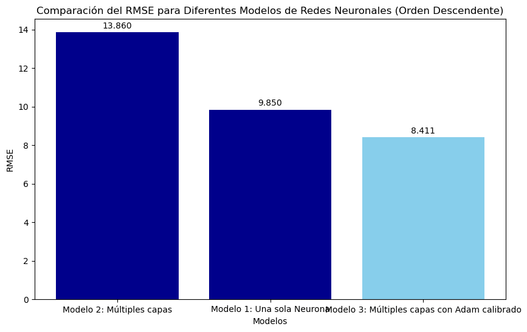

```python
model_names = ['Modelo 1: Una sola Neurona', 'Modelo 2: Múltiples capas', 'Modelo 3: Múltiples capas con Adam calibrado']
rmse_values = [9.85, 13.86, 8.411]
data = sorted(zip(model_names, rmse_values), key=lambda x: x[1], reverse=True)
sorted_model_names, sorted_rmse_values = zip(*data)
plt.figure(figsize=(10, 6))
plt.bar(sorted_model_names, sorted_rmse_values, color=['darkblue', 'darkblue', 'skyblue'])
plt.title('Comparación del RMSE para Diferentes Modelos de Redes Neuronales (Orden Descendente)')
plt.xlabel('Modelos')
plt.ylabel('RMSE')
for i, v in enumerate(sorted_rmse_values):
    plt.text(i, v + 0.2, f"{v:.3f}", ha='center', color='black')
plt.show()
```

Como podemos observar, inicialmente daba la impresión que el modelo de una sola neurona sería mejor que de múltiples capas, pero a lo largo de las calibraciones realizadas, empleando batchnormalization, técnica de dropout y búsqueda intensiva de parámetros óptimos que incluye el learning rate, se obtuvieron los siguientes resultados:

```
1. Modelo 1: Una sola Neurona / RMSE OBTENIDO: 9.85
2. Modelo 2: Múltiples capas / RMSE OBTENIDO: 13.86
3. Modelo 3: Múltiples capas Adam y calibración de hiperparámetros / RMSE OBTENIDO:  8.411
```

En ese sentido, el modelo 3 al tener el mejor RMSE, fue utilizado para generar las predicciones y así obtener el puntaje de 8.64070, con lo cual nuestro equipo se colocó en el ranking 5 de la competencia.

Ahora bien, respondiendo a la pregunta de interés... sí, es posible siendo que las variables indican que existiría una relación entre las características musicales de una canción y el año en que fue publicada/lanzada.